# Hooded Plover Demography

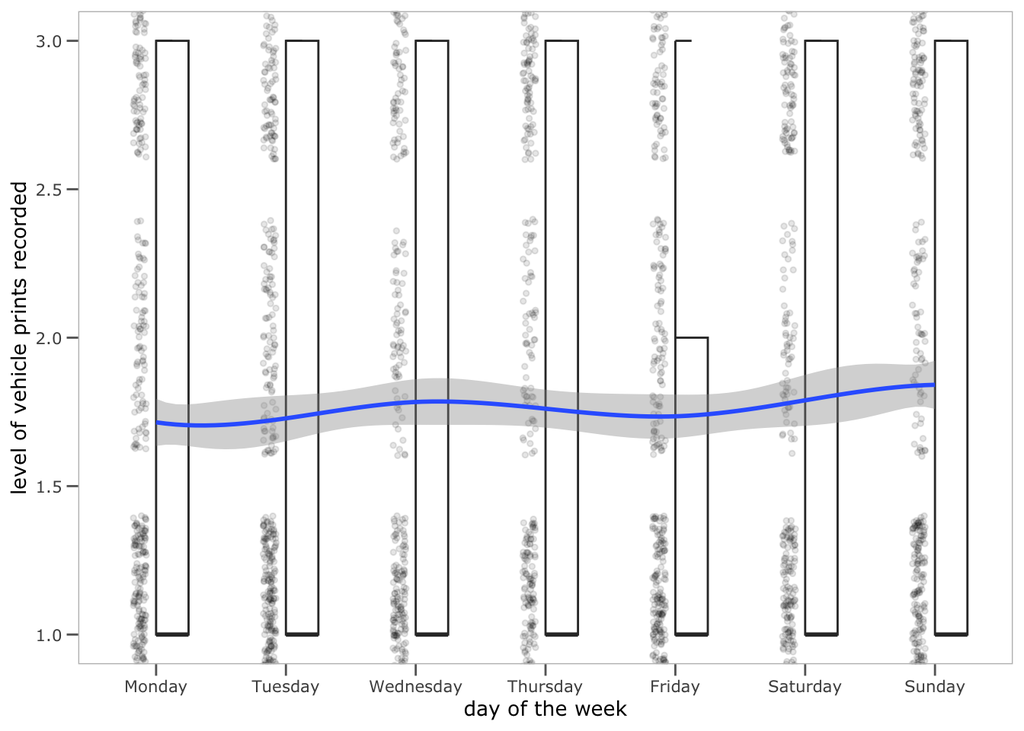

```r
# plot the weekly variation in the vehicle print detections
threat_data__ %>%
  ggplot() +
  gghalves::geom_half_point(aes(x = weekday, y = vehicle_pri),
      size = 1,
      width = 0.5,
      side = "l",
      range_scale = .4,
      alpha = 0.1
    ) +
    gghalves::geom_half_boxplot(aes(x = weekday, y = vehicle_pri),
      size = 0.5,
      width = 0.5,
      side = "r",
      alpha = 0.1, outlier.color = NA
    ) +
  geom_smooth(aes(x = as.numeric(weekday), y = vehicle_pri), method = lm, formula = y ~ splines::bs(x, 5)) +
  luke_theme +
  xlab("day of the week") +
  ylab("level of vehicle prints recorded")
```

Inspect the weekly variation in fox prints

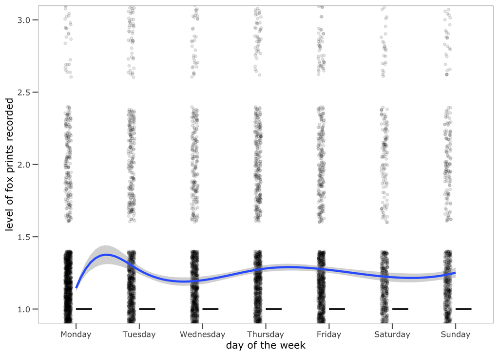

```r
# plot the weekly variation in the fox print detections
threat_data__ %>%
  ggplot() +
  gghalves::geom_half_point(aes(x = weekday, y = fox_pri),
      size = 1,
      width = 0.5,
      side = "l",
      range_scale = .4,
      alpha = 0.1
    ) +
    gghalves::geom_half_boxplot(aes(x = weekday, y = fox_pri),
      size = 0.5,
      width = 0.5,
      side = "r",
      alpha = 0.1, outlier.color = NA
    ) +
  geom_smooth(aes(x = as.numeric(weekday), y = fox_pri), method = lm, formula = y ~ splines::bs(x, 5)) +
  luke_theme +
  xlab("day of the week") +
  ylab("level of fox prints recorded")
```

check correlation between counts of the various threats

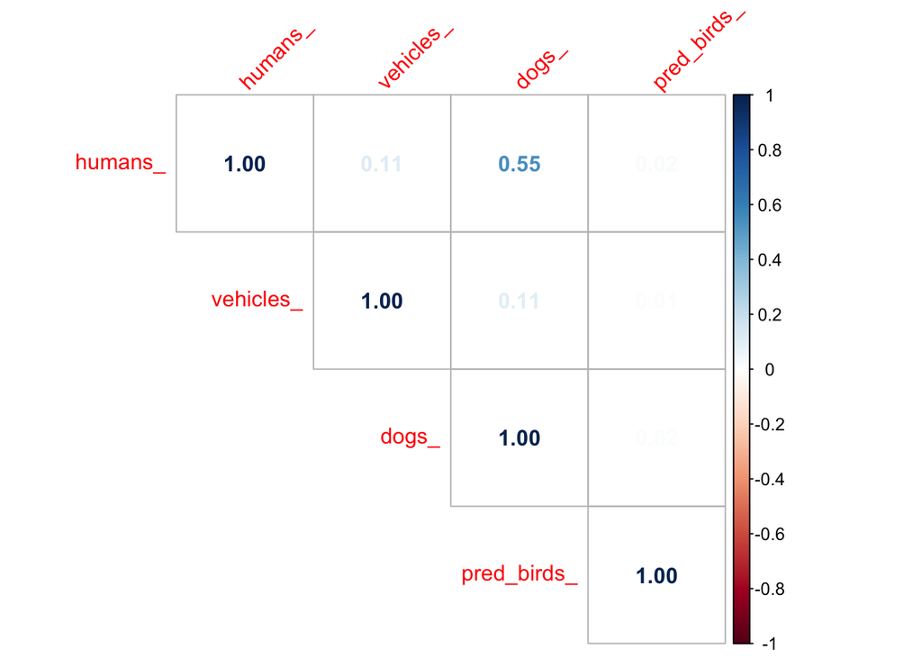

```r
# check correlation between humans counts
threat_data__ %>%
  dplyr::select(humans_, vehicles_, dogs_, pred_birds_) %>%
  na.omit() %>%
  cor() %>%
  corrplot(type = "upper", method = "number", tl.srt = 45)
```

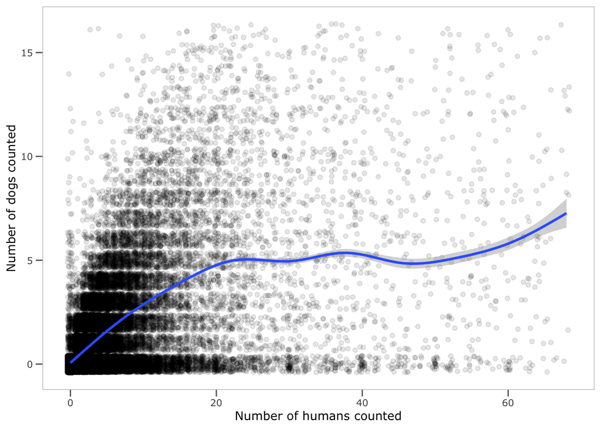

```r
# relationship between human counts and dog counts
threat_data__ %>%
  ggplot() +
  geom_jitter(aes(x = humans_, y = dogs_), alpha = 0.1) +
  geom_smooth(aes(x = humans_, y = dogs_)) +#, method = lm, formula = y ~ splines::bs(x, 2)) +
  luke_theme +
  xlab("Number of humans counted") +
  ylab("Number of dogs counted")
```

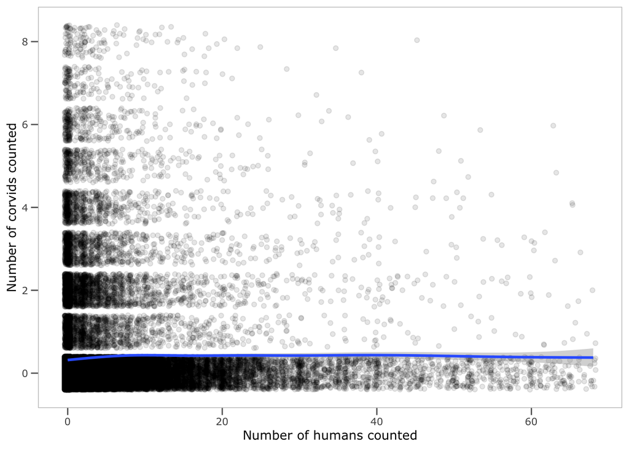

```r
# relationship between human counts and corvid counts
threat_data__ %>%
  ggplot() +
  geom_jitter(aes(x = humans_, y = pred_birds_), alpha = 0.1) +
  geom_smooth(aes(x = humans_, y = pred_birds_)) +#, method = lm) +
  luke_theme +
  xlab("Number of humans counted") +
  ylab("Number of corvids counted")
```

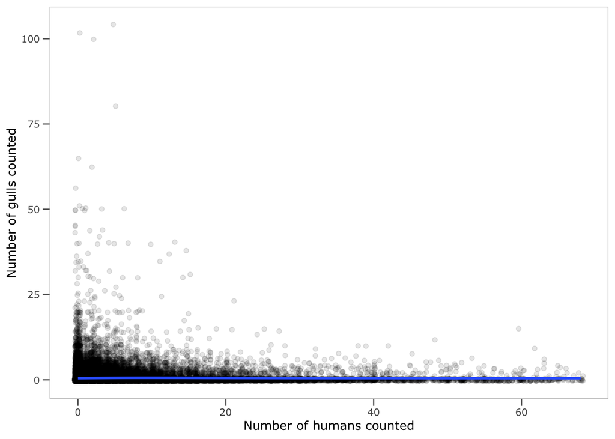

```r
# relationship between human counts and gull counts
threat_data__ %>%
  ggplot() +
  geom_jitter(aes(x = humans_, y = gulls_), alpha = 0.1) +
  geom_smooth(aes(x = humans_, y = gulls_)) +#, method = lm) +
  luke_theme +
  xlab("Number of humans counted") +
  ylab("Number of gulls counted")
```

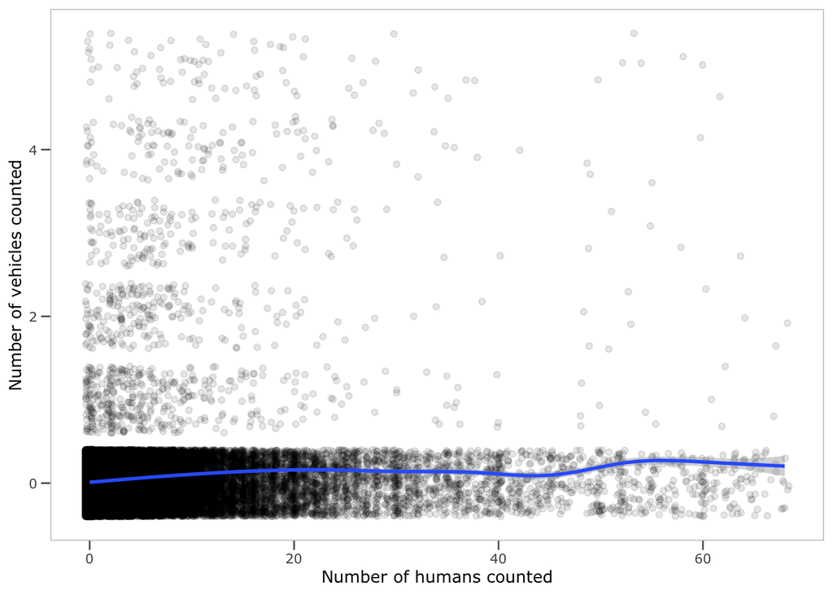

```r
# relationship between human counts and vehicle counts
threat_data__ %>%
  ggplot() +
  geom_jitter(aes(x = humans_, y = vehicles_), alpha = 0.1) +
  geom_smooth(aes(x = humans_, y = vehicles_)) + #, method = lm, formula = y ~ splines::bs(x, 2)) +
  luke_theme +
  xlab("Number of humans counted") +
  ylab("Number of vehicles counted")
```

```r
# determine which territories are in the threat data and the nest data
sites_intersect_FP <-
  inner_join(nest_data_FP, threat_data__ %>% filter(region == "FP"), by = c("season", "site"), relationship = "many-to-many") %>%
  dplyr::select(season, site) %>% distinct() %>%
  mutate(season_site = paste(season, site, sep = "_"))

sites_intersect_MP <-
  inner_join(nest_data_MP, threat_data__ %>% filter(region == "MP"), by = c("season", "site"), relationship = "many-to-many") %>%
  dplyr::select(season, site) %>% distinct() %>%
  mutate(season_site = paste(season, site, sep = "_"))

sites_intersect_BSC <-
  inner_join(nest_data_BSC, threat_data__ %>% filter(region == "BSC"), by = c("season", "site"), relationship = "many-to-many") %>%
  dplyr::select(season, site) %>% distinct() %>%
  mutate(season_site = paste(season, site, sep = "_"))
```

### determine which site names are not mutually recognized between the nest and the threat data

```r
# FP
# Combine and classify unique season_site values
sites_diff_FP <- full_join(nest_data_FP %>% ungroup() %>%
                             mutate(season_site = paste(season, site, sep = "_")) %>%
                             select(season_site) %>% distinct() %>% mutate(source = "nest_data_FP"),
                           threat_data__ %>% ungroup() %>% filter(region == "FP")  %>%
                             mutate(season_site = paste(season, site, sep = "_")) %>%
                             select(season_site) %>% distinct() %>% mutate(source = "threat_data_FP"),
                           by = "season_site")

# Find unique values in each dataframe
only_in_nest_data_FP <-
  sites_diff_FP %>%
  filter(is.na(source.y)) %>%
  select(season_site) %>%
  # separate(season_site, into = c("season", "site"), sep = "_", extra = "merge") %>%
  mutate(issue = "only in nest survival data")

only_in_threat_data_FP <-
  sites_diff_FP %>%
  filter(is.na(source.x)) %>%
  select(season_site) %>%
  # separate(season_site, into = c("season", "site"), sep = "_", extra = "merge") %>%
  mutate(issue = "only in threat data")

# fuzzy matching and data cleaning
clean_text <- function(x) {
  x %>%
    str_replace_all("[^a-zA-Z0-9 _]", "") %>%  # Remove special characters but keep letters, numbers, and spaces
    str_replace_all("\\s+", "_") %>%         # Replace spaces with underscores
    tolower()                                 # Convert to lowercase
}

# Perform fuzzy join
fuzzy_result_FP <-
  stringdist_full_join(
    nest_data_FP %>%
    ungroup() %>%
    mutate(season_site = paste(season, site, sep = "_")) %>%
    select(season_site) %>% distinct() %>% mutate(source = "nest_data_FP") %>%
    mutate(season_site_clean = clean_text(season_site)),
    threat_data__ %>%
    ungroup() %>%
    filter(region == "FP")  %>%
    mutate(season_site = paste(season, site, sep = "_")) %>%
    select(season_site) %>% distinct() %>% mutate(source = "threat_data_FP") %>%
    mutate(season_site_clean = clean_text(season_site)),
    by = "season_site_clean",
    method = "jw", # Jaro-Winkler distance
    max_dist = 0.2, # Adjust for optimal matching
    distance_col = "dist") %>%
  left_join(., only_in_nest_data_FP, by = c("season_site.x" = "season_site")) %>%
  left_join(., only_in_threat_data_FP, by = c("season_site.y" = "season_site")) %>%
  mutate(nest_season = str_extract(season_site.x, "^\\d{6}"),
         threat_season = str_extract(season_site.y, "^\\d{6}")) %>%
  filter(nest_season == threat_season) %>%
  group_by(season_site.x) %>%
  slice_min(order_by = dist) %>%  # Keep only the best fuzzy match per season
  ungroup() %>%
  mutate(site_nest_data = str_remove(season_site.x, "^\\d{6}_?"),
         site_threat_data = str_remove(season_site.y, "^\\d{6}_?")) %>%
  filter(issue.x == "only in nest survival data") %>%
  select(nest_season, site_nest_data, site_threat_data, dist) %>%
  arrange(desc(dist)) %>%
  rename(season = nest_season)

# Create a new workbook
sites_diff_FP_xl <- createWorkbook()

# Add each dataframe as a sheet
addWorksheet(sites_diff_FP_xl, "only_in_nest_data_FP")
writeData(sites_diff_FP_xl, "only_in_nest_data_FP", only_in_nest_data_FP)

addWorksheet(sites_diff_FP_xl, "only_in_threat_data_FP")
writeData(sites_diff_FP_xl, "only_in_threat_data_FP", only_in_threat_data_FP)

addWorksheet(sites_diff_FP_xl, "fuzzy_matches_to_consider")
writeData(sites_diff_FP_xl, "fuzzy_matches_to_consider", fuzzy_result_FP)

# Save the workbook
saveWorkbook(sites_diff_FP_xl, here("data/nest_issues_commented/site_names_issues_FP.xlsx"), overwrite = TRUE)

# MP
# Combine and classify unique season_site values
sites_diff_MP <- full_join(nest_data_MP %>% ungroup() %>%
                             mutate(season_site = paste(season, site, sep = "_")) %>%
                             select(season_site) %>% distinct() %>% mutate(source = "nest_data_MP"),
                           threat_data__ %>% ungroup() %>% filter(region == "MP")  %>%
                             mutate(season_site = paste(season, site, sep = "_")) %>%
                             select(season_site) %>% distinct() %>% mutate(source = "threat_data_MP"),
                           by = "season_site")

# Find unique values in each dataframe
only_in_nest_data_MP <-
  sites_diff_MP %>%
  filter(is.na(source.y)) %>%
  select(season_site) %>%
  # separate(season_site, into = c("season", "site"), sep = "_", extra = "merge") %>%
  mutate(issue = "only in nest survival data")

only_in_threat_data_MP <-
  sites_diff_MP %>%
  filter(is.na(source.x)) %>%
  select(season_site) %>%
  # separate(season_site, into = c("season", "site"), sep = "_", extra = "merge") %>%
  mutate(issue = "only in threat data")

# Perform fuzzy join
fuzzy_result_MP <-
  stringdist_full_join(
    nest_data_MP %>%
    ungroup() %>%
    mutate(season_site = paste(season, site, sep = "_")) %>%
    select(season_site) %>% distinct() %>% mutate(source = "nest_data_MP") %>%
    mutate(season_site_clean = clean_text(season_site)),
    threat_data__ %>%
    ungroup() %>%
    filter(region == "MP")  %>%
    mutate(season_site = paste(season, site, sep = "_")) %>%
    select(season_site) %>% distinct() %>% mutate(source = "threat_data_MP") %>%
    mutate(season_site_clean = clean_text(season_site)),
    by = "season_site_clean",
    method = "jw", # Jaro-Winkler distance
    max_dist = 0.2, # Adjust for optimal matching
    distance_col = "dist") %>%
  left_join(., only_in_nest_data_MP, by = c("season_site.x" = "season_site")) %>%
  left_join(., only_in_threat_data_MP, by = c("season_site.y" = "season_site")) %>%
  mutate(nest_season = str_extract(season_site.x, "^\\d{6}"),
         threat_season = str_extract(season_site.y, "^\\d{6}")) %>%
  filter(nest_season == threat_season) %>%
  group_by(season_site.x) %>%
  slice_min(order_by = dist) %>%  # Keep only the best fuzzy match per season
  ungroup() %>%
  mutate(site_nest_data = str_remove(season_site.x, "^\\d{6}_?"),
         site_threat_data = str_remove(season_site.y, "^\\d{6}_?")) %>%
  filter(issue.x == "only in nest survival data") %>%
  select(nest_season, site_nest_data, site_threat_data, dist) %>%
  arrange(desc(dist)) %>%
  rename(season = nest_season)

# Create a new workbook
sites_diff_MP_xl <- createWorkbook()

# Add each dataframe as a sheet
addWorksheet(sites_diff_MP_xl, "only_in_nest_data_MP")
writeData(sites_diff_MP_xl, "only_in_nest_data_MP", only_in_nest_data_MP)

addWorksheet(sites_diff_MP_xl, "only_in_threat_data_MP")
writeData(sites_diff_MP_xl, "only_in_threat_data_MP", only_in_threat_data_MP)

addWorksheet(sites_diff_MP_xl, "fuzzy_matches_to_consider")
writeData(sites_diff_MP_xl, "fuzzy_matches_to_consider", fuzzy_result_MP)

# Save the workbook
saveWorkbook(sites_diff_MP_xl, here("data/nest_issues_commented/site_names_issues_MP.xlsx"), overwrite = TRUE)

# BSC
# Combine and classify unique season_site values
sites_diff_BSC <- full_join(nest_data_BSC %>% ungroup() %>%
                             mutate(season_site = paste(season, site, sep = "_")) %>%
                             select(season_site) %>% distinct() %>% mutate(source = "nest_data_BSC"),
                           threat_data__ %>% ungroup() %>% filter(region == "BSC")  %>%
                             mutate(season_site = paste(season, site, sep = "_")) %>%
                             select(season_site) %>% distinct() %>% mutate(source = "threat_data_BSC"),
                           by = "season_site")

# Find unique values in each dataframe
only_in_nest_data_BSC <-
  sites_diff_BSC %>%
  filter(is.na(source.y)) %>%
  select(season_site) %>%
  # separate(season_site, into = c("season", "site"), sep = "_", extra = "merge") %>%
  mutate(issue = "only in nest survival data")

only_in_threat_data_BSC <-
  sites_diff_BSC %>%
  filter(is.na(source.x)) %>%
  select(season_site) %>%
  # separate(season_site, into = c("season", "site"), sep = "_", extra = "merge") %>%
  mutate(issue = "only in threat data")

# Perform fuzzy join
fuzzy_result_BSC <-
  stringdist_full_join(
    nest_data_BSC %>%
    ungroup() %>%
    mutate(season_site = paste(season, site, sep = "_")) %>%
    select(season_site) %>% distinct() %>% mutate(source = "nest_data_BSC") %>%
    mutate(season_site_clean = clean_text(season_site)),
    threat_data__ %>%
    ungroup() %>%
    filter(region == "BSC")  %>%
    mutate(season_site = paste(season, site, sep = "_")) %>%
    select(season_site) %>% distinct() %>% mutate(source = "threat_data_BSC") %>%
    mutate(season_site_clean = clean_text(season_site)),
    by = "season_site_clean",
    method = "jw", # Jaro-Winkler distance
    max_dist = 0.2, # Adjust for optimal matching
    distance_col = "dist") %>%
  left_join(., only_in_nest_data_BSC, by = c("season_site.x" = "season_site")) %>%
  left_join(., only_in_threat_data_BSC, by = c("season_site.y" = "season_site")) %>%
  mutate(nest_season = str_extract(season_site.x, "^\\d{6}"),
         threat_season = str_extract(season_site.y, "^\\d{6}")) %>%
  filter(nest_season == threat_season) %>%
  group_by(season_site.x) %>%
  slice_min(order_by = dist) %>%  # Keep only the best fuzzy match per season
  ungroup() %>%
  mutate(site_nest_data = str_remove(season_site.x, "^\\d{6}_?"),
         site_threat_data = str_remove(season_site.y, "^\\d{6}_?")) %>%
  filter(issue.x == "only in nest survival data") %>%
  select(nest_season, site_nest_data, site_threat_data, dist) %>%
  arrange(desc(dist)) %>%
  rename(season = nest_season)

# Create a new workbook
sites_diff_BSC_xl <- createWorkbook()

# Add each dataframe as a sheet
addWorksheet(sites_diff_BSC_xl, "only_in_nest_data_BSC")
writeData(sites_diff_BSC_xl, "only_in_nest_data_BSC", only_in_nest_data_BSC)

addWorksheet(sites_diff_BSC_xl, "only_in_threat_data_BSC")
writeData(sites_diff_BSC_xl, "only_in_threat_data_BSC", only_in_threat_data_BSC)

addWorksheet(sites_diff_BSC_xl, "fuzzy_matches_to_consider")
writeData(sites_diff_BSC_xl, "fuzzy_matches_to_consider", fuzzy_result_BSC)

# Save the workbook
saveWorkbook(sites_diff_BSC_xl, here("data/nest_issues_commented/site_names_issues_BSC.xlsx"), overwrite = TRUE)

nrow(fuzzy_result_BSC) + nrow(fuzzy_result_FP) + nrow(fuzzy_result_MP)
```

```
[1] 25
```

### Summarise Threat data and Merge to Nest Data

#### Fleurieu Peninsula: summarise threat data

```r
nest_data_FP_with_threat_data <-
  nest_data_FP %>%
  mutate(season_site = paste(season, site, sep = "_")) %>%
  filter(season_site %in% sites_intersect_FP$season_site) %>%
  dplyr::select(season, site, region, nest_ID,
                FirstFound, LastPresent, LastChecked,
                first_found2, last_alive2, last_checked2,
                management_status, management_level,
                nest_hab, Fate) %>%
  rename(status = management_status,
         level = management_level) %>%
  mutate(level = paste0("L", level)) %>%
  mutate(level = factor(level,
                        levels = c("L0", "L1",
                                   "L2", "L3",
                                   "L4"))) %>%
  ungroup() %>%
  mutate(
    hum_a = NA,
    veh_a = NA,
    dog_a = NA,
    don_a = NA,
    dof_a = NA,
    hof_a = NA,
    pbd_a = NA,
    gul_a = NA,
    hum_m = NA,
    veh_m = NA,
    dog_m = NA,
    don_m = NA,
    dof_m = NA,
    hof_m = NA,
    pbd_m = NA,
    gul_m = NA,
    hum_b = NA,
    veh_b = NA,
    dog_b = NA,
    don_b = NA,
    dof_b = NA,
    pbd_b = NA,
    gul_b = NA,
    hof_b = NA,
    hum_p = NA,
    veh_p = NA,
    dog_p = NA,
    hof_p = NA,
    fox_p = NA,
    n_surveys = NA,
    days_active = NA,
    fundays = NA,
    uncertain_days = NA,
    halfway = NA) %>%
  filter(FirstFound <= LastPresent & FirstFound <= LastChecked & LastPresent <= LastChecked) %>%
  filter(first_found2 <= last_alive2 & first_found2 <= last_checked2 & last_alive2 <= last_checked2)

FP_threat_data_subset <-
  threat_data__ %>%
  filter(region == "FP") %>%
  mutate(season_site = paste(season, site, sep = "_")) %>%
  filter(season_site %in% sites_intersect_FP$season_site) %>%
  ungroup()

for(i in 1:nrow(nest_data_FP_with_threat_data)){
  FirstFound <- nest_data_FP_with_threat_data$FirstFound[i]
  LastPresent <- nest_data_FP_with_threat_data$LastPresent[i]
  LastChecked <- nest_data_FP_with_threat_data$LastChecked[i]
  FirstFound2 <- nest_data_FP_with_threat_data$first_found2[i]
  LastPresent2 <- nest_data_FP_with_threat_data$last_alive2[i]
  LastChecked2 <- nest_data_FP_with_threat_data$last_checked2[i]
  halfway <- (LastChecked - LastPresent)/2
  days_active <- (LastPresent + halfway) - FirstFound
  uncertain_days <- LastChecked - LastPresent
  site_ <- as.character(nest_data_FP_with_threat_data$site[i])
  season_ <- as.character(nest_data_FP_with_threat_data$season[i])

  fundays_df <-
    data.frame(date = seq(from = LastPresent2, to = LastChecked2, 1)) %>%
    # mutate(weekday = weekdays(dates)) %>%
    mutate(weekday = factor(as.factor(weekdays(date)),
                            levels = c("Monday", "Tuesday", "Wednesday",
                                       "Thursday", "Friday", "Saturday",
                                       "Sunday")),
           region = "FP") %>%
    mutate(year = year(date)) %>%
    mutate(season = ifelse(month(date) < 6, year - 1, year)) %>%
    mutate(season = ifelse(month(date) >= 6,
                           paste0(year, substr(year + 1, 3, 4)),
                           paste0(season, substr(year, 3, 4)))) %>%
    left_join(., holidays, by = c("region", "season"), relationship = "many-to-many") %>%
    mutate(holiday = ifelse(date >= start_date & date <= end_date, 1, 0)) %>%
    group_by(region, season, date) %>%
    mutate(holiday = max(holiday, na.rm = TRUE)) %>%
    dplyr::select(-c(event, start_date, end_date)) %>%
    distinct() %>%
    ungroup() %>%
    mutate(day_type = ifelse(holiday == 1 | weekday %in%
                               c("Saturday", "Sunday"), "funday", "workday")) %>%
    mutate(funday = ifelse(day_type == "funday", 1, 0))

  FP_threat_data_subset_ <-
    FP_threat_data_subset %>%
    ungroup() %>%
    # data.frame() %>%
    # dplyr::filter(as.numeric(obs_date2) >= FirstFound & as.numeric(obs_date2) <= (LastPresent + halfway) & season == season_) %>%
    # dplyr::filter(as.numeric(obs_date2) >= LastPresent & as.numeric(obs_date2) <= (LastPresent + halfway) & season == season_) %>%
    dplyr::filter(as.numeric(obs_date2) >= LastPresent & as.numeric(obs_date2) <= (LastPresent + (LastChecked - LastPresent)) & season == season_) %>%
    dplyr::filter(site == site_)

  if(nrow(FP_threat_data_subset_) > 0){
    avgeraged_threats <-
      FP_threat_data_subset_ %>%
      mutate(hum_bi = ifelse(humans > 0 | (!is.na(hum_pri)), 1, 0),
             vehicle_bi = ifelse(vehicles > 0 | (!is.na(vehicle_pri)), 1, 0),
             dogs_bi = ifelse(dogs > 0 | (!is.na(dog_pri)), 1, 0),
             dogs_off_bi = ifelse(dogs_off > 0, 1, 0),
             dogs_on_bi = ifelse(dogs_on > 0, 1, 0),
             p_birds_bi = ifelse(pred_birds > 0, 1, 0),
             gulls_bi = ifelse(gulls > 0, 1, 0),
             hoof_bi = ifelse(hoofed_animals > 0 | (!is.na(hoofed_pri)), 1, 0)) %>%
      dplyr::summarise(
        # fundays = sum(funday),
        hum_avg = mean(humans, na.rm = TRUE),
        vehicles_avg = mean(vehicles, na.rm = TRUE),
        dogs_avg = mean(dogs, na.rm = TRUE),
        dogs_on_avg = mean(dogs_on, na.rm = TRUE),
        dogs_off_avg = mean(dogs_off, na.rm = TRUE),
        hoof_avg = mean(hoofed_animals, na.rm = TRUE),
        p_birds_avg = mean(pred_birds, na.rm = TRUE),
        gulls_avg = mean(gulls, na.rm = TRUE),
        hum_max = max(humans, na.rm = TRUE),
        vehicles_max = max(vehicles, na.rm = TRUE),
        dogs_max = max(dogs, na.rm = TRUE),
        dogs_on_max = max(dogs_on, na.rm = TRUE),
        dogs_off_max = max(dogs_off, na.rm = TRUE),
        hoof_max = max(hoofed_animals, na.rm = TRUE),
        p_birds_max = max(pred_birds, na.rm = TRUE),
        gulls_max = max(gulls, na.rm = TRUE),
        hum_bi = max(hum_bi, na.rm = TRUE),
        vehicle_bi = max(vehicle_bi, na.rm = TRUE),
        dogs_bi = max(dogs_bi, na.rm = TRUE),
        dogs_on_bi = max(dogs_on_bi, na.rm = TRUE),
        dogs_off_bi = max(dogs_off_bi, na.rm = TRUE),
        p_birds_bi = max(p_birds_bi, na.rm = TRUE),
        gulls_bi = max(gulls_bi, na.rm = TRUE),
        hoof_bi = max(hoof_bi, na.rm = TRUE),
        hum_pr = max(hum_pri, na.rm = TRUE),
        vehicle_pr = max(vehicle_pri, na.rm = TRUE),
        dog_pr = max(dog_pri, na.rm = TRUE),
        hoof_pr = max(hoofed_pri, na.rm = TRUE),
        fox_pr = max(fox_pri, na.rm = TRUE),
        n_surveys = n(),
        days_active = days_active,
        halfway = halfway,
        uncertain_days = uncertain_days)

    nest_data_FP_with_threat_data$fundays[i] <- sum(fundays_df$funday)
    nest_data_FP_with_threat_data$hum_a[i] <- avgeraged_threats$hum_avg
    nest_data_FP_with_threat_data$veh_a[i] <- avgeraged_threats$vehicles_avg
    nest_data_FP_with_threat_data$dog_a[i] <- avgeraged_threats$dogs_avg
    nest_data_FP_with_threat_data$don_a[i] <- avgeraged_threats$dogs_on_avg
    nest_data_FP_with_threat_data$dof_a[i] <- avgeraged_threats$dogs_off_avg
    nest_data_FP_with_threat_data$hof_a[i] <- avgeraged_threats$hoof_avg
    nest_data_FP_with_threat_data$pbd_a[i] <- avgeraged_threats$p_birds_avg
    nest_data_FP_with_threat_data$gul_a[i] <- avgeraged_threats$gulls_avg

    nest_data_FP_with_threat_data$hum_m[i] <- avgeraged_threats$hum_max
    nest_data_FP_with_threat_data$veh_m[i] <- avgeraged_threats$vehicles_max
    nest_data_FP_with_threat_data$dog_m[i] <- avgeraged_threats$dogs_max
    nest_data_FP_with_threat_data$don_m[i] <- avgeraged_threats$dogs_on_max
    nest_data_FP_with_threat_data$dof_m[i] <- avgeraged_threats$dogs_off_max
    nest_data_FP_with_threat_data$hof_m[i] <- avgeraged_threats$hoof_max
    nest_data_FP_with_threat_data$pbd_m[i] <- avgeraged_threats$p_birds_max
    nest_data_FP_with_threat_data$gul_m[i] <- avgeraged_threats$gulls_max

    nest_data_FP_with_threat_data$hum_b[i] <- avgeraged_threats$hum_bi
    nest_data_FP_with_threat_data$veh_b[i] <- avgeraged_threats$vehicle_bi
    nest_data_FP_with_threat_data$dog_b[i] <- avgeraged_threats$dogs_bi
    nest_data_FP_with_threat_data$don_b[i] <- avgeraged_threats$dogs_on_bi
    nest_data_FP_with_threat_data$dof_b[i] <- avgeraged_threats$dogs_off_bi
    nest_data_FP_with_threat_data$pbd_b[i] <- avgeraged_threats$p_birds_bi
    nest_data_FP_with_threat_data$hof_b[i] <- avgeraged_threats$hoof_bi
    nest_data_FP_with_threat_data$gul_b[i] <- avgeraged_threats$gulls_bi

    nest_data_FP_with_threat_data$hum_p[i] <- avgeraged_threats$hum_pr
    nest_data_FP_with_threat_data$veh_p[i] <- avgeraged_threats$vehicle_pr
    nest_data_FP_with_threat_data$dog_p[i] <- avgeraged_threats$dog_pr
    nest_data_FP_with_threat_data$hof_p[i] <- avgeraged_threats$hoof_pr
    nest_data_FP_with_threat_data$fox_p[i] <- avgeraged_threats$fox_pr

    nest_data_FP_with_threat_data$n_surveys[i] <- avgeraged_threats$n_surveys
    nest_data_FP_with_threat_data$days_active[i] <- avgeraged_threats$days_active
    nest_data_FP_with_threat_data$halfway[i] <- avgeraged_threats$halfway
    nest_data_FP_with_threat_data$uncertain_days[i] <- avgeraged_threats$uncertain_days


  }else{
    nest_data_FP_with_threat_data$hum_a[i] <- NA
    nest_data_FP_with_threat_data$veh_a[i] <- NA
    nest_data_FP_with_threat_data$dog_a[i] <- NA
    nest_data_FP_with_threat_data$don_a[i] <- NA
    nest_data_FP_with_threat_data$dof_a[i] <- NA
    nest_data_FP_with_threat_data$hof_a[i] <- NA
    nest_data_FP_with_threat_data$pbd_a[i] <- NA
    nest_data_FP_with_threat_data$gul_a[i] <- NA
    nest_data_FP_with_threat_data$hum_m[i] <- NA
    nest_data_FP_with_threat_data$veh_m[i] <- NA
    nest_data_FP_with_threat_data$dog_m[i] <- NA
    nest_data_FP_with_threat_data$don_m[i] <- NA
    nest_data_FP_with_threat_data$dof_m[i] <- NA
    nest_data_FP_with_threat_data$hof_m[i] <- NA
    nest_data_FP_with_threat_data$pbd_m[i] <- NA
    nest_data_FP_with_threat_data$gul_m[i] <- NA
    nest_data_FP_with_threat_data$hum_b[i] <- NA
    nest_data_FP_with_threat_data$veh_b[i] <- NA
    nest_data_FP_with_threat_data$dog_b[i] <- NA
    nest_data_FP_with_threat_data$don_b[i] <- NA
    nest_data_FP_with_threat_data$dof_b[i] <- NA
    nest_data_FP_with_threat_data$pbd_b[i] <- NA
    nest_data_FP_with_threat_data$gul_b[i] <- NA
    nest_data_FP_with_threat_data$hof_b[i] <- NA
    nest_data_FP_with_threat_data$hum_p[i] <- NA
    nest_data_FP_with_threat_data$veh_p[i] <- NA
    nest_data_FP_with_threat_data$dog_p[i] <- NA
    nest_data_FP_with_threat_data$hof_p[i] <- NA
    nest_data_FP_with_threat_data$fox_p[i] <- NA
    nest_data_FP_with_threat_data$n_surveys[i] <- 0
    nest_data_FP_with_threat_data$days_active[i] <- days_active
    nest_data_FP_with_threat_data$halfway[i] <- halfway
    nest_data_FP_with_threat_data$uncertain_days[i] <- uncertain_days
    nest_data_FP_with_threat_data$fundays[i] <- NA
  }
}
saveRDS(nest_data_FP_with_threat_data, file = "output/nest_data_FP_with_threat_data.rds")
```

#### Mornington Peninsula: summarise threat data

```r
nest_data_MP_with_threat_data <-
  nest_data_MP %>%
  mutate(season_site = paste(season, site, sep = "_")) %>%
  filter(season_site %in% sites_intersect_MP$season_site) %>%
  dplyr::select(season, site, region, nest_ID,
                FirstFound, LastPresent, LastChecked,
                first_found2, last_alive2, last_checked2,
                management_status, management_level,
                nest_hab, Fate) %>%
  rename(status = management_status,
         level = management_level) %>%
  mutate(level = paste0("L", level)) %>%
  mutate(level = factor(level,
                        levels = c("L0", "L1",
                                   "L2", "L3",
                                   "L4"))) %>%
  ungroup() %>%
  mutate(
    hum_a = NA,
    veh_a = NA,
    dog_a = NA,
    don_a = NA,
    dof_a = NA,
    hof_a = NA,
    pbd_a = NA,
    gul_a = NA,
    hum_m = NA,
    veh_m = NA,
    dog_m = NA,
    don_m = NA,
    dof_m = NA,
    hof_m = NA,
    pbd_m = NA,
    gul_m = NA,
    hum_b = NA,
    veh_b = NA,
    dog_b = NA,
    don_b = NA,
    dof_b = NA,
    pbd_b = NA,
    gul_b = NA,
    hof_b = NA,
    hum_p = NA,
    veh_p = NA,
    dog_p = NA,
    hof_p = NA,
    fox_p = NA,
    n_surveys = NA,
    days_active = NA,
    fundays = NA,
    uncertain_days = NA,
    halfway = NA) %>%
  filter(FirstFound <= LastPresent & FirstFound <= LastChecked & LastPresent <= LastChecked) %>%
  filter(first_found2 <= last_alive2 & first_found2 <= last_checked2 & last_alive2 <= last_checked2)

MP_threat_data_subset <-
  threat_data__ %>%
  filter(region == "MP") %>%
  mutate(season_site = paste(season, site, sep = "_")) %>%
  filter(season_site %in% sites_intersect_MP$season_site) %>%
  ungroup()

for(i in 1:nrow(nest_data_MP_with_threat_data)){
  FirstFound <- nest_data_MP_with_threat_data$FirstFound[i]
  LastPresent <- nest_data_MP_with_threat_data$LastPresent[i]
  LastChecked <- nest_data_MP_with_threat_data$LastChecked[i]
  FirstFound2 <- nest_data_MP_with_threat_data$first_found2[i]
  LastPresent2 <- nest_data_MP_with_threat_data$last_alive2[i]
  LastChecked2 <- nest_data_MP_with_threat_data$last_checked2[i]
  halfway <- (LastChecked - LastPresent)/2
  days_active <- (LastPresent + halfway) - FirstFound
  uncertain_days <- LastChecked - LastPresent
  site_ <- as.character(nest_data_MP_with_threat_data$site[i])
  season_ <- as.character(nest_data_MP_with_threat_data$season[i])

  fundays_df <-
    data.frame(date = seq(from = LastPresent2, to = LastChecked2, 1)) %>%
    # mutate(weekday = weekdays(dates)) %>%
    mutate(weekday = factor(as.factor(weekdays(date)),
                            levels = c("Monday", "Tuesday", "Wednesday",
                                       "Thursday", "Friday", "Saturday",
                                       "Sunday")),
           region = "MP") %>%
    mutate(year = year(date)) %>%
    mutate(season = ifelse(month(date) < 6, year - 1, year)) %>%
    mutate(season = ifelse(month(date) >= 6,
                           paste0(year, substr(year + 1, 3, 4)),
                           paste0(season, substr(year, 3, 4)))) %>%
    left_join(., holidays, by = c("region", "season"), relationship = "many-to-many") %>%
    mutate(holiday = ifelse(date >= start_date & date <= end_date, 1, 0)) %>%
    group_by(region, season, date) %>%
    mutate(holiday = max(holiday, na.rm = TRUE)) %>%
    dplyr::select(-c(event, start_date, end_date)) %>%
    distinct() %>%
    ungroup() %>%
    mutate(day_type = ifelse(holiday == 1 | weekday %in%
                               c("Saturday", "Sunday"), "funday", "workday")) %>%
    mutate(funday = ifelse(day_type == "funday", 1, 0))

  MP_threat_data_subset_ <-
    MP_threat_data_subset %>%
    ungroup() %>%
    # data.frame() %>%
    # dplyr::filter(as.numeric(obs_date2) >= FirstFound & as.numeric(obs_date2) <= (LastPresent + halfway) & season == season_) %>%
    # dplyr::filter(as.numeric(obs_date2) >= LastPresent & as.numeric(obs_date2) <= (LastPresent + halfway) & season == season_) %>%
    dplyr::filter(as.numeric(obs_date2) >= LastPresent & as.numeric(obs_date2) <= (LastPresent + (LastChecked - LastPresent)) & season == season_) %>%
    dplyr::filter(site == site_)

  if(nrow(MP_threat_data_subset_) > 0){
    avgeraged_threats <-
      MP_threat_data_subset_ %>%
      mutate(hum_bi = ifelse(humans > 0 | (!is.na(hum_pri)), 1, 0),
             vehicle_bi = ifelse(vehicles > 0 | (!is.na(vehicle_pri)), 1, 0),
             dogs_bi = ifelse(dogs > 0 | (!is.na(dog_pri)), 1, 0),
             dogs_off_bi = ifelse(dogs_off > 0, 1, 0),
             dogs_on_bi = ifelse(dogs_on > 0, 1, 0),
             p_birds_bi = ifelse(pred_birds > 0, 1, 0),
             gulls_bi = ifelse(gulls > 0, 1, 0),
             hoof_bi = ifelse(hoofed_animals > 0 | (!is.na(hoofed_pri)), 1, 0)) %>%
      dplyr::summarise(
        # fundays = sum(funday),
        hum_avg = mean(humans, na.rm = TRUE),
        vehicles_avg = mean(vehicles, na.rm = TRUE),
        dogs_avg = mean(dogs, na.rm = TRUE),
        dogs_on_avg = mean(dogs_on, na.rm = TRUE),
        dogs_off_avg = mean(dogs_off, na.rm = TRUE),
        hoof_avg = mean(hoofed_animals, na.rm = TRUE),
        p_birds_avg = mean(pred_birds, na.rm = TRUE),
        gulls_avg = mean(gulls, na.rm = TRUE),
        hum_max = max(humans, na.rm = TRUE),
        vehicles_max = max(vehicles, na.rm = TRUE),
        dogs_max = max(dogs, na.rm = TRUE),
        dogs_on_max = max(dogs_on, na.rm = TRUE),
        dogs_off_max = max(dogs_off, na.rm = TRUE),
        hoof_max = max(hoofed_animals, na.rm = TRUE),
        p_birds_max = max(pred_birds, na.rm = TRUE),
        gulls_max = max(gulls, na.rm = TRUE),
        hum_bi = max(hum_bi, na.rm = TRUE),
        vehicle_bi = max(vehicle_bi, na.rm = TRUE),
        dogs_bi = max(dogs_bi, na.rm = TRUE),
        dogs_on_bi = max(dogs_on_bi, na.rm = TRUE),
        dogs_off_bi = max(dogs_off_bi, na.rm = TRUE),
        p_birds_bi = max(p_birds_bi, na.rm = TRUE),
        gulls_bi = max(gulls_bi, na.rm = TRUE),
        hoof_bi = max(hoof_bi, na.rm = TRUE),
        hum_pr = max(hum_pri, na.rm = TRUE),
        vehicle_pr = max(vehicle_pri, na.rm = TRUE),
        dog_pr = max(dog_pri, na.rm = TRUE),
        hoof_pr = max(hoofed_pri, na.rm = TRUE),
        fox_pr = max(fox_pri, na.rm = TRUE),
        n_surveys = n(),
        days_active = days_active,
        halfway = halfway,
        uncertain_days = uncertain_days)

    nest_data_MP_with_threat_data$fundays[i] <- sum(fundays_df$funday)
    nest_data_MP_with_threat_data$hum_a[i] <- avgeraged_threats$hum_avg
    nest_data_MP_with_threat_data$veh_a[i] <- avgeraged_threats$vehicles_avg
    nest_data_MP_with_threat_data$dog_a[i] <- avgeraged_threats$dogs_avg
    nest_data_MP_with_threat_data$don_a[i] <- avgeraged_threats$dogs_on_avg
    nest_data_MP_with_threat_data$dof_a[i] <- avgeraged_threats$dogs_off_avg
    nest_data_MP_with_threat_data$hof_a[i] <- avgeraged_threats$hoof_avg
    nest_data_MP_with_threat_data$pbd_a[i] <- avgeraged_threats$p_birds_avg
    nest_data_MP_with_threat_data$gul_a[i] <- avgeraged_threats$gulls_avg

    nest_data_MP_with_threat_data$hum_m[i] <- avgeraged_threats$hum_max
    nest_data_MP_with_threat_data$veh_m[i] <- avgeraged_threats$vehicles_max
    nest_data_MP_with_threat_data$dog_m[i] <- avgeraged_threats$dogs_max
    nest_data_MP_with_threat_data$don_m[i] <- avgeraged_threats$dogs_on_max
    nest_data_MP_with_threat_data$dof_m[i] <- avgeraged_threats$dogs_off_max
    nest_data_MP_with_threat_data$hof_m[i] <- avgeraged_threats$hoof_max
    nest_data_MP_with_threat_data$pbd_m[i] <- avgeraged_threats$p_birds_max
    nest_data_MP_with_threat_data$gul_m[i] <- avgeraged_threats$gulls_max

    nest_data_MP_with_threat_data$hum_b[i] <- avgeraged_threats$hum_bi
    nest_data_MP_with_threat_data$veh_b[i] <- avgeraged_threats$vehicle_bi
    nest_data_MP_with_threat_data$dog_b[i] <- avgeraged_threats$dogs_bi
    nest_data_MP_with_threat_data$don_b[i] <- avgeraged_threats$dogs_on_bi
    nest_data_MP_with_threat_data$dof_b[i] <- avgeraged_threats$dogs_off_bi
    nest_data_MP_with_threat_data$pbd_b[i] <- avgeraged_threats$p_birds_bi
    nest_data_MP_with_threat_data$hof_b[i] <- avgeraged_threats$hoof_bi
    nest_data_MP_with_threat_data$gul_b[i] <- avgeraged_threats$gulls_bi

    nest_data_MP_with_threat_data$hum_p[i] <- avgeraged_threats$hum_pr
    nest_data_MP_with_threat_data$veh_p[i] <- avgeraged_threats$vehicle_pr
    nest_data_MP_with_threat_data$dog_p[i] <- avgeraged_threats$dog_pr
    nest_data_MP_with_threat_data$hof_p[i] <- avgeraged_threats$hoof_pr
    nest_data_MP_with_threat_data$fox_p[i] <- avgeraged_threats$fox_pr

    nest_data_MP_with_threat_data$n_surveys[i] <- avgeraged_threats$n_surveys
    nest_data_MP_with_threat_data$days_active[i] <- avgeraged_threats$days_active
    nest_data_MP_with_threat_data$halfway[i] <- avgeraged_threats$halfway
    nest_data_MP_with_threat_data$uncertain_days[i] <- avgeraged_threats$uncertain_days


  }else{
    nest_data_MP_with_threat_data$hum_a[i] <- NA
    nest_data_MP_with_threat_data$veh_a[i] <- NA
    nest_data_MP_with_threat_data$dog_a[i] <- NA
    nest_data_MP_with_threat_data$don_a[i] <- NA
    nest_data_MP_with_threat_data$dof_a[i] <- NA
    nest_data_MP_with_threat_data$hof_a[i] <- NA
    nest_data_MP_with_threat_data$pbd_a[i] <- NA
    nest_data_MP_with_threat_data$gul_a[i] <- NA
    nest_data_MP_with_threat_data$hum_m[i] <- NA
    nest_data_MP_with_threat_data$veh_m[i] <- NA
    nest_data_MP_with_threat_data$dog_m[i] <- NA
    nest_data_MP_with_threat_data$don_m[i] <- NA
    nest_data_MP_with_threat_data$dof_m[i] <- NA
    nest_data_MP_with_threat_data$hof_m[i] <- NA
    nest_data_MP_with_threat_data$pbd_m[i] <- NA
    nest_data_MP_with_threat_data$gul_m[i] <- NA
    nest_data_MP_with_threat_data$hum_b[i] <- NA
    nest_data_MP_with_threat_data$veh_b[i] <- NA
    nest_data_MP_with_threat_data$dog_b[i] <- NA
    nest_data_MP_with_threat_data$don_b[i] <- NA
    nest_data_MP_with_threat_data$dof_b[i] <- NA
    nest_data_MP_with_threat_data$pbd_b[i] <- NA
    nest_data_MP_with_threat_data$gul_b[i] <- NA
    nest_data_MP_with_threat_data$hof_b[i] <- NA
    nest_data_MP_with_threat_data$hum_p[i] <- NA
    nest_data_MP_with_threat_data$veh_p[i] <- NA
    nest_data_MP_with_threat_data$dog_p[i] <- NA
    nest_data_MP_with_threat_data$hof_p[i] <- NA
    nest_data_MP_with_threat_data$fox_p[i] <- NA
    nest_data_MP_with_threat_data$n_surveys[i] <- 0
    nest_data_MP_with_threat_data$days_active[i] <- days_active
    nest_data_MP_with_threat_data$halfway[i] <- halfway
    nest_data_MP_with_threat_data$uncertain_days[i] <- uncertain_days
    nest_data_MP_with_threat_data$fundays[i] <- NA
  }
}
saveRDS(nest_data_MP_with_threat_data, file = "output/nest_data_MP_with_threat_data.rds")
```

#### Bellarine / Surf Coast: summarise threat data

```r
nest_data_BSC_with_threat_data <-
  nest_data_BSC %>%
  mutate(season_site = paste(season, site, sep = "_")) %>%
  ####

  ####
  filter(season_site %in% sites_intersect_BSC$season_site) %>%
  dplyr::select(season, site, region, nest_ID,
                FirstFound, LastPresent, LastChecked,
                first_found2, last_alive2, last_checked2,
                management_status, management_level,
                nest_hab, Fate) %>%
  rename(status = management_status,
         level = management_level) %>%
  mutate(level = paste0("L", level)) %>%
  mutate(level = factor(level,
                        levels = c("L0", "L1",
                                   "L2", "L3",
                                   "L4"))) %>%
  ungroup() %>%
  mutate(
    hum_a = NA,
    veh_a = NA,
    dog_a = NA,
    don_a = NA,
    dof_a = NA,
    hof_a = NA,
    pbd_a = NA,
    gul_a = NA,
    hum_m = NA,
    veh_m = NA,
    dog_m = NA,
    don_m = NA,
    dof_m = NA,
    hof_m = NA,
    pbd_m = NA,
    gul_m = NA,
    hum_b = NA,
    veh_b = NA,
    dog_b = NA,
    don_b = NA,
    dof_b = NA,
    pbd_b = NA,
    gul_b = NA,
    hof_b = NA,
    hum_p = NA,
    veh_p = NA,
    dog_p = NA,
    hof_p = NA,
    fox_p = NA,
    n_surveys = NA,
    days_active = NA,
    fundays = NA,
    uncertain_days = NA,
    halfway = NA) %>%
  filter(FirstFound <= LastPresent & FirstFound <= LastChecked & LastPresent <= LastChecked) %>%
  filter(first_found2 <= last_alive2 & first_found2 <= last_checked2 & last_alive2 <= last_checked2)

BSC_threat_data_subset <-
  threat_data__ %>%
  filter(region == "BSC") %>%
  mutate(season_site = paste(season, site, sep = "_")) %>%
  filter(season_site %in% sites_intersect_BSC$season_site) %>%
  ungroup()

for(i in 1:nrow(nest_data_BSC_with_threat_data)){
  FirstFound <- nest_data_BSC_with_threat_data$FirstFound[i]
  LastPresent <- nest_data_BSC_with_threat_data$LastPresent[i]
  LastChecked <- nest_data_BSC_with_threat_data$LastChecked[i]
  FirstFound2 <- nest_data_BSC_with_threat_data$first_found2[i]
  LastPresent2 <- nest_data_BSC_with_threat_data$last_alive2[i]
  LastChecked2 <- nest_data_BSC_with_threat_data$last_checked2[i]
  halfway <- (LastChecked - LastPresent)/2
  days_active <- (LastPresent + halfway) - FirstFound
  uncertain_days <- LastChecked - LastPresent
  site_ <- as.character(nest_data_BSC_with_threat_data$site[i])
  season_ <- as.character(nest_data_BSC_with_threat_data$season[i])

  fundays_df <-
    data.frame(date = seq(from = LastPresent2, to = LastChecked2, 1)) %>%
    # mutate(weekday = weekdays(dates)) %>%
    mutate(weekday = factor(as.factor(weekdays(date)),
                            levels = c("Monday", "Tuesday", "Wednesday",
                                       "Thursday", "Friday", "Saturday",
                                       "Sunday")),
           region = "BSC") %>%
    mutate(year = year(date)) %>%
    mutate(season = ifelse(month(date) < 6, year - 1, year)) %>%
    mutate(season = ifelse(month(date) >= 6,
                           paste0(year, substr(year + 1, 3, 4)),
                           paste0(season, substr(year, 3, 4)))) %>%
    left_join(., holidays, by = c("region", "season"), relationship = "many-to-many") %>%
    mutate(holiday = ifelse(date >= start_date & date <= end_date, 1, 0)) %>%
    group_by(region, season, date) %>%
    mutate(holiday = max(holiday, na.rm = TRUE)) %>%
    dplyr::select(-c(event, start_date, end_date)) %>%
    distinct() %>%
    ungroup() %>%
    mutate(day_type = ifelse(holiday == 1 | weekday %in%
                               c("Saturday", "Sunday"), "funday", "workday")) %>%
    mutate(funday = ifelse(day_type == "funday", 1, 0))

  BSC_threat_data_subset_ <-
    BSC_threat_data_subset %>%
    ungroup() %>%
    # data.frame() %>%
    # dplyr::filter(as.numeric(obs_date2) >= FirstFound & as.numeric(obs_date2) <= (LastPresent + halfway) & season == season_) %>%
    # dplyr::filter(as.numeric(obs_date2) >= LastPresent & as.numeric(obs_date2) <= (LastPresent + halfway) & season == season_) %>%
    dplyr::filter(as.numeric(obs_date2) >= LastPresent & as.numeric(obs_date2) <= (LastPresent + (LastChecked - LastPresent)) & season == season_) %>%
    dplyr::filter(site == site_)

  if(nrow(BSC_threat_data_subset_) > 0){
    avgeraged_threats <-
      BSC_threat_data_subset_ %>%
      mutate(hum_bi = ifelse(humans > 0 | (!is.na(hum_pri)), 1, 0),
             vehicle_bi = ifelse(vehicles > 0 | (!is.na(vehicle_pri)), 1, 0),
             dogs_bi = ifelse(dogs > 0 | (!is.na(dog_pri)), 1, 0),
             dogs_off_bi = ifelse(dogs_off > 0, 1, 0),
             dogs_on_bi = ifelse(dogs_on > 0, 1, 0),
             p_birds_bi = ifelse(pred_birds > 0, 1, 0),
             gulls_bi = ifelse(gulls > 0, 1, 0),
             hoof_bi = ifelse(hoofed_animals > 0 | (!is.na(hoofed_pri)), 1, 0)) %>%
      dplyr::summarise(
        # fundays = sum(funday),
        hum_avg = mean(humans, na.rm = TRUE),
        vehicles_avg = mean(vehicles, na.rm = TRUE),
        dogs_avg = mean(dogs, na.rm = TRUE),
        dogs_on_avg = mean(dogs_on, na.rm = TRUE),
        dogs_off_avg = mean(dogs_off, na.rm = TRUE),
        hoof_avg = mean(hoofed_animals, na.rm = TRUE),
        p_birds_avg = mean(pred_birds, na.rm = TRUE),
        gulls_avg = mean(gulls, na.rm = TRUE),
        hum_max = max(humans, na.rm = TRUE),
        vehicles_max = max(vehicles, na.rm = TRUE),
        dogs_max = max(dogs, na.rm = TRUE),
        dogs_on_max = max(dogs_on, na.rm = TRUE),
        dogs_off_max = max(dogs_off, na.rm = TRUE),
        hoof_max = max(hoofed_animals, na.rm = TRUE),
        p_birds_max = max(pred_birds, na.rm = TRUE),
        gulls_max = max(gulls, na.rm = TRUE),
        hum_bi = max(hum_bi, na.rm = TRUE),
        vehicle_bi = max(vehicle_bi, na.rm = TRUE),
        dogs_bi = max(dogs_bi, na.rm = TRUE),
        dogs_on_bi = max(dogs_on_bi, na.rm = TRUE),
        dogs_off_bi = max(dogs_off_bi, na.rm = TRUE),
        p_birds_bi = max(p_birds_bi, na.rm = TRUE),
        gulls_bi = max(gulls_bi, na.rm = TRUE),
        hoof_bi = max(hoof_bi, na.rm = TRUE),
        hum_pr = max(hum_pri, na.rm = TRUE),
        vehicle_pr = max(vehicle_pri, na.rm = TRUE),
        dog_pr = max(dog_pri, na.rm = TRUE),
        hoof_pr = max(hoofed_pri, na.rm = TRUE),
        fox_pr = max(fox_pri, na.rm = TRUE),
        n_surveys = n(),
        days_active = days_active,
        halfway = halfway,
        uncertain_days = uncertain_days)

    nest_data_BSC_with_threat_data$fundays[i] <- sum(fundays_df$funday)
    nest_data_BSC_with_threat_data$hum_a[i] <- avgeraged_threats$hum_avg
    nest_data_BSC_with_threat_data$veh_a[i] <- avgeraged_threats$vehicles_avg
    nest_data_BSC_with_threat_data$dog_a[i] <- avgeraged_threats$dogs_avg
    nest_data_BSC_with_threat_data$don_a[i] <- avgeraged_threats$dogs_on_avg
    nest_data_BSC_with_threat_data$dof_a[i] <- avgeraged_threats$dogs_off_avg
    nest_data_BSC_with_threat_data$hof_a[i] <- avgeraged_threats$hoof_avg
    nest_data_BSC_with_threat_data$pbd_a[i] <- avgeraged_threats$p_birds_avg
    nest_data_BSC_with_threat_data$gul_a[i] <- avgeraged_threats$gulls_avg

    nest_data_BSC_with_threat_data$hum_m[i] <- avgeraged_threats$hum_max
    nest_data_BSC_with_threat_data$veh_m[i] <- avgeraged_threats$vehicles_max
    nest_data_BSC_with_threat_data$dog_m[i] <- avgeraged_threats$dogs_max
    nest_data_BSC_with_threat_data$don_m[i] <- avgeraged_threats$dogs_on_max
    nest_data_BSC_with_threat_data$dof_m[i] <- avgeraged_threats$dogs_off_max
    nest_data_BSC_with_threat_data$hof_m[i] <- avgeraged_threats$hoof_max
    nest_data_BSC_with_threat_data$pbd_m[i] <- avgeraged_threats$p_birds_max
    nest_data_BSC_with_threat_data$gul_m[i] <- avgeraged_threats$gulls_max

    nest_data_BSC_with_threat_data$hum_b[i] <- avgeraged_threats$hum_bi
    nest_data_BSC_with_threat_data$veh_b[i] <- avgeraged_threats$vehicle_bi
    nest_data_BSC_with_threat_data$dog_b[i] <- avgeraged_threats$dogs_bi
    nest_data_BSC_with_threat_data$don_b[i] <- avgeraged_threats$dogs_on_bi
    nest_data_BSC_with_threat_data$dof_b[i] <- avgeraged_threats$dogs_off_bi
    nest_data_BSC_with_threat_data$pbd_b[i] <- avgeraged_threats$p_birds_bi
    nest_data_BSC_with_threat_data$hof_b[i] <- avgeraged_threats$hoof_bi
    nest_data_BSC_with_threat_data$gul_b[i] <- avgeraged_threats$gulls_bi

    nest_data_BSC_with_threat_data$hum_p[i] <- avgeraged_threats$hum_pr
    nest_data_BSC_with_threat_data$veh_p[i] <- avgeraged_threats$vehicle_pr
    nest_data_BSC_with_threat_data$dog_p[i] <- avgeraged_threats$dog_pr
    nest_data_BSC_with_threat_data$hof_p[i] <- avgeraged_threats$hoof_pr
    nest_data_BSC_with_threat_data$fox_p[i] <- avgeraged_threats$fox_pr

    nest_data_BSC_with_threat_data$n_surveys[i] <- avgeraged_threats$n_surveys
    nest_data_BSC_with_threat_data$days_active[i] <- avgeraged_threats$days_active
    nest_data_BSC_with_threat_data$halfway[i] <- avgeraged_threats$halfway
    nest_data_BSC_with_threat_data$uncertain_days[i] <- avgeraged_threats$uncertain_days


  }else{
    nest_data_BSC_with_threat_data$hum_a[i] <- NA
    nest_data_BSC_with_threat_data$veh_a[i] <- NA
    nest_data_BSC_with_threat_data$dog_a[i] <- NA
    nest_data_BSC_with_threat_data$don_a[i] <- NA
    nest_data_BSC_with_threat_data$dof_a[i] <- NA
    nest_data_BSC_with_threat_data$hof_a[i] <- NA
    nest_data_BSC_with_threat_data$pbd_a[i] <- NA
    nest_data_BSC_with_threat_data$gul_a[i] <- NA
    nest_data_BSC_with_threat_data$hum_m[i] <- NA
    nest_data_BSC_with_threat_data$veh_m[i] <- NA
    nest_data_BSC_with_threat_data$dog_m[i] <- NA
    nest_data_BSC_with_threat_data$don_m[i] <- NA
    nest_data_BSC_with_threat_data$dof_m[i] <- NA
    nest_data_BSC_with_threat_data$hof_m[i] <- NA
    nest_data_BSC_with_threat_data$pbd_m[i] <- NA
    nest_data_BSC_with_threat_data$gul_m[i] <- NA
    nest_data_BSC_with_threat_data$hum_b[i] <- NA
    nest_data_BSC_with_threat_data$veh_b[i] <- NA
    nest_data_BSC_with_threat_data$dog_b[i] <- NA
    nest_data_BSC_with_threat_data$don_b[i] <- NA
    nest_data_BSC_with_threat_data$dof_b[i] <- NA
    nest_data_BSC_with_threat_data$pbd_b[i] <- NA
    nest_data_BSC_with_threat_data$gul_b[i] <- NA
    nest_data_BSC_with_threat_data$hof_b[i] <- NA
    nest_data_BSC_with_threat_data$hum_p[i] <- NA
    nest_data_BSC_with_threat_data$veh_p[i] <- NA
    nest_data_BSC_with_threat_data$dog_p[i] <- NA
    nest_data_BSC_with_threat_data$hof_p[i] <- NA
    nest_data_BSC_with_threat_data$fox_p[i] <- NA
    nest_data_BSC_with_threat_data$n_surveys[i] <- 0
    nest_data_BSC_with_threat_data$days_active[i] <- days_active
    nest_data_BSC_with_threat_data$halfway[i] <- halfway
    nest_data_BSC_with_threat_data$uncertain_days[i] <- uncertain_days
    nest_data_BSC_with_threat_data$fundays[i] <- NA
  }
}
saveRDS(nest_data_BSC_with_threat_data, file = "output/nest_data_BSC_with_threat_data.rds")
```

remove outlier data and those with very infrequent threat surveys (cut off: visited at least once per week)

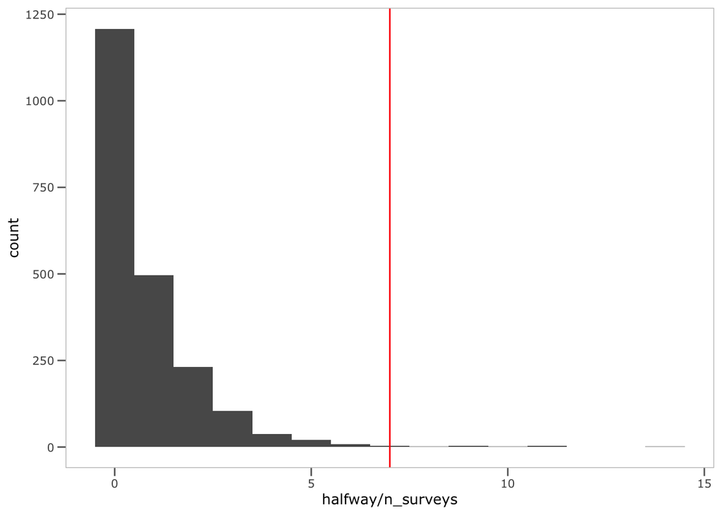

```r
##### remove outlier data and those with very infrequent threat surveys
nest_data_with_threat_data <-
  bind_rows(nest_data_FP_with_threat_data,
            nest_data_MP_with_threat_data,
            nest_data_BSC_with_threat_data) %>%
  filter(n_surveys > 0) %>%
  # mutate(dof_b = ifelse(dof_b == 1, "Y", "N")) %>%
  # dplyr::select(-fox_p) %>%
  mutate_at(vars(hum_b, veh_b, dog_b, don_b, dof_b, pbd_b, gul_b, hof_b),
            ~ as.factor(.)) %>%
  mutate_at(vars(hum_p, veh_p, dog_p, hof_p, fox_p),
            ~ ifelse(is.na(.), 0, .))

# nest_data_with_threat_data %>% filter(fundays > 10) %>% dplyr::select(fundays) %>% arrange(desc(fundays))

# nest_data_with_threat_data %>%
#   filter()

# nest_data_with_threat_data %>%
#   # filter(fundays <= 25) %>%
#   ggplot() +
#   geom_histogram(aes(fundays)) +
#   # geom_vline(xintercept = log(10), color = "red") +
#   luke_theme

nest_data_with_threat_data %>%
  ggplot() +
  geom_histogram(aes(halfway/n_surveys), binwidth = 1) +
  geom_vline(xintercept = 7, color = "red") +
  luke_theme
```

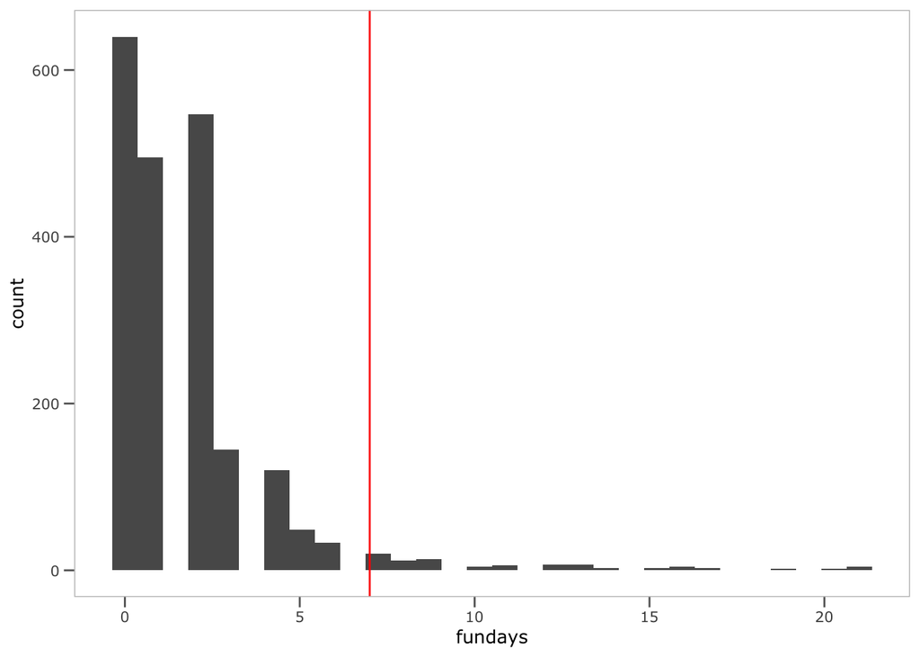

```r
nest_data_with_threat_data %>%
  ggplot() +
  geom_histogram(aes(fundays)) +
  geom_vline(xintercept = 7, color = "red") +
  luke_theme
```

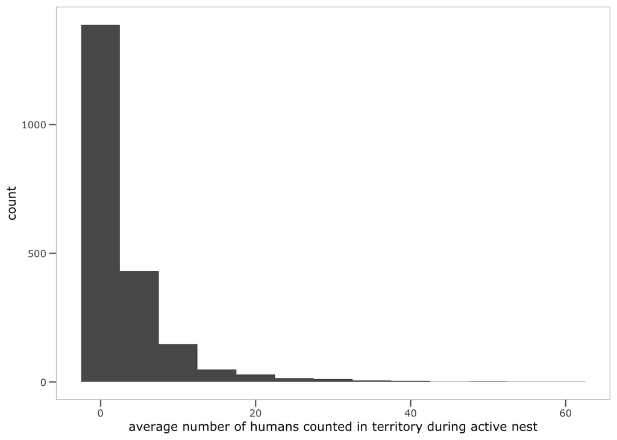

```r
nest_data_with_threat_data_7d <-
  nest_data_with_threat_data %>%
  filter(halfway/n_surveys <= 7)

# nest_data_with_threat_data

#### check variable distributions and collinearity ----
# determine the 99% quantile limit for each threat (i.e., to remove outlier data)
threat_data_99_ql_ <-
  nest_data_with_threat_data_7d %>%
  summarise_at(c("hum_a", "pbd_a", "gul_a", "veh_a", "dog_a", "don_a", "dof_a",
                 "hum_m", "pbd_m", "gul_m", "veh_m", "dog_m", "don_m", "dof_m",
                 "hum_p", "veh_p", "dog_p", "hof_p", "fox_p"),
               ~ quantile(.x, probs = c(0.99)))

nest_data_with_threat_data_7d %>%
  filter(hum_a <= ceiling(as.numeric(threat_data_99_ql_$hum_a[1]))) %>%
  ggplot() +
  geom_histogram(aes(hum_a), binwidth = 5) +
  luke_theme +
  xlab("average number of humans counted in territory during active nest")
```

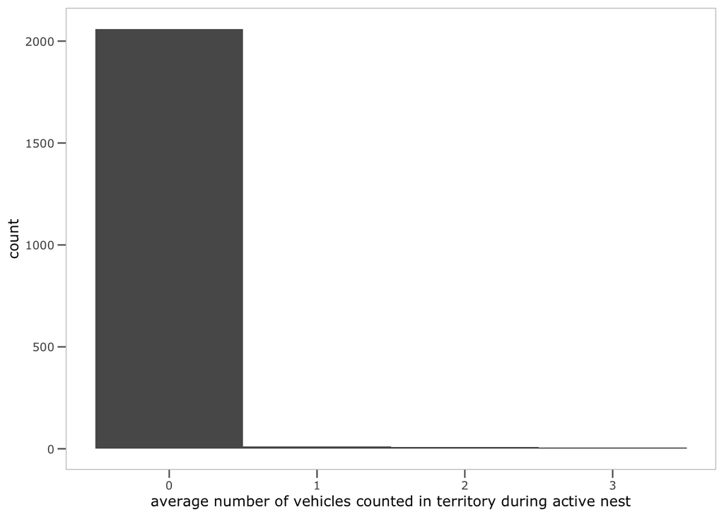

```r
nest_data_with_threat_data_7d %>%
  filter(veh_a <= ceiling(as.numeric(threat_data_99_ql_$veh_a[1]))) %>%
  ggplot() +
  geom_histogram(aes(veh_a), binwidth = 1) +
  luke_theme +
  xlab("average number of vehicles counted in territory during active nest")
```

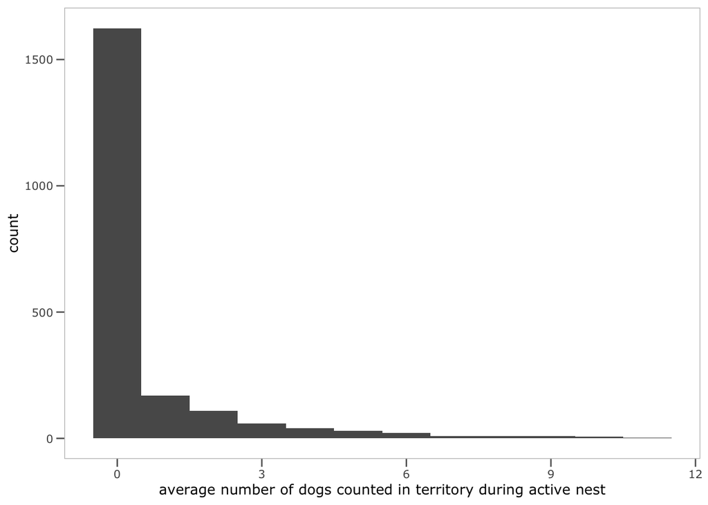

```r
nest_data_with_threat_data_7d %>%
  filter(dog_a <= ceiling(as.numeric(threat_data_99_ql_$dog_a[1]))) %>%
  ggplot() +
  geom_histogram(aes(dog_a), binwidth = 1) +
  luke_theme +
  xlab("average number of dogs counted in territory during active nest")
```

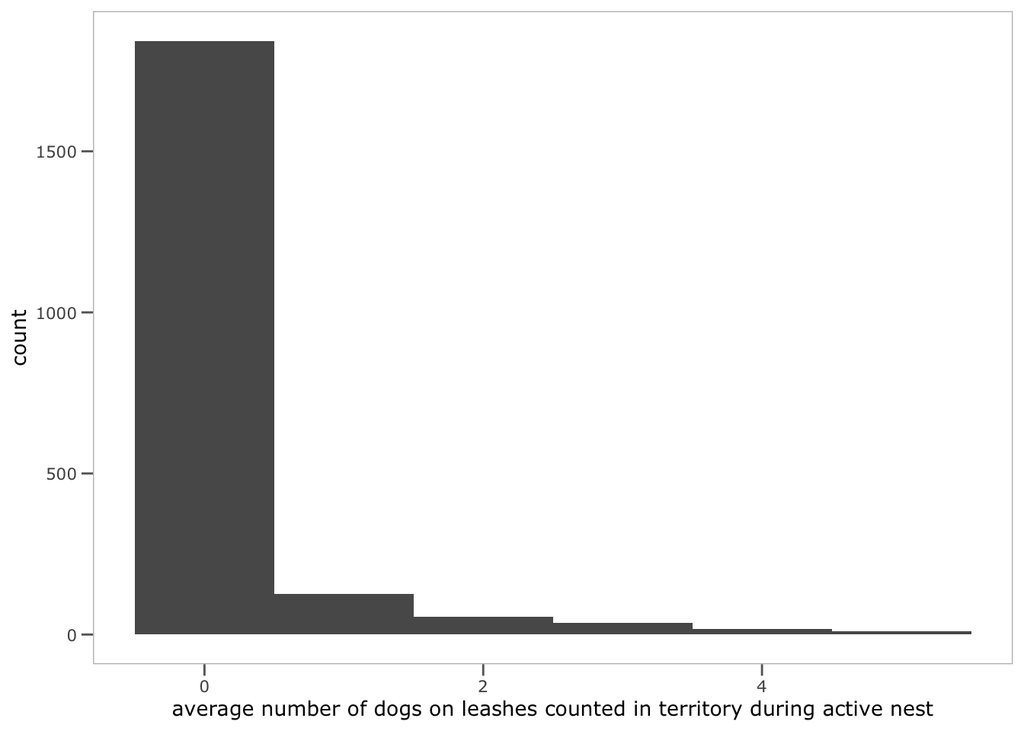

```r
nest_data_with_threat_data_7d %>%
  filter(don_a <= ceiling(as.numeric(threat_data_99_ql_$don_a[1]))) %>%
  ggplot() +
  geom_histogram(aes(don_a), binwidth = 1) +
  luke_theme +
  xlab("average number of dogs on leashes counted in territory during active nest")
```

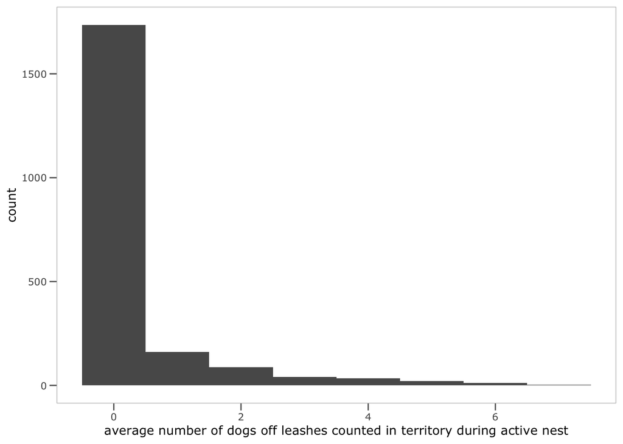

```r
nest_data_with_threat_data_7d %>%
  filter(dof_a <= ceiling(as.numeric(threat_data_99_ql_$dof_a[1]))) %>%
  ggplot() +
  geom_histogram(aes(dof_a), binwidth = 1) +
  luke_theme +
  xlab("average number of dogs off leashes counted in territory during active nest")
```

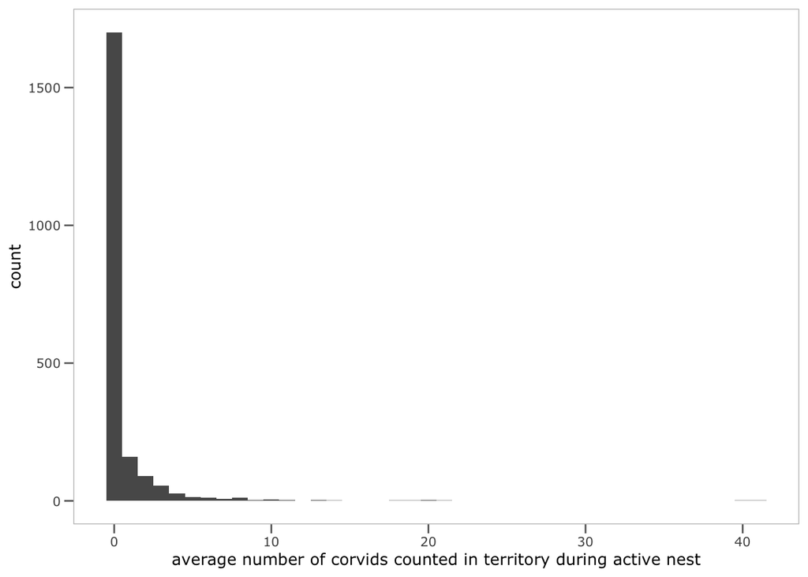

```r
nest_data_with_threat_data_7d %>%
  filter(dof_a <= ceiling(as.numeric(threat_data_99_ql_$pbd_a[1]))) %>%
  ggplot() +
  geom_histogram(aes(pbd_a), binwidth = 1) +
  luke_theme +
  xlab("average number of corvids counted in territory during active nest")
```

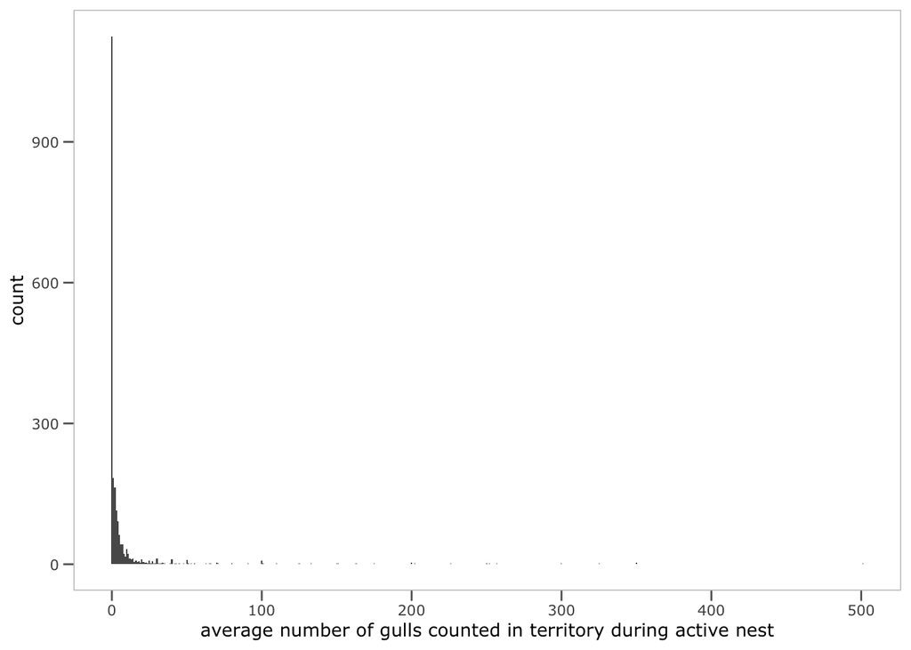

```r
nest_data_with_threat_data_7d %>%
  filter(dof_a <= ceiling(as.numeric(threat_data_99_ql_$gul_a[1]))) %>%
  ggplot() +
  geom_histogram(aes(gul_a), binwidth = 1) +
  luke_theme +
  xlab("average number of gulls counted in territory during active nest")
```

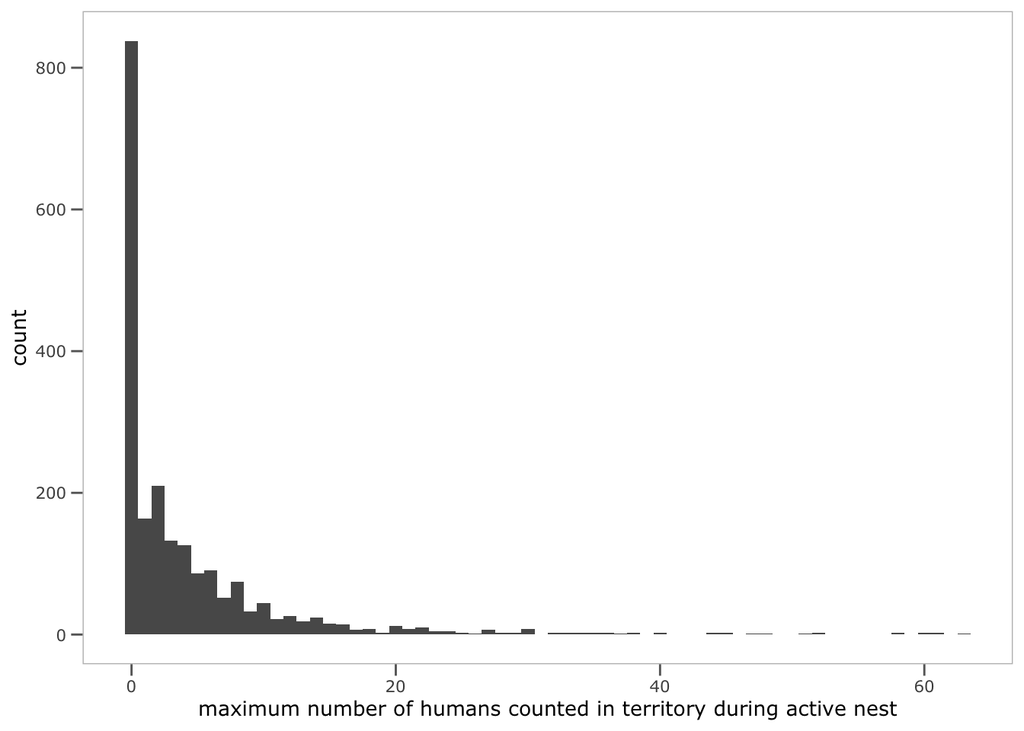

```r
nest_data_with_threat_data_7d %>%
  filter(hum_m <= ceiling(as.numeric(threat_data_99_ql_$hum_m[1]))) %>%
  ggplot() +
  geom_histogram(aes(hum_m), binwidth = 1) +
  luke_theme +
  xlab("maximum number of humans counted in territory during active nest")
```

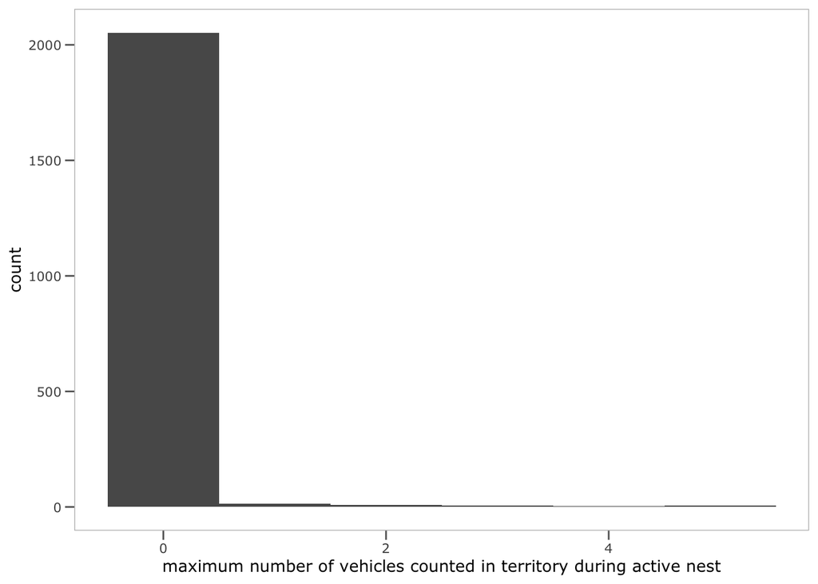

```r
nest_data_with_threat_data_7d %>%
  filter(veh_m <= ceiling(as.numeric(threat_data_99_ql_$veh_m[1]))) %>%
  ggplot() +
  geom_histogram(aes(veh_m), binwidth = 1) +
  luke_theme +
  xlab("maximum number of vehicles counted in territory during active nest")
```

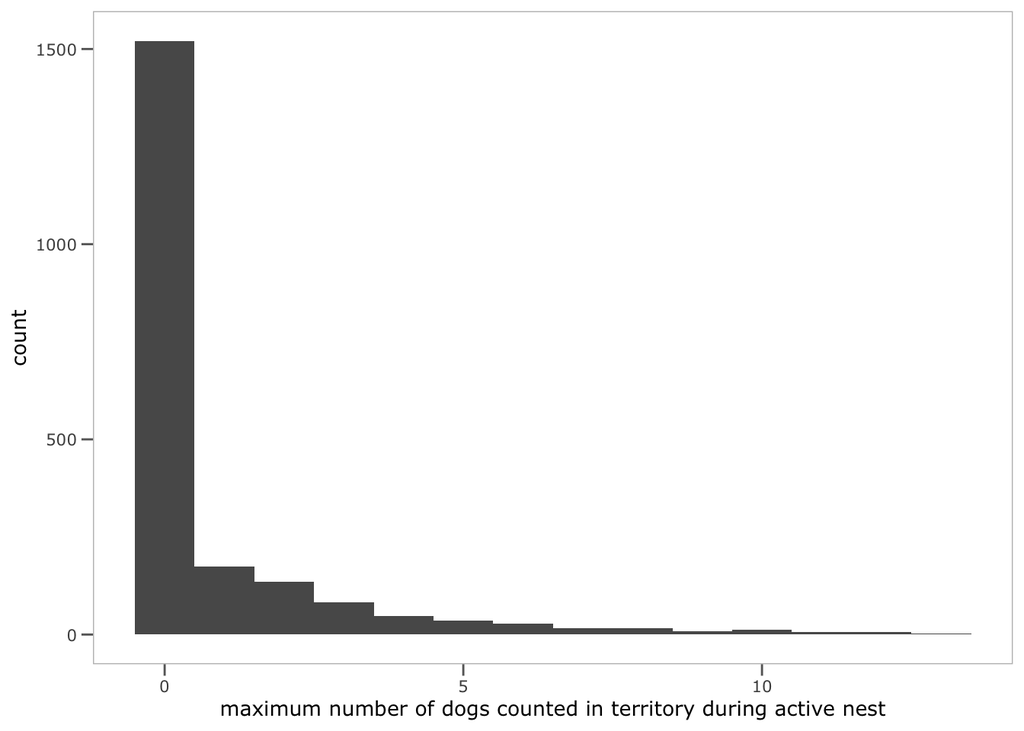

```r
nest_data_with_threat_data_7d %>%
  filter(dog_m <= ceiling(as.numeric(threat_data_99_ql_$dog_m[1]))) %>%
  ggplot() +
  geom_histogram(aes(dog_m), binwidth = 1) +
  luke_theme +
  xlab("maximum number of dogs counted in territory during active nest")
```

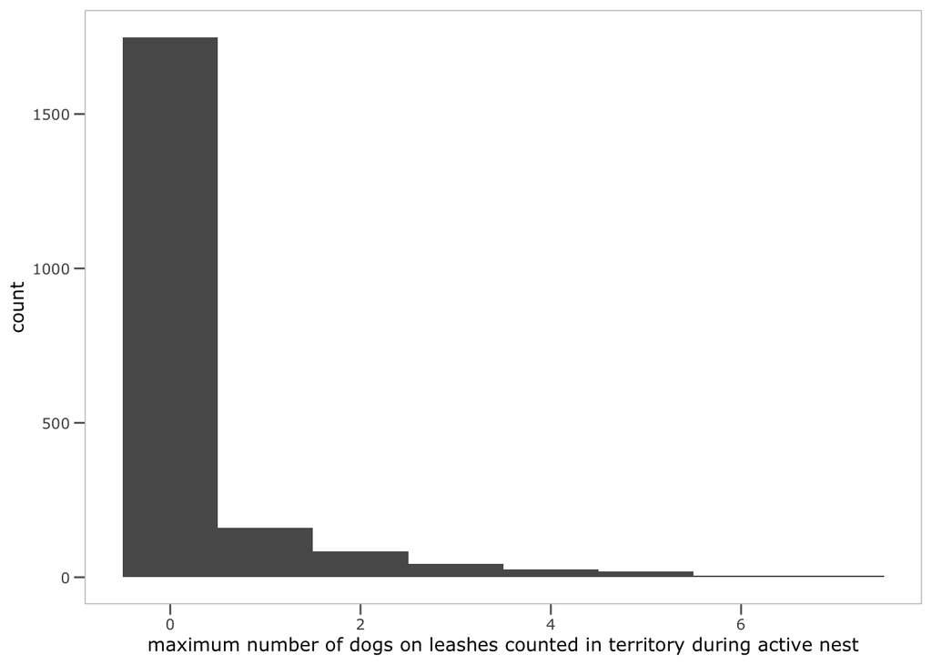

```r
nest_data_with_threat_data_7d %>%
  filter(don_m <= ceiling(as.numeric(threat_data_99_ql_$don_m[1]))) %>%
  ggplot() +
  geom_histogram(aes(don_m), binwidth = 1) +
  luke_theme +
  xlab("maximum number of dogs on leashes counted in territory during active nest")
```

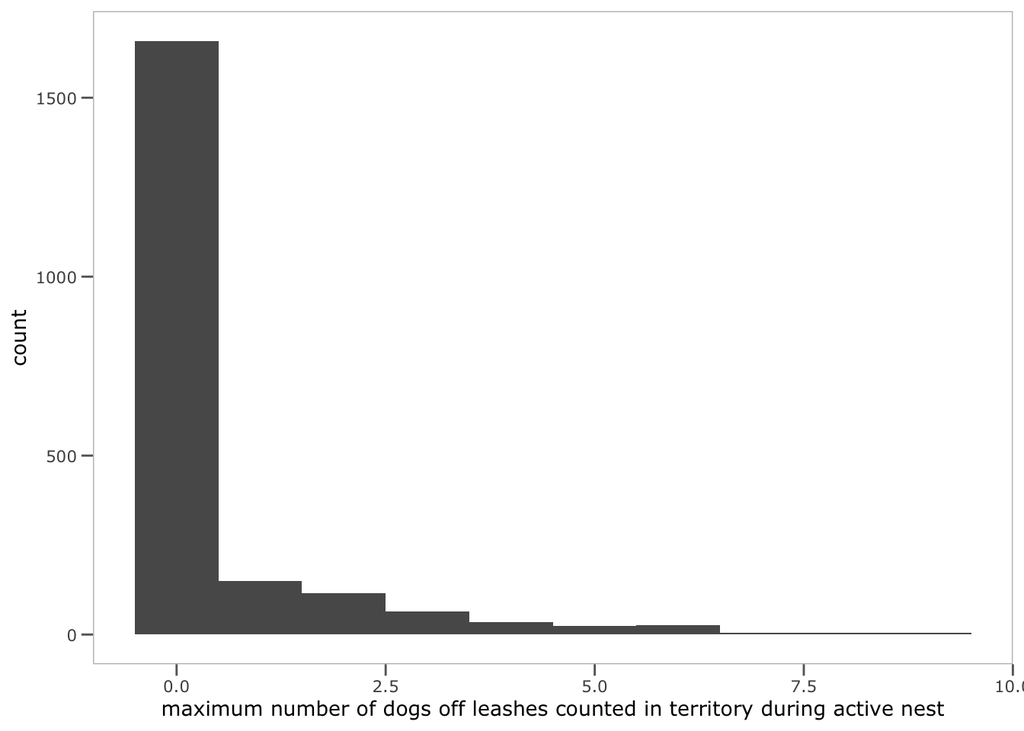

```r
nest_data_with_threat_data_7d %>%
  filter(dof_m <= ceiling(as.numeric(threat_data_99_ql_$dof_m[1]))) %>%
  ggplot() +
  geom_histogram(aes(dof_m), binwidth = 1) +
  luke_theme +
  xlab("maximum number of dogs off leashes counted in territory during active nest")
```

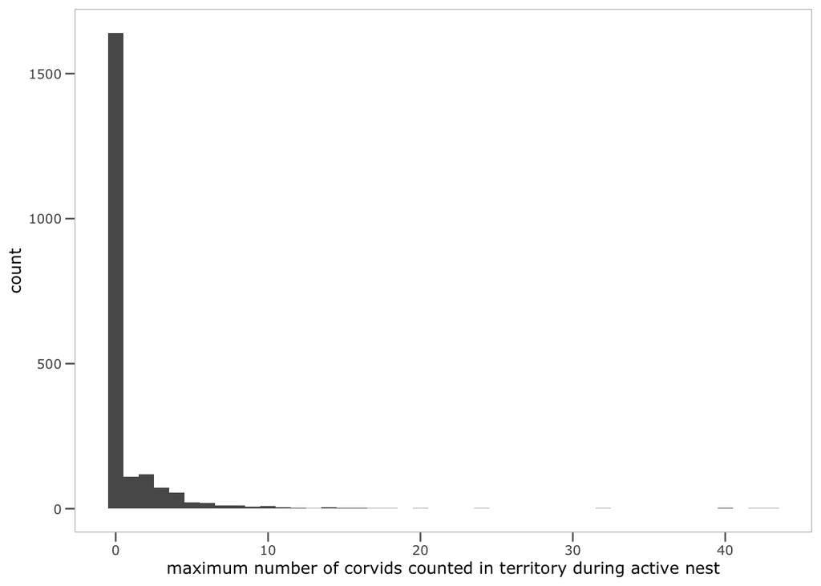

```r
nest_data_with_threat_data_7d %>%
  filter(dof_a <= ceiling(as.numeric(threat_data_99_ql_$pbd_m[1]))) %>%
  ggplot() +
  geom_histogram(aes(pbd_m), binwidth = 1) +
  luke_theme +
  xlab("maximum number of corvids counted in territory during active nest")
```

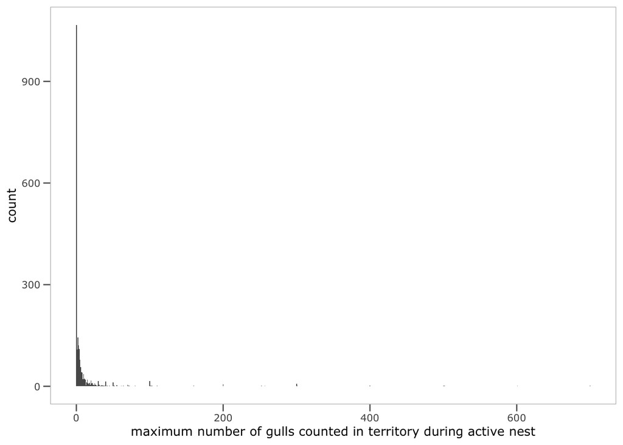

```r
nest_data_with_threat_data_7d %>%
  filter(dof_a <= ceiling(as.numeric(threat_data_99_ql_$gul_m[1]))) %>%
  ggplot() +
  geom_histogram(aes(gul_m), binwidth = 1) +
  luke_theme +
  xlab("maximum number of gulls counted in territory during active nest")
```

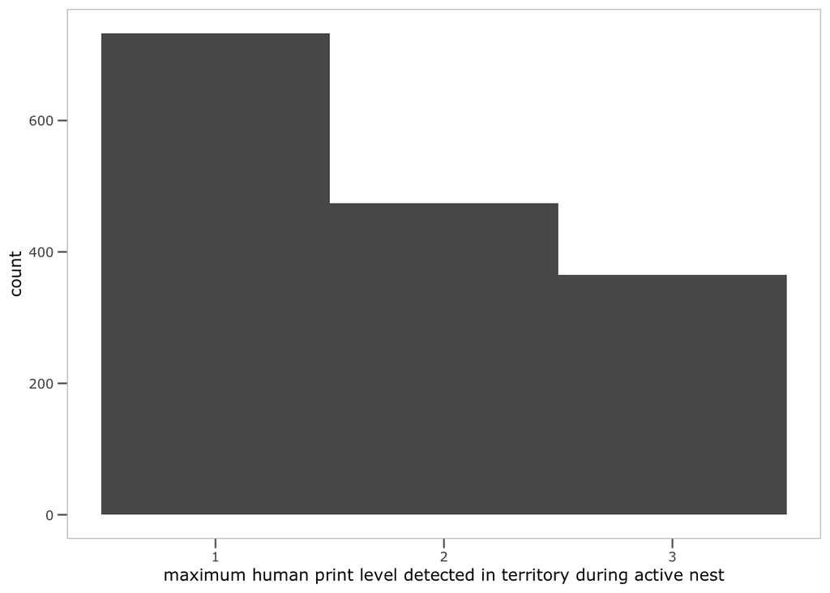

```r
nest_data_with_threat_data_7d %>%
  filter(hum_p <= ceiling(as.numeric(threat_data_99_ql_$hum_p[1]))) %>%
  ggplot() +
  geom_histogram(aes(hum_p), binwidth = 1) +
  luke_theme +
  xlab("maximum human print level detected in territory during active nest")
```

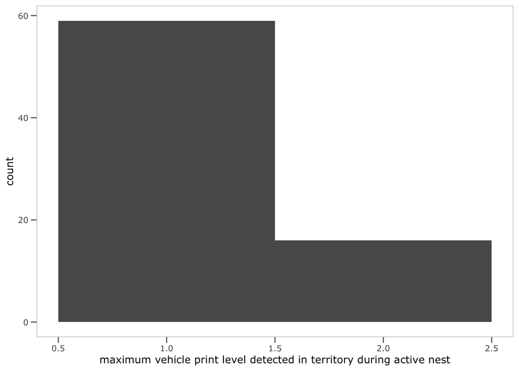

```r
nest_data_with_threat_data_7d %>%
  filter(veh_p < ceiling(as.numeric(threat_data_99_ql_$veh_p[1]))) %>%
  ggplot() +
  geom_histogram(aes(veh_p), binwidth = 1) +
  luke_theme +
  xlab("maximum vehicle print level detected in territory during active nest")
```

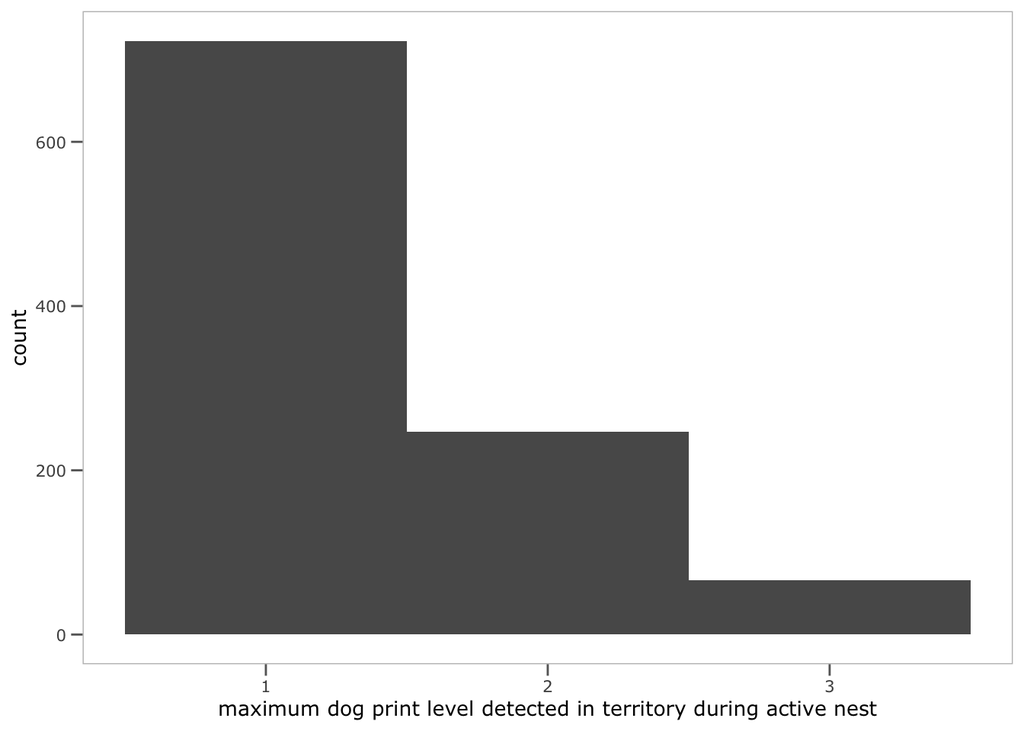

```r
nest_data_with_threat_data_7d %>%
  filter(dog_p <= ceiling(as.numeric(threat_data_99_ql_$dog_p[1]))) %>%
  ggplot() +
  geom_histogram(aes(dog_p), binwidth = 1) +
  luke_theme +
  xlab("maximum dog print level detected in territory during active nest")
```

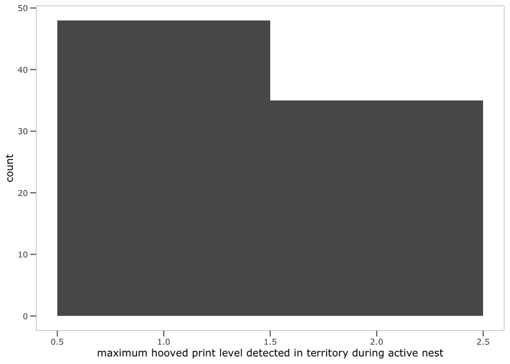

```r
nest_data_with_threat_data_7d %>%
  filter(hof_p <= ceiling(as.numeric(threat_data_99_ql_$hof_p[1]))) %>%
  ggplot() +
  geom_histogram(aes(hof_p), binwidth = 1) +
  luke_theme +
  xlab("maximum hooved print level detected in territory during active nest")
```

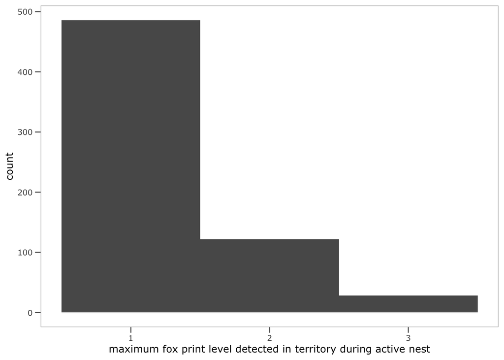

```r
nest_data_with_threat_data_7d %>%
  filter(fox_p <= ceiling(as.numeric(threat_data_99_ql_$fox_p[1]))) %>%
  ggplot() +
  geom_histogram(aes(fox_p), binwidth = 1) +
  luke_theme +
  xlab("maximum fox print level detected in territory during active nest")
```

```r
nest_data_with_threat_data_7d_ <-
  nest_data_with_threat_data_7d %>%
  filter(fox_p <= ceiling(as.numeric(threat_data_99_ql_$fox_p[1]))) %>%
  filter(hum_a <= ceiling(as.numeric(threat_data_99_ql_$hum_a[1]))) %>%
  filter(veh_a <= ceiling(as.numeric(threat_data_99_ql_$veh_a[1]))) %>%
  filter(dog_a <= ceiling(as.numeric(threat_data_99_ql_$dog_a[1]))) %>%
  filter(don_a <= ceiling(as.numeric(threat_data_99_ql_$don_a[1]))) %>%
  filter(dof_a <= ceiling(as.numeric(threat_data_99_ql_$dof_a[1]))) %>%
  filter(pbd_a <= ceiling(as.numeric(threat_data_99_ql_$pbd_a[1]))) %>%
  filter(gul_a <= ceiling(as.numeric(threat_data_99_ql_$gul_a[1]))) %>%
  filter(hum_m <= ceiling(as.numeric(threat_data_99_ql_$hum_m[1]))) %>%
  filter(veh_m <= ceiling(as.numeric(threat_data_99_ql_$veh_m[1]))) %>%
  filter(dog_m <= ceiling(as.numeric(threat_data_99_ql_$dog_m[1]))) %>%
  filter(don_m <= ceiling(as.numeric(threat_data_99_ql_$don_m[1]))) %>%
  filter(dof_m <= ceiling(as.numeric(threat_data_99_ql_$dof_m[1]))) %>%
  filter(pbd_m <= ceiling(as.numeric(threat_data_99_ql_$pbd_m[1]))) %>%
  filter(gul_m <= ceiling(as.numeric(threat_data_99_ql_$gul_m[1]))) %>%
  filter(hum_p <= ceiling(as.numeric(threat_data_99_ql_$hum_p[1]))) %>%
  filter(veh_p <= ceiling(as.numeric(threat_data_99_ql_$veh_p[1]))) %>%
  filter(dog_p <= ceiling(as.numeric(threat_data_99_ql_$dog_p[1]))) %>%
  filter(hof_p <= ceiling(as.numeric(threat_data_99_ql_$hof_p[1]))) %>%
  mutate(fox_p = ifelse(is.infinite(fox_p), 0, fox_p) %>% as.factor())
```

```r
write.csv(nest_data_with_threat_data_7d_, "data/nest_data_with_threat_data_7d_22082025.csv")
```

### Sample size summary

Number of nests

```r
nest_data_with_threat_data_7d_ %>%
  summarise(n_obs = n())
```

```
# A tibble: 1 × 1
  n_obs
  <int>
1  1970
```

Number of nests at each region

```r
nest_data_with_threat_data_7d_ %>%
  group_by(region) %>%
  summarise(n_obs = n())
```

```
# A tibble: 3 × 2
  region n_obs
  <chr>  <int>
1 BSC      415
2 FP       653
3 MP       902
```

Number of nests at each region for each year

```r
nest_data_with_threat_data_7d_ %>%
  group_by(region, season) %>%
  summarise(n_obs = n()) %>%
  pivot_wider(names_from = region, values_from = n_obs) %>%
  mutate(season = as.numeric(as.character(season))) %>%
  arrange(season)
```

```
# A tibble: 18 × 4
   season   BSC    FP    MP
    <dbl> <int> <int> <int>
 1 200607     8    NA    14
 2 200708     8    NA    19
 3 200809     7    NA     9
 4 200910     7     6    15
 5 201011    11    21    23
 6 201112    24    11    40
 7 201213    17    12    43
 8 201314    10    20    44
 9 201415    15    22    59
10 201516    22    27    71
11 201617    41    40    86
12 201718    38    44    60
13 201819    33    58    56
14 201920    42    69    53
15 202021    48    78    74
16 202122    26    72    83
17 202223    27    67    76
18 202324    31   106    77
```

Number of nests at each region in each management level

```r
nest_data_with_threat_data_7d_ %>%
  group_by(region, level) %>%
  summarise(n_obs = n()) %>%
  pivot_wider(names_from = region, values_from = n_obs)
```

```
# A tibble: 5 × 4
  level   BSC    FP    MP
  <fct> <int> <int> <int>
1 L0       23   119   167
2 L1       38    49    68
3 L2       66    21    82
4 L3      284   451   583
5 L4        4    13     2
```

Number of nests at each region in each management status

```r
nest_data_with_threat_data_7d_ %>%
  group_by(region, status) %>%
  summarise(n_obs = n()) %>%
  pivot_wider(names_from = region, values_from = n_obs)
```

```
# A tibble: 2 × 4
  status   BSC    FP    MP
  <fct>  <int> <int> <int>
1 N         59   138   226
2 Y        356   515   676
```

## Nest survival modeling

### Prepare data for RMark

```r
nest_data_with_threat_data_7d_ <-
  read.csv("data/nest_data_with_threat_data_7d_22082025.csv") %>%
  mutate(season = as.factor(season),
         nest_hab = as.factor(nest_hab),
         status = as.factor(status),
         level = as.factor(level))
```

```r
occ_FP <-
  nest_data_with_threat_data_7d_ %>%
  filter(region == "FP") %>%
  pull(LastChecked) %>%
  max(., na.rm = TRUE)

occ_MP <-
  nest_data_with_threat_data_7d_ %>%
  filter(region == "MP") %>%
  pull(LastChecked) %>%
  max(., na.rm = TRUE)

occ_BSC <-
  nest_data_with_threat_data_7d_ %>%
  filter(region == "BSC") %>%
  pull(LastChecked) %>%
  max(., na.rm = TRUE)

# create processed RMARK data format as NestSurvival with Year as group
nest_data.processed_FP_5d <-
  RMark::process.data(nest_data_with_threat_data_7d_ %>%
                        filter(region == "FP"),
                      model = "Nest",
                      nocc = occ_FP, groups = c("season",
                                                "nest_hab",
                                                "status",
                                                # "site"
                                                # "fox_p",
                                                "level"))

nest_data.processed_MP_5d <-
  RMark::process.data(nest_data_with_threat_data_7d_ %>%
                        filter(region == "MP"),
                      model = "Nest",
                      nocc = occ_MP, groups = c("season",
                                                "nest_hab",
                                                "status",
                                                # "site",
                                                # "fox_p",
                                                "level"))

nest_data.processed_BSC_5d <-
  RMark::process.data(nest_data_with_threat_data_7d_ %>%
                        filter(region == "BSC"),
                      model = "Nest",
                      nocc = occ_BSC, groups = c("season",
                                                "nest_hab",
                                                "status",
                                                # "site",
                                                # "fox_p",
                                                "level"))

# create the design data
nest_fate.ddl_FP_5d <- RMark::make.design.data(nest_data.processed_FP_5d)
nest_fate.ddl_MP_5d <- RMark::make.design.data(nest_data.processed_MP_5d)
nest_fate.ddl_BSC_5d <- RMark::make.design.data(nest_data.processed_BSC_5d)

# add a new variable to the design data that is the quadratic transformation of
# time
time <- c(0:(occ_FP-1))
Cubic <- time^3
Quadratic <- time^2
quad_time <- data.frame(time, Quadratic, Cubic)
quad_time$time <- c(1:occ_FP)
nest_fate.ddl_FP_5d$S <-
  RMark::merge_design.covariates(nest_fate.ddl_FP_5d$S, quad_time,
                                 bygroup = FALSE, bytime = TRUE)

time <- c(0:(occ_MP-1))
Cubic <- time^3
Quadratic <- time^2
quad_time <- data.frame(time, Quadratic, Cubic)
quad_time$time <- c(1:occ_MP)
nest_fate.ddl_MP_5d$S <-
  RMark::merge_design.covariates(nest_fate.ddl_MP_5d$S, quad_time,
                                 bygroup = FALSE, bytime = TRUE)

time <- c(0:(occ_BSC-1))
Cubic <- time^3
Quadratic <- time^2
quad_time <- data.frame(time, Quadratic, Cubic)
quad_time$time <- c(1:occ_BSC)
nest_fate.ddl_BSC_5d$S <-
  RMark::merge_design.covariates(nest_fate.ddl_BSC_5d$S, quad_time,
                                 bygroup = FALSE, bytime = TRUE)

# nest_fate.ddl$S <-
#   RMark::merge_design.covariates(nest_fate.ddl$S, data.frame(management_level = c(0, 1, 2, 3, 4)),
#                                  bygroup = FALSE, bytime = FALSE)

# nest_fate.ddl$S <-
#   inner_join(nest_fate.ddl$S, int_threat_data, by = c("site", "time"))


RMark_data_FP <-
  list(nest_data.processed = nest_data.processed_FP_5d,
       nest_fate.ddl = nest_fate.ddl_FP_5d)

RMark_data_MP <-
  list(nest_data.processed = nest_data.processed_MP_5d,
       nest_fate.ddl = nest_fate.ddl_MP_5d)

RMark_data_BSC <-
  list(nest_data.processed = nest_data.processed_BSC_5d,
       nest_fate.ddl = nest_fate.ddl_BSC_5d)

# RMark_data_FP$nest_data.processed$data %>% summary()
# RMark_data_MP$nest_data.processed$data %>% summary()
# RMark_data_BSC$nest_data.processed$data %>% summary()
```

### Fleurieu Peninsula model selection

```r
nest_survival_FP <- function()
{
  # Specify models to test

  # constant daily survival rate (DSR)
  S.dot <-
    list(formula = ~1)

  # fox print status
  # S.fox_p <-
  #   list(formula = ~fox_p)

  #### maximum counts of threats
  # max humans detected
  S.hum_m <-
    list(formula = ~hum_m)

  # max vehicles detected
  S.veh_m <-
    list(formula = ~veh_m)

  # max dogs detected
  S.dog_m <-
    list(formula = ~dog_m)

  # max dogs off leash detected
  S.dof_m <-
    list(formula = ~dof_m)

  # max corvids detected
  S.pbd_m <-
    list(formula = ~pbd_m)

  # max gulls detected
  S.gul_m <-
    list(formula = ~gul_m)

  #### interaction of max threat counts and management status
  # max humans detected
  S.hum_m_x_status <-
    list(formula = ~hum_m * status)

  # max vehicles detected and management status
  S.veh_m_x_status <-
    list(formula = ~veh_m * status)

  # max dogs detected and management status
  S.dog_m_x_status <-
    list(formula = ~dog_m * status)

  # max dogs off leash detected and management status
  S.dof_m_x_status <-
    list(formula = ~dof_m * status)

  # max corvids detected and management status
  S.pbd_m_x_status <-
    list(formula = ~pbd_m * status)

  # max gulls detected and management status
  S.gul_m_x_status <-
    list(formula = ~gul_m * status)

  # specify to run as a nest survival model in program MARK
  cml <- RMark::create.model.list("Nest")

  # run model list in MARK. Supress generation of MARK files.
  model.list <- RMark::mark.wrapper(cml,
                                    data = RMark_data_FP$nest_data.processed,
                                    ddl = RMark_data_FP$nest_fate.ddl,
                                    threads = 4,
                                    brief = TRUE,
                                    delete = TRUE)

  # store completed model list
  return(model.list)
}
nest_survival_run_FP <- nest_survival_FP()
nest_survival_run_FP
nest_survival_FP <-
  list(RMark_data = RMark_data_FP,
       model_selection = nest_survival_run_FP)
saveRDS(nest_survival_FP, file = "output/nest_survival_FP_threats&status_220825.rds")
```

### Mornington Peninsula model selection

```r
nest_survival_MP <- function()
{
  # Specify models to test

  # constant daily survival rate (DSR)
  S.dot <-
    list(formula = ~1)

  # fox print status
  # S.fox_p <-
  #   list(formula = ~fox_p)

  #### maximum counts of threats
  # max humans detected
  S.hum_m <-
    list(formula = ~hum_m)

  # max vehicles detected
  # S.veh_m <-
  #   list(formula = ~veh_m)

  # max dogs detected
  S.dog_m <-
    list(formula = ~dog_m)

  # max dogs off leash detected
  S.dof_m <-
    list(formula = ~dof_m)

  # max corvids detected
  S.pbd_m <-
    list(formula = ~pbd_m)

  # max gulls detected
  S.gul_m <-
    list(formula = ~gul_m)

  #### interaction of max threat counts and management status
  # max humans detected
  S.hum_m_x_status <-
    list(formula = ~hum_m * status)

  # max vehicles detected and management status
  # S.veh_m_x_status <-
  #   list(formula = ~veh_m * status)

  # max dogs detected and management status
  S.dog_m_x_status <-
    list(formula = ~dog_m * status)

  # max dogs off leash detected and management status
  S.dof_m_x_status <-
    list(formula = ~dof_m * status)

  # max corvids detected and management status
  S.pbd_m_x_status <-
    list(formula = ~pbd_m * status)

  # max gulls detected and management status
  S.gul_m_x_status <-
    list(formula = ~gul_m * status)

  # specify to run as a nest survival model in program MARK
  cml <- RMark::create.model.list("Nest")

  # run model list in MARK. Supress generation of MARK files.
  model.list <- RMark::mark.wrapper(cml,
                                    data = RMark_data_MP$nest_data.processed,
                                    ddl = RMark_data_MP$nest_fate.ddl,
                                    threads = 4,
                                    brief = TRUE,
                                    delete = TRUE)

  # store completed model list
  return(model.list)
}

nest_survival_run_MP <- nest_survival_MP()
nest_survival_run_MP
nest_survival_MP <-
  list(RMark_data = RMark_data_MP,
       model_selection = nest_survival_run_MP)
saveRDS(nest_survival_MP, file = "output/nest_survival_MP_threats&status_220825.rds")
```

### Bellarine / Surf Coast model selection

```r
nest_survival_BSC <- function()
{
  # Specify models to test

  # constant daily survival rate (DSR)
  S.dot <-
    list(formula = ~1)

  # fox print status
  # S.fox_p <-
  #   list(formula = ~fox_p)

  #### maximum counts of threats
  # max humans detected
  S.hum_m <-
    list(formula = ~hum_m)

  # max vehicles detected
  # S.veh_m <-
  #   list(formula = ~veh_m)

  # max dogs detected
  S.dog_m <-
    list(formula = ~dog_m)

  # max dogs off leash detected
  S.dof_m <-
    list(formula = ~dof_m)

  # max corvids detected
  S.pbd_m <-
    list(formula = ~pbd_m)

  # max gulls detected
  S.gul_m <-
    list(formula = ~gul_m)

  #### interaction of max threat counts and management status
  # max humans detected
  S.hum_m_x_status <-
    list(formula = ~hum_m * status)

  # max vehicles detected and management status
  # S.veh_m_x_status <-
  #   list(formula = ~veh_m * status)

  # max dogs detected and management status
  S.dog_m_x_status <-
    list(formula = ~dog_m * status)

  # max dogs off leash detected and management status
  S.dof_m_x_status <-
    list(formula = ~dof_m * status)

  # max corvids detected and management status
  S.pbd_m_x_status <-
    list(formula = ~pbd_m * status)

  # max gulls detected and management status
  S.gul_m_x_status <-
    list(formula = ~gul_m * status)

  # specify to run as a nest survival model in program MARK
  cml <- RMark::create.model.list("Nest")

  # run model list in MARK. Supress generation of MARK files.
  model.list <- RMark::mark.wrapper(cml,
                                    data = RMark_data_BSC$nest_data.processed,
                                    ddl = RMark_data_BSC$nest_fate.ddl,
                                    threads = 4,
                                    brief = TRUE,
                                    delete = TRUE)

  # store completed model list
  return(model.list)
}

nest_survival_run_BSC <- nest_survival_BSC()
nest_survival_run_BSC
nest_survival_BSC <-
  list(RMark_data = RMark_data_BSC,
       model_selection = nest_survival_run_BSC)
saveRDS(nest_survival_BSC, file = "output/nest_survival_BSC_threats&status_220825.rds")
```

# Results

model selection results

```r
nest_survival_FP <- readRDS(file = "output/nest_survival_FP_threats&status_220825.rds")
nest_survival_run_FP <- nest_survival_FP$model_selection

nest_survival_run_FP$model.table %>%
  dplyr::select(model, npar, DeltaAICc, weight) %>%
  gt() %>%
  cols_label(model = html("<i>Fleurieu Peninsula</i>"),
             npar = "K",
             DeltaAICc = "DeltaAICc",
             weight = "weight") %>%
  fmt_number(columns = DeltaAICc,
             rows = 1:10,
             decimals = 2,
             use_seps = FALSE) %>%
  fmt_number(columns = weight,
             rows = 1:10,
             decimals = 3,
             use_seps = FALSE) %>%
  cols_align(align = "left",
             columns = vars(model)) %>%
  tab_options(row_group.font.weight = "bold",
              row_group.background.color = brewer.pal(9,"Greys")[3],
              table.font.size = 12,
              data_row.padding = 3,
              row_group.padding = 4,
              summary_row.padding = 2,
              column_labels.font.size = 14,
              row_group.font.size = 12,
              table.width = pct(80))
```

| *Fleurieu Peninsula* | K | DeltaAICc | weight |
| --- | --- | --- | --- |
| S(~gul_m * status) | 4 | 0.00 | 0.517 |
| S(~pbd_m * status) | 4 | 0.37 | 0.430 |
| S(~dof_m * status) | 4 | 6.05 | 0.025 |
| S(~veh_m * status) | 4 | 7.13 | 0.015 |
| S(~dog_m * status) | 4 | 7.66 | 0.011 |
| S(~hum_m * status) | 4 | 10.99 | 0.002 |
| S(~pbd_m) | 2 | 70.72 | 0.000 |
| S(~1) | 1 | 86.94 | 0.000 |
| S(~dog_m) | 2 | 87.31 | 0.000 |
| S(~gul_m) | 2 | 88.26 | 0.000 |
| S(~dof_m) | 2 | 88.38692 | 0 |
| S(~hum_m) | 2 | 88.93452 | 0 |
| S(~veh_m) | 2 | 88.93592 | 0 |

```r
nest_survival_MP <- readRDS(file = "output/nest_survival_MP_threats&status_220825.rds")
nest_survival_run_MP <- nest_survival_MP$model_selection

nest_survival_run_MP$model.table %>%
  dplyr::select(model, npar, DeltaAICc, weight) %>%
  gt() %>%
  cols_label(model = html("<i>Mornington Peninsula</i>"),
             npar = "K",
             DeltaAICc = "DeltaAICc",
             weight = "weight") %>%
  fmt_number(columns = DeltaAICc,
             rows = 1:10,
             decimals = 2,
             use_seps = FALSE) %>%
  fmt_number(columns = weight,
             rows = 1:10,
             decimals = 3,
             use_seps = FALSE) %>%
  cols_align(align = "left",
             columns = vars(model)) %>%
  tab_options(row_group.font.weight = "bold",
              row_group.background.color = brewer.pal(9,"Greys")[3],
              table.font.size = 12,
              data_row.padding = 3,
              row_group.padding = 4,
              summary_row.padding = 2,
              column_labels.font.size = 14,
              row_group.font.size = 12,
              table.width = pct(80))
```

| *Mornington Peninsula* | K | DeltaAICc | weight |
| --- | --- | --- | --- |
| S(~pbd_m * status) | 4 | 0.00 | 0.926 |
| S(~hum_m * status) | 4 | 7.33 | 0.024 |
| S(~gul_m * status) | 4 | 7.60 | 0.021 |
| S(~dof_m * status) | 4 | 7.85 | 0.018 |
| S(~dog_m * status) | 4 | 8.74 | 0.012 |
| S(~pbd_m) | 2 | 20.88 | 0.000 |
| S(~hum_m) | 2 | 27.90 | 0.000 |
| S(~gul_m) | 2 | 28.06 | 0.000 |
| S(~1) | 1 | 29.11 | 0.000 |
| S(~dof_m) | 2 | 29.46 | 0.000 |
| S(~dog_m) | 2 | 29.58406 | 3.48586e-07 |

```r
nest_survival_BSC <- readRDS(file = "output/nest_survival_BSC_threats&status_220825.rds")
nest_survival_run_BSC <- nest_survival_BSC$model_selection

nest_survival_run_BSC$model.table %>%
  dplyr::select(model, npar, DeltaAICc, weight) %>%
  gt() %>%
  cols_label(model = html("<i>Bellarine / Surf Coast</i>"),
             npar = "K",
             DeltaAICc = "DeltaAICc",
             weight = "weight") %>%
  fmt_number(columns = DeltaAICc,
             rows = 1:10,
             decimals = 2,
             use_seps = FALSE) %>%
  fmt_number(columns = weight,
             rows = 1:10,
             decimals = 3,
             use_seps = FALSE) %>%
  cols_align(align = "left",
             columns = vars(model)) %>%
  tab_options(row_group.font.weight = "bold",
              row_group.background.color = brewer.pal(9,"Greys")[3],
              table.font.size = 12,
              data_row.padding = 3,
              row_group.padding = 4,
              summary_row.padding = 2,
              column_labels.font.size = 14,
              row_group.font.size = 12,
              table.width = pct(80))
```

| *Bellarine / Surf Coast* | K | DeltaAICc | weight |
| --- | --- | --- | --- |
| S(~pbd_m * status) | 4 | 0.00 | 0.755 |
| S(~dof_m * status) | 4 | 3.55 | 0.128 |
| S(~dog_m * status) | 4 | 5.71 | 0.043 |
| S(~hum_m * status) | 4 | 5.99 | 0.038 |
| S(~gul_m * status) | 4 | 6.08 | 0.036 |
| S(~pbd_m) | 2 | 38.77 | 0.000 |
| S(~1) | 1 | 42.29 | 0.000 |
| S(~gul_m) | 2 | 43.53 | 0.000 |
| S(~dof_m) | 2 | 43.76 | 0.000 |
| S(~hum_m) | 2 | 44.11 | 0.000 |
| S(~dog_m) | 2 | 44.23303 | 1.873849e-10 |

## Effect of weekends and holidays on nest survival

```r
S.fundays <-
  mark(data = RMark_data_FP$nest_data.processed,
       ddl = RMark_data_FP$nest_fate.ddl,
       model = "Nest",
       model.parameters = list("S" = list(formula =  ~ fundays)),
       brief = TRUE,
       delete = TRUE)
```

```
 Model: S(~fundays)  npar= 2  lnl =  2598.3095 AICc = 2602.3108
```

```r
min.fundays = min(RMark_data_FP$nest_data.processed$data$fundays)
max.fundays = max(RMark_data_FP$nest_data.processed$data$fundays)
fundays.values = seq(from = min.fundays, to = max.fundays, length = 100)
pred.fundays <-
  covariate.predictions(model = S.fundays,
                        data = data.frame(fundays = fundays.values),
                        indices = 1)
pred.fundays_FP <-
  pred.fundays$estimates %>%
  mutate(region = "FP")

S.fundays <-
  mark(data = RMark_data_MP$nest_data.processed,
       ddl = RMark_data_MP$nest_fate.ddl,
       model = "Nest",
       model.parameters = list("S" = list(formula =  ~ fundays)),
       brief = TRUE,
       delete = TRUE)
```

```
 Model: S(~fundays)  npar= 2  lnl =  3029.8355 AICc = 3033.8365
```

```r
min.fundays = min(RMark_data_MP$nest_data.processed$data$fundays)
max.fundays = max(RMark_data_MP$nest_data.processed$data$fundays)
fundays.values = seq(from = min.fundays, to = max.fundays, length = 100)
pred.fundays <-
  covariate.predictions(model = S.fundays,
                        data = data.frame(fundays = fundays.values),
                        indices = 1)

pred.fundays_MP <-
  pred.fundays$estimates %>%
  mutate(region = "MP")

S.fundays <-
  mark(data = RMark_data_BSC$nest_data.processed,
       ddl = RMark_data_BSC$nest_fate.ddl,
       model = "Nest",
       model.parameters = list("S" = list(formula =  ~ fundays)),
       brief = TRUE,
       delete = TRUE)
```

```
 Model: S(~fundays)  npar= 2  lnl =  1486.208 AICc = 1490.2105
```

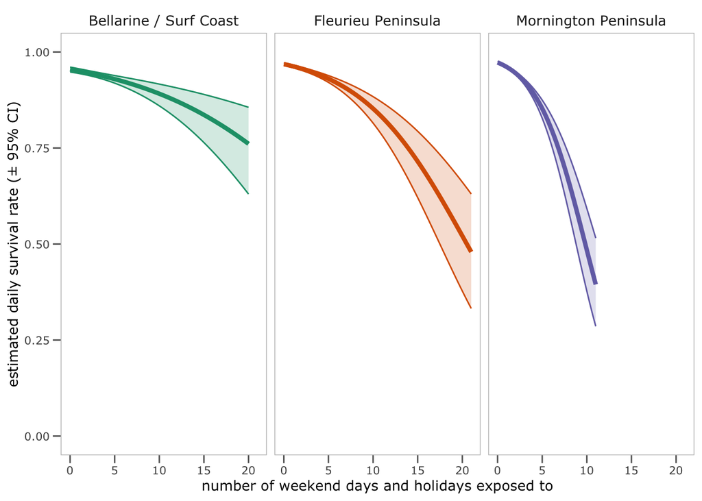

```r
min.fundays = min(RMark_data_BSC$nest_data.processed$data$fundays)
max.fundays = max(RMark_data_BSC$nest_data.processed$data$fundays)
fundays.values = seq(from = min.fundays, to = max.fundays, length = 100)
pred.fundays <-
  covariate.predictions(model = S.fundays,
                        data = data.frame(fundays = fundays.values),
                        indices = 1)

pred.fundays_BSC <-
  pred.fundays$estimates %>%
  mutate(region = "BSC")

pred.fundays <-
  bind_rows(pred.fundays_FP, pred.fundays_MP, pred.fundays_BSC)

ggplot(pred.fundays,
       aes(x = covdata, y = estimate, color = region, fill = region)) +
  geom_line(size = 1.5) +
  geom_ribbon(aes(ymin = lcl, ymax = ucl), alpha = 0.2) +
  scale_colour_brewer(palette = "Dark2") +
  scale_fill_brewer(palette = "Dark2") +
  scale_x_continuous(breaks = c(0, 5, 10, 15, 20, 25)) +
  luke_theme +
  theme(legend.position = "none",
        legend.justification = c(1, 0),
        strip.background = element_blank()) +
  xlab("number of weekend days and holidays exposed to") +
  ylab("estimated daily survival rate (± 95% CI)") +
  ylim(c(0, 1)) +
  facet_grid(. ~ region, labeller = as_labeller(region_names))
```

## Effect of management on mitigating the impact of weekends and holidays on nest survival

```r
S.fundays_status <-
  mark(data = RMark_data_FP$nest_data.processed,
       ddl = RMark_data_FP$nest_fate.ddl,
       model = "Nest",
       model.parameters = list("S" = list(formula =  ~ fundays + status)),
       brief = TRUE,
       delete = TRUE)
```

```
 Model: S(~fundays + status)  npar= 3  lnl =  2547.6255 AICc = 2553.6281
```

```r
min.fundays_status = min(RMark_data_FP$nest_data.processed$data$fundays)
max.fundays_status = max(RMark_data_FP$nest_data.processed$data$fundays)
fundays.values = seq(from = min.fundays_status, to = max.fundays_status, length = 100)
pred.fundays_status <-
  covariate.predictions(model = S.fundays_status,
                        data = data.frame(fundays = fundays.values),
                        indices = c(as.numeric(row.names(filter(RMark_data_FP$nest_fate.ddl$S, status == "N")[1,])),
                                    as.numeric(row.names(filter(RMark_data_FP$nest_fate.ddl$S, status == "Y")[1,]))))
pred.fundays_status_FP <-
  pred.fundays_status$estimates %>%
  mutate(region = "FP",
         status = ifelse(par.index == 1, "N", "Y"))

S.fundays_status <-
  mark(data = RMark_data_MP$nest_data.processed,
       ddl = RMark_data_MP$nest_fate.ddl,
       model = "Nest",
       model.parameters = list("S" = list(formula =  ~ fundays + status)),
       brief = TRUE,
       delete = TRUE)
```

```
 Model: S(~fundays + status)  npar= 3  lnl =  3026.9856 AICc = 3032.9876
```

```r
min.fundays_status = min(RMark_data_MP$nest_data.processed$data$fundays)
max.fundays_status = max(RMark_data_MP$nest_data.processed$data$fundays)
fundays.values = seq(from = min.fundays_status, to = max.fundays_status, length = 100)
pred.fundays_status <-
  covariate.predictions(model = S.fundays_status,
                        data = data.frame(fundays = fundays.values),
                        indices = c(as.numeric(row.names(filter(RMark_data_MP$nest_fate.ddl$S, status == "N")[1,])),
                                    as.numeric(row.names(filter(RMark_data_MP$nest_fate.ddl$S, status == "Y")[1,]))))
pred.fundays_status_MP <-
  pred.fundays_status$estimates %>%
  mutate(region = "MP",
         status = ifelse(par.index == 1, "N", "Y"))

S.fundays_status <-
  mark(data = RMark_data_BSC$nest_data.processed,
       ddl = RMark_data_BSC$nest_fate.ddl,
       model = "Nest",
       model.parameters = list("S" = list(formula =  ~ fundays + status)),
       brief = TRUE,
       delete = TRUE)
```

```
 Model: S(~fundays + status)  npar= 3  lnl =  1444.5921 AICc = 1450.5972
```

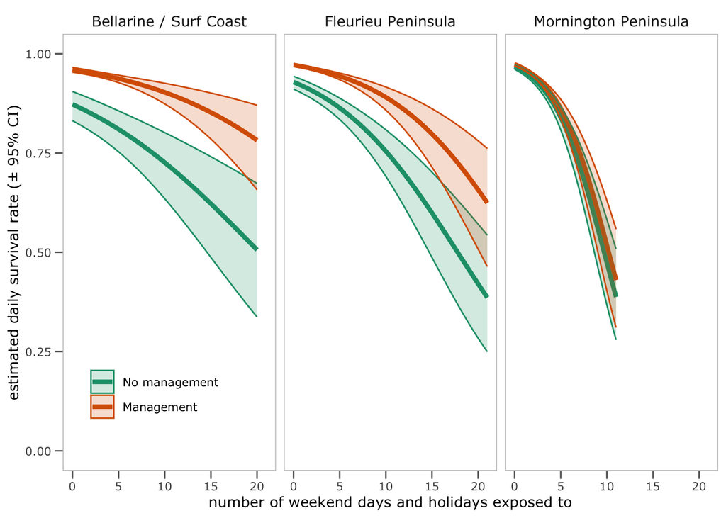

```r
min.fundays_status = min(RMark_data_BSC$nest_data.processed$data$fundays)
max.fundays_status = max(RMark_data_BSC$nest_data.processed$data$fundays)
fundays.values = seq(from = min.fundays_status, to = max.fundays_status, length = 100)
pred.fundays_status <-
  covariate.predictions(model = S.fundays_status,
                        data = data.frame(fundays = fundays.values),
                        indices = c(as.numeric(row.names(filter(RMark_data_BSC$nest_fate.ddl$S, status == "N")[1,])),
                                    as.numeric(row.names(filter(RMark_data_BSC$nest_fate.ddl$S, status == "Y")[1,]))))
pred.fundays_status_BSC <-
  pred.fundays_status$estimates %>%
  mutate(region = "BSC",
         status = ifelse(par.index == 1, "N", "Y"))

pred.fundays_status <-
  bind_rows(pred.fundays_status_FP, pred.fundays_status_MP, pred.fundays_status_BSC)

ggplot(pred.fundays_status,
       aes(x = covdata, y = estimate, color = status, fill = status)) +
  geom_line(size = 1.5) +
  geom_ribbon(aes(ymin = lcl, ymax = ucl), alpha = 0.2) +
  scale_colour_brewer(palette = "Dark2",
                      labels = c("No management", "Management")) +
  scale_fill_brewer(palette = "Dark2",
                      labels = c("No management", "Management")) +
  scale_x_continuous(breaks = c(0, 5, 10, 15, 20, 25)) +
  luke_theme +
  theme(legend.position = c(0.25, 0.1),
        legend.title = element_blank(),
        legend.justification = c(1, 0),
        strip.background = element_blank()) +
  xlab("number of weekend days and holidays exposed to") +
  ylab("estimated daily survival rate (± 95% CI)") +
  ylim(c(0, 1)) +
  facet_grid(. ~ region, labeller = as_labeller(region_names))
```

## Effect of management Levels on nest survival

```r
S.levels <-
  mark(data = RMark_data_FP$nest_data.processed,
       ddl = RMark_data_FP$nest_fate.ddl,
       model = "Nest",
       model.parameters = list("S" = list(formula =  ~ level)),
       brief = TRUE,
       delete = TRUE)
```

```
 Model: S(~level)  npar= 5  lnl =  2597.462 AICc = 2607.4684
```

```r
nest_survival_reals_FP_levels <-
  S.levels$results$real
Groups <- data.frame(
  str_split_fixed(rownames(nest_survival_reals_FP_levels), " ", n = 4))
nest_survival_reals_FP_levels <- cbind(Groups, nest_survival_reals_FP_levels)
nest_survival_reals_FP_levels$rows <-  rownames(nest_survival_reals_FP_levels)
nest_survival_reals_FP_levels$management_level <-
  as.factor(str_sub(nest_survival_reals_FP_levels$rows,
                    nchar(nest_survival_reals_FP_levels$rows) - 7, nchar(nest_survival_reals_FP_levels$rows) - 6))
nest_survival_reals_FP_levels <-
  nest_survival_reals_FP_levels %>%
  dplyr::select(management_level, estimate, se, lcl, ucl) %>%
  mutate(region = "FP")
row.names(nest_survival_reals_FP_levels) <- NULL

S.levels <-
  mark(data = RMark_data_MP$nest_data.processed,
       ddl = RMark_data_MP$nest_fate.ddl,
       model = "Nest",
       model.parameters = list("S" = list(formula =  ~ level)),
       brief = TRUE,
       delete = TRUE)
```

```
 Model: S(~level)  npar= 5  lnl =  3189.0882 AICc = 3199.0932
```

```r
nest_survival_reals_MP_levels <-
  S.levels$results$real
Groups <- data.frame(
  str_split_fixed(rownames(nest_survival_reals_MP_levels), " ", n = 4))
nest_survival_reals_MP_levels <- cbind(Groups, nest_survival_reals_MP_levels)
nest_survival_reals_MP_levels$rows <-  rownames(nest_survival_reals_MP_levels)
nest_survival_reals_MP_levels$management_level <-
  as.factor(str_sub(nest_survival_reals_MP_levels$rows,
                    nchar(nest_survival_reals_MP_levels$rows) - 7, nchar(nest_survival_reals_MP_levels$rows) - 6))
nest_survival_reals_MP_levels <-
  nest_survival_reals_MP_levels %>%
  dplyr::select(management_level, estimate, se, lcl, ucl) %>%
  mutate(region = "MP")
row.names(nest_survival_reals_MP_levels) <- NULL

S.levels <-
  mark(data = RMark_data_BSC$nest_data.processed,
       ddl = RMark_data_BSC$nest_fate.ddl,
       model = "Nest",
       model.parameters = list("S" = list(formula =  ~ level)),
       brief = TRUE,
       delete = TRUE)
```

```
 Model: S(~level)  npar= 5  lnl =  1456.2864 AICc = 1466.299
```

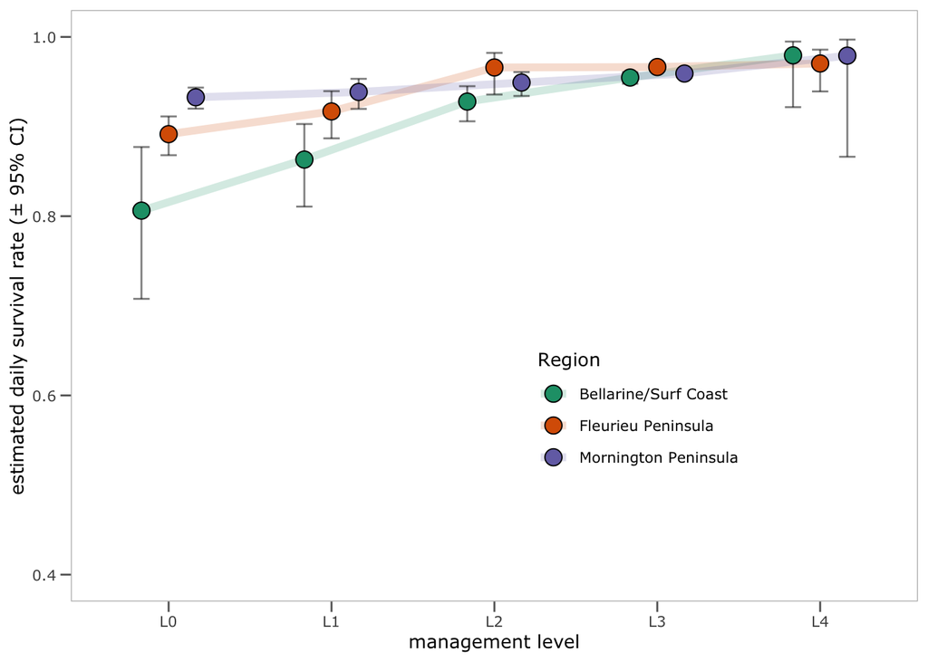

```r
nest_survival_reals_BSC_levels <-
  S.levels$results$real
Groups <- data.frame(
  str_split_fixed(rownames(nest_survival_reals_BSC_levels), " ", n = 4))
nest_survival_reals_BSC_levels <- cbind(Groups, nest_survival_reals_BSC_levels)
nest_survival_reals_BSC_levels$rows <-  rownames(nest_survival_reals_BSC_levels)
nest_survival_reals_BSC_levels$management_level <-
  as.factor(str_sub(nest_survival_reals_BSC_levels$rows,
                    nchar(nest_survival_reals_BSC_levels$rows) - 7, nchar(nest_survival_reals_BSC_levels$rows) - 6))
nest_survival_reals_BSC_levels <-
  nest_survival_reals_BSC_levels %>%
  dplyr::select(management_level, estimate, se, lcl, ucl) %>%
  mutate(region = "BSC")
row.names(nest_survival_reals_BSC_levels) <- NULL

nest_survival_reals_levels <-
  bind_rows(nest_survival_reals_FP_levels,
            nest_survival_reals_MP_levels,
            nest_survival_reals_BSC_levels)

ggplot() +
  geom_line(data = nest_survival_reals_levels,
            aes(x = management_level, y = estimate, color = region, group = region),
            position = position_dodge(width = 0.5), alpha = 0.2, size = 2) +
  geom_errorbar(data = nest_survival_reals_levels,
                aes(ymin = lcl, ymax = ucl,
                    x = management_level,
                    y = estimate, group = region), position = position_dodge(width = 0.5),
                alpha = 0.5, color = "black", width = 0.3, lwd = 0.5) +
  geom_point(data = nest_survival_reals_levels,
             aes(x = management_level, y = estimate, fill = region),
             shape = 21, size = 4, position = position_dodge(width = 0.5)) +
  scale_colour_brewer(palette = "Set1") +
  luke_theme +
  theme(legend.position = c(0.8, 0.2),
        legend.justification = c(1, 0),
        strip.background = element_blank()) +
  xlab("management level") +
  ylab("estimated daily survival rate (± 95% CI)") +
  ylim(c(0.4, 1)) +
  scale_colour_brewer(palette = "Dark2",
                      name = "Region",
                      labels = c("Bellarine/Surf Coast",
                        "Fleurieu Peninsula",
                      "Mornington Peninsula")) +
  scale_fill_brewer(palette = "Dark2",
                      name = "Region",
                      labels = c("Bellarine/Surf Coast",
                        "Fleurieu Peninsula",
                      "Mornington Peninsula"))
```

## Effect of management status on nest survival

```r
S.status <-
  mark(data = RMark_data_FP$nest_data.processed,
       ddl = RMark_data_FP$nest_fate.ddl,
       model = "Nest",
       model.parameters = list("S" = list(formula = ~ status)),
       brief = TRUE,
       delete = TRUE)
```

```
 Model: S(~status)  npar= 2  lnl =  2612.0143 AICc = 2616.0156
```

```r
nest_survival_reals_FP_status <-
  S.status$results$real
Groups <- data.frame(
  str_split_fixed(rownames(nest_survival_reals_FP_status), " ", n = 4))
nest_survival_reals_FP_status <- cbind(Groups, nest_survival_reals_FP_status)
nest_survival_reals_FP_status$rows <-  rownames(nest_survival_reals_FP_status)
nest_survival_reals_FP_status$status <-
  as.factor(str_sub(nest_survival_reals_FP_status$rows,
                    nchar(nest_survival_reals_FP_status$rows) - 8, nchar(nest_survival_reals_FP_status$rows) - 8))
nest_survival_reals_FP_status <-
  nest_survival_reals_FP_status %>%
  dplyr::select(status, estimate, se, lcl, ucl) %>%
  mutate(region = "FP")
row.names(nest_survival_reals_FP_status) <- NULL

S.status <-
  mark(data = RMark_data_MP$nest_data.processed,
       ddl = RMark_data_MP$nest_fate.ddl,
       model = "Nest",
       model.parameters = list("S" = list(formula =  ~ status)),
       brief = TRUE,
       delete = TRUE)
```

```
 Model: S(~status)  npar= 2  lnl =  3193.7097 AICc = 3197.7107
```

```r
nest_survival_reals_MP_status <-
  S.status$results$real
Groups <- data.frame(
  str_split_fixed(rownames(nest_survival_reals_MP_status), " ", n = 4))
nest_survival_reals_MP_status <- cbind(Groups, nest_survival_reals_MP_status)
nest_survival_reals_MP_status$rows <-  rownames(nest_survival_reals_MP_status)
nest_survival_reals_MP_status$status <-
  as.factor(str_sub(nest_survival_reals_MP_status$rows,
                    nchar(nest_survival_reals_MP_status$rows) - 8, nchar(nest_survival_reals_MP_status$rows) - 8))
nest_survival_reals_MP_status <-
  nest_survival_reals_MP_status %>%
  dplyr::select(status, estimate, se, lcl, ucl) %>%
  mutate(region = "MP")
row.names(nest_survival_reals_MP_status) <- NULL

S.status <-
  mark(data = RMark_data_BSC$nest_data.processed,
       ddl = RMark_data_BSC$nest_fate.ddl,
       model = "Nest",
       model.parameters = list("S" = list(formula =  ~ status)),
       brief = TRUE,
       delete = TRUE)
```

```
 Model: S(~status)  npar= 2  lnl =  1470.3078 AICc = 1474.3103
```

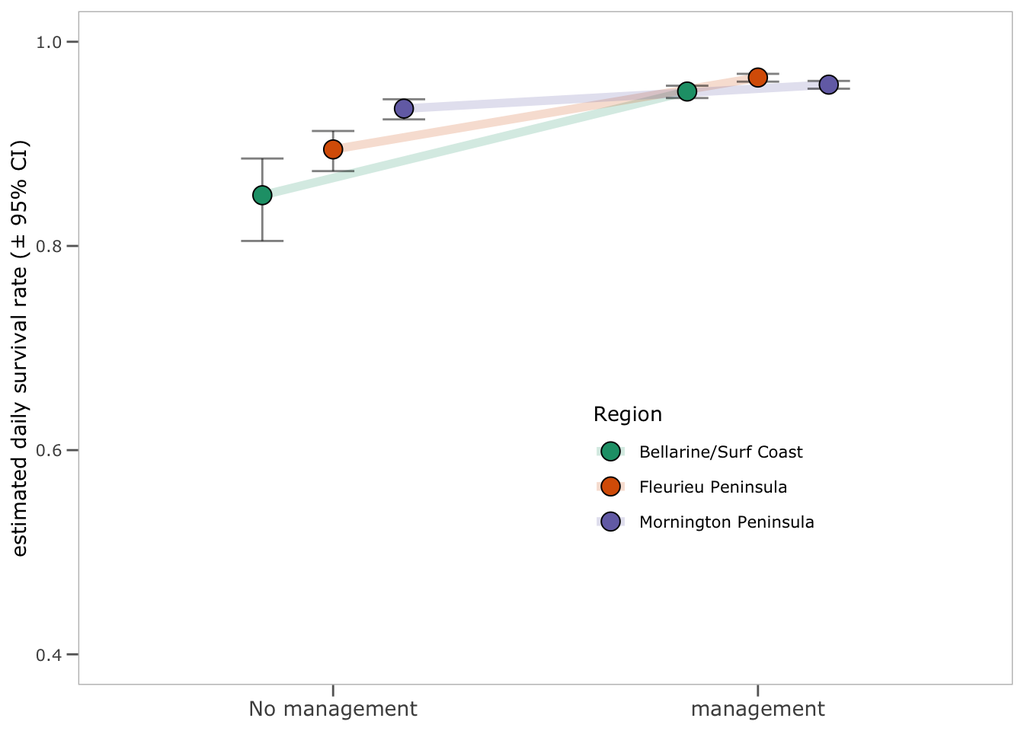

```r
nest_survival_reals_BSC_status <-
  S.status$results$real
Groups <- data.frame(
  str_split_fixed(rownames(nest_survival_reals_BSC_status), " ", n = 4))
nest_survival_reals_BSC_status <- cbind(Groups, nest_survival_reals_BSC_status)
nest_survival_reals_BSC_status$rows <-  rownames(nest_survival_reals_BSC_status)
nest_survival_reals_BSC_status$status <-
  as.factor(str_sub(nest_survival_reals_BSC_status$rows,
                    nchar(nest_survival_reals_BSC_status$rows) - 8, nchar(nest_survival_reals_BSC_status$rows) - 8))
nest_survival_reals_BSC_status <-
  nest_survival_reals_BSC_status %>%
  dplyr::select(status, estimate, se, lcl, ucl) %>%
  mutate(region = "BSC")
row.names(nest_survival_reals_BSC_status) <- NULL

nest_survival_reals_status <-
  bind_rows(nest_survival_reals_FP_status,
            nest_survival_reals_MP_status,
            nest_survival_reals_BSC_status)

ggplot() +
  geom_line(data = nest_survival_reals_status,
            aes(x = status, y = estimate, color = region, group = region),
            position = position_dodge(width = 0.5), alpha = 0.2, size = 2) +
  geom_errorbar(data = nest_survival_reals_status,
                aes(ymin = lcl, ymax = ucl,
                    x = status,
                    y = estimate, group = region), position = position_dodge(width = 0.5),
                alpha = 0.5, color = "black", width = 0.3, lwd = 0.5) +
  geom_point(data = nest_survival_reals_status,
             aes(x = status, y = estimate, fill = region),
             shape = 21, size = 4, position = position_dodge(width = 0.5)) +
  # scale_colour_brewer(palette = "Set1") +
  luke_theme +
  theme(legend.position = c(0.8, 0.2),
        legend.justification = c(1, 0),
        strip.background = element_blank(),
        axis.title.x = element_blank(),
        axis.text.x = element_text(size = 10)) +
  xlab("management level") +
  ylab("estimated daily survival rate (± 95% CI)") +
  ylim(c(0.4, 1)) +
  scale_colour_brewer(palette = "Dark2",
                      name = "Region",
                      labels = c("Bellarine/Surf Coast",
                        "Fleurieu Peninsula",
                      "Mornington Peninsula")) +
  scale_fill_brewer(palette = "Dark2",
                      name = "Region",
                      labels = c("Bellarine/Surf Coast",
                        "Fleurieu Peninsula",
                      "Mornington Peninsula")) +
  scale_x_discrete(labels = c("No management", "management"))
```

## Effect of Habitat on nest survival

```r
S.habitat <-
  mark(data = RMark_data_FP$nest_data.processed,
       ddl = RMark_data_FP$nest_fate.ddl,
       model = "Nest",
       model.parameters = list("S" = list(formula =  ~ nest_hab)),
       brief = TRUE,
       delete = TRUE)
```

```
 Model: S(~nest_hab)  npar= 4  lnl =  2689.2452 AICc = 2697.2495
```

```r
nest_survival_reals_FP_habitat <-
  S.habitat$results$real
Groups <- data.frame(
  str_split_fixed(rownames(nest_survival_reals_FP_habitat), " ", n = 4))
nest_survival_reals_FP_habitat <- cbind(Groups, nest_survival_reals_FP_habitat)
nest_survival_reals_FP_habitat$habitat <- str_extract(nest_survival_reals_FP_habitat$X2, "beach|dune|foredune/face|estuary/spit")
nest_survival_reals_FP_habitat <-
  nest_survival_reals_FP_habitat %>%
  dplyr::select(habitat, estimate, se, lcl, ucl) %>%
  mutate(region = "FP")
row.names(nest_survival_reals_FP_habitat) <- NULL

S.habitat <-
  mark(data = RMark_data_MP$nest_data.processed,
       ddl = RMark_data_MP$nest_fate.ddl,
       model = "Nest",
       model.parameters = list("S" = list(formula =  ~ nest_hab)),
       brief = TRUE,
       delete = TRUE)
```

```
 Model: S(~nest_hab)  npar= 3  lnl =  3207.8569 AICc = 3213.8589
```

```r
nest_survival_reals_MP_habitat <-
  S.habitat$results$real
Groups <- data.frame(
  str_split_fixed(rownames(nest_survival_reals_MP_habitat), " ", n = 4))
nest_survival_reals_MP_habitat <- cbind(Groups, nest_survival_reals_MP_habitat)
nest_survival_reals_MP_habitat$habitat <- str_extract(nest_survival_reals_MP_habitat$X2, "beach|dune|foredune/face|estuary/spit")
nest_survival_reals_MP_habitat <-
  nest_survival_reals_MP_habitat %>%
  dplyr::select(habitat, estimate, se, lcl, ucl) %>%
  mutate(region = "MP")
row.names(nest_survival_reals_MP_habitat) <- NULL

S.habitat <-
  mark(data = RMark_data_BSC$nest_data.processed,
       ddl = RMark_data_BSC$nest_fate.ddl,
       model = "Nest",
       model.parameters = list("S" = list(formula =  ~ nest_hab)),
       brief = TRUE,
       delete = TRUE)
```

```
 Model: S(~nest_hab)  npar= 4  lnl =  1797.2033 AICc = 1805.2117
```

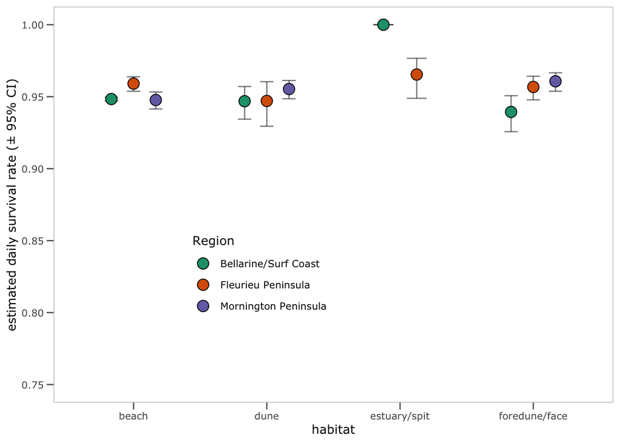

```r
nest_survival_reals_BSC_habitat <-
  S.habitat$results$real
Groups <- data.frame(
  str_split_fixed(rownames(nest_survival_reals_BSC_habitat), " ", n = 4))
nest_survival_reals_BSC_habitat <- cbind(Groups, nest_survival_reals_BSC_habitat)
nest_survival_reals_BSC_habitat$habitat <- str_extract(nest_survival_reals_BSC_habitat$X2, "beach|dune|foredune/face|estuary/spit")
nest_survival_reals_BSC_habitat <-
  nest_survival_reals_BSC_habitat %>%
  dplyr::select(habitat, estimate, se, lcl, ucl) %>%
  mutate(region = "BSC")
row.names(nest_survival_reals_BSC_habitat) <- NULL

nest_survival_reals_habitat <-
  bind_rows(nest_survival_reals_FP_habitat,
            nest_survival_reals_MP_habitat,
            nest_survival_reals_BSC_habitat)

ggplot() +
  geom_errorbar(data = nest_survival_reals_habitat,
                aes(ymin = lcl, ymax = ucl,
                    x = habitat,
                    y = estimate, group = region), position = position_dodge(width = 0.5),
                alpha = 0.5, color = "black", width = 0.3, lwd = 0.5) +
  geom_point(data = nest_survival_reals_habitat,
             aes(x = habitat, y = estimate, fill = region),
             shape = 21, size = 4, position = position_dodge(width = 0.5)) +
  # scale_colour_brewer(palette = "Set1") +
  luke_theme +
  theme(legend.position = c(0.5, 0.2),
        legend.justification = c(1, 0),
        strip.background = element_blank()) +
  xlab("habitat") +
  ylab("estimated daily survival rate (± 95% CI)") +
  ylim(c(0.75, 1)) +
  scale_colour_brewer(palette = "Dark2",
                      name = "Region",
                      labels = c("Bellarine/Surf Coast",
                        "Fleurieu Peninsula",
                      "Mornington Peninsula")) +
  scale_fill_brewer(palette = "Dark2",
                      name = "Region",
                      labels = c("Bellarine/Surf Coast",
                        "Fleurieu Peninsula",
                      "Mornington Peninsula"))
```

## Effect of dogs on nest survival (max counted)

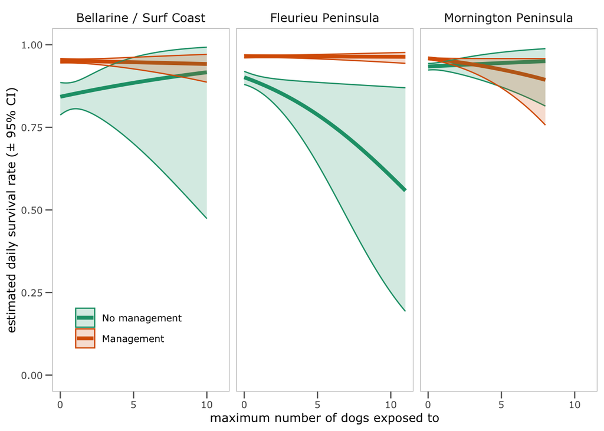

```r
S.dog_m <- nest_survival_run_FP[[4]]
min.dog_m = min(RMark_data_FP$nest_data.processed$data$dog_m)
max.dog_m = max(RMark_data_FP$nest_data.processed$data$dog_m)
dog_m.values = seq(from = min.dog_m, to = max.dog_m, length = 100)
pred.dog_m_status <-
  covariate.predictions(model = S.dog_m,
                        data = data.frame(dog_m = dog_m.values),
                        indices = c(as.numeric(row.names(filter(RMark_data_FP$nest_fate.ddl$S, status == "N")[1,])),
                                    as.numeric(row.names(filter(RMark_data_FP$nest_fate.ddl$S, status == "Y")[1,]))))
pred.dog_m_status_FP <-
  pred.dog_m_status$estimates %>%
  mutate(region = "FP",
         status = ifelse(par.index == 1, "N", "Y"))

S.dog_m <- nest_survival_run_MP[[4]]
min.dog_m = min(RMark_data_MP$nest_data.processed$data$dog_m)
max.dog_m = max(RMark_data_MP$nest_data.processed$data$dog_m)
dog_m.values = seq(from = min.dog_m, to = max.dog_m, length = 100)
pred.dog_m_status <-
  covariate.predictions(model = S.dog_m,
                        data = data.frame(dog_m = dog_m.values),
                        indices = c(as.numeric(row.names(filter(RMark_data_MP$nest_fate.ddl$S, status == "N")[1,])),
                                    as.numeric(row.names(filter(RMark_data_MP$nest_fate.ddl$S, status == "Y")[1,]))))
pred.dog_m_status_MP <-
  pred.dog_m_status$estimates %>%
  mutate(region = "MP",
         status = ifelse(par.index == 1, "N", "Y"))

S.dog_m <- nest_survival_run_BSC[[4]]
min.dog_m = min(RMark_data_BSC$nest_data.processed$data$dog_m)
max.dog_m = max(RMark_data_BSC$nest_data.processed$data$dog_m)
dog_m.values = seq(from = min.dog_m, to = max.dog_m, length = 100)
pred.dog_m_status <-
  covariate.predictions(model = S.dog_m,
                        data = data.frame(dog_m = dog_m.values),
                        indices = c(as.numeric(row.names(filter(RMark_data_BSC$nest_fate.ddl$S, status == "N")[1,])),
                                    as.numeric(row.names(filter(RMark_data_BSC$nest_fate.ddl$S, status == "Y")[1,]))))
pred.dog_m_status_BSC <-
  pred.dog_m_status$estimates %>%
  mutate(region = "BSC",
         status = ifelse(par.index == 1, "N", "Y"))

pred.dog_m <-
  bind_rows(pred.dog_m_status_FP,
            pred.dog_m_status_MP,
            pred.dog_m_status_BSC)

ggplot(pred.dog_m,
       aes(x = covdata, y = estimate, color = status, fill = status)) +
  geom_line(size = 1.5) +
  geom_ribbon(aes(ymin = lcl, ymax = ucl), alpha = 0.2) +
  scale_colour_brewer(palette = "Dark2",
                      labels = c("No management", "Management")) +
  scale_fill_brewer(palette = "Dark2",
                      labels = c("No management", "Management")) +
  scale_x_continuous(breaks = c(0, 5, 10, 15, 20, 25)) +
  luke_theme +
  theme(legend.position = c(0.25, 0.1),
        legend.title = element_blank(),
        legend.justification = c(1, 0),
        strip.background = element_blank()) +
  xlab("maximum number of dogs exposed to") +
  ylab("estimated daily survival rate (± 95% CI)") +
  ylim(c(0, 1)) +
  facet_grid(. ~ region, labeller = as_labeller(region_names))
```

## Effect of Dogs off leash on nest survival (max counted)

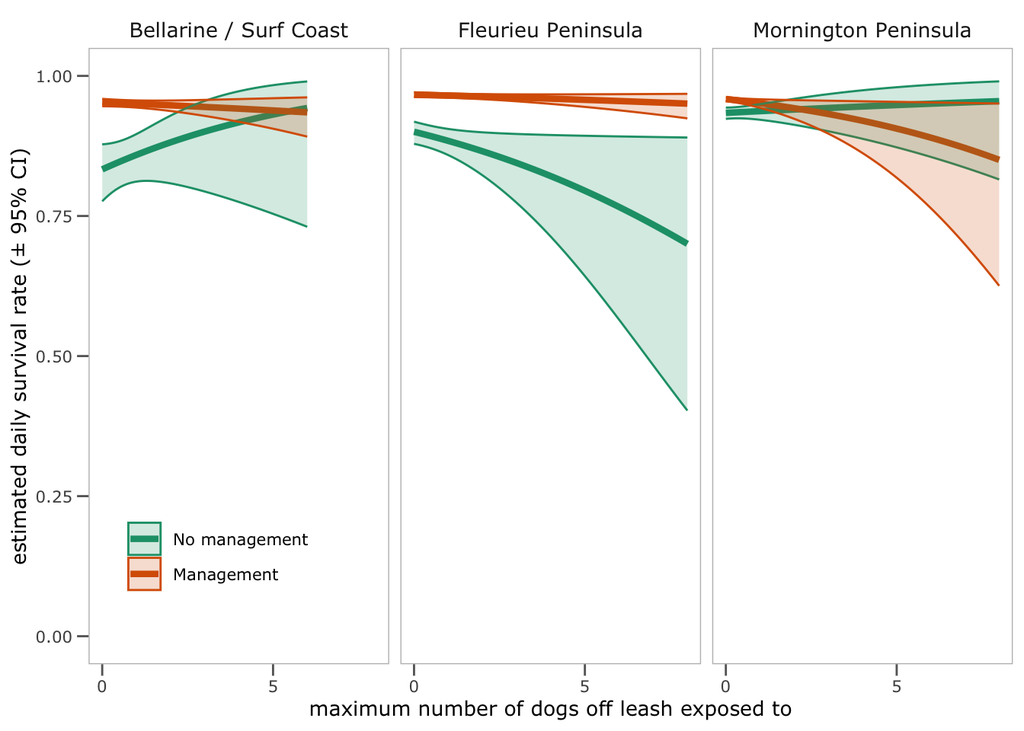

```r
S.dof_m <- nest_survival_run_FP[[2]]
min.dof_m = min(RMark_data_FP$nest_data.processed$data$dof_m)
max.dof_m = max(RMark_data_FP$nest_data.processed$data$dof_m)
dof_m.values = seq(from = min.dof_m, to = max.dof_m, length = 100)
pred.dof_m_status <-
  covariate.predictions(model = S.dof_m,
                        data = data.frame(dof_m = dof_m.values),
                        indices = c(as.numeric(row.names(filter(RMark_data_FP$nest_fate.ddl$S, status == "N")[1,])),
                                    as.numeric(row.names(filter(RMark_data_FP$nest_fate.ddl$S, status == "Y")[1,]))))
pred.dof_m_status_FP <-
  pred.dof_m_status$estimates %>%
  mutate(region = "FP",
         status = ifelse(par.index == 1, "N", "Y"))

S.dof_m <- nest_survival_run_MP[[2]]
min.dof_m = min(RMark_data_MP$nest_data.processed$data$dof_m)
max.dof_m = max(RMark_data_MP$nest_data.processed$data$dof_m)
dof_m.values = seq(from = min.dof_m, to = max.dof_m, length = 100)
pred.dof_m_status <-
  covariate.predictions(model = S.dof_m,
                        data = data.frame(dof_m = dof_m.values),
                        indices = c(as.numeric(row.names(filter(RMark_data_MP$nest_fate.ddl$S, status == "N")[1,])),
                                    as.numeric(row.names(filter(RMark_data_MP$nest_fate.ddl$S, status == "Y")[1,]))))
pred.dof_m_status_MP <-
  pred.dof_m_status$estimates %>%
  mutate(region = "MP",
         status = ifelse(par.index == 1, "N", "Y"))

S.dof_m <- nest_survival_run_BSC[[2]]
min.dof_m = min(RMark_data_BSC$nest_data.processed$data$dof_m)
max.dof_m = max(RMark_data_BSC$nest_data.processed$data$dof_m)
dof_m.values = seq(from = min.dof_m, to = max.dof_m, length = 100)
pred.dof_m_status <-
  covariate.predictions(model = S.dof_m,
                        data = data.frame(dof_m = dof_m.values),
                        indices = c(as.numeric(row.names(filter(RMark_data_BSC$nest_fate.ddl$S, status == "N")[1,])),
                                    as.numeric(row.names(filter(RMark_data_BSC$nest_fate.ddl$S, status == "Y")[1,]))))
pred.dof_m_status_BSC <-
  pred.dof_m_status$estimates %>%
  mutate(region = "BSC",
         status = ifelse(par.index == 1, "N", "Y"))

pred.dof_m <-
  bind_rows(pred.dof_m_status_FP,
            pred.dof_m_status_MP,
            pred.dof_m_status_BSC)

ggplot(pred.dof_m,
       aes(x = covdata, y = estimate, color = status, fill = status)) +
  geom_line(size = 1.5) +
  geom_ribbon(aes(ymin = lcl, ymax = ucl), alpha = 0.2) +
  scale_colour_brewer(palette = "Dark2",
                      labels = c("No management", "Management")) +
  scale_fill_brewer(palette = "Dark2",
                      labels = c("No management", "Management")) +
  scale_x_continuous(breaks = c(0, 5, 10, 15, 20, 25)) +
  luke_theme +
  theme(legend.position = c(0.25, 0.1),
        legend.title = element_blank(),
        legend.justification = c(1, 0),
        strip.background = element_blank()) +
  xlab("maximum number of dogs off leash exposed to") +
  ylab("estimated daily survival rate (± 95% CI)") +
  ylim(c(0, 1)) +
  facet_grid(. ~ region, labeller = as_labeller(region_names))
```

## Effect of humans on nest survival (max counted)

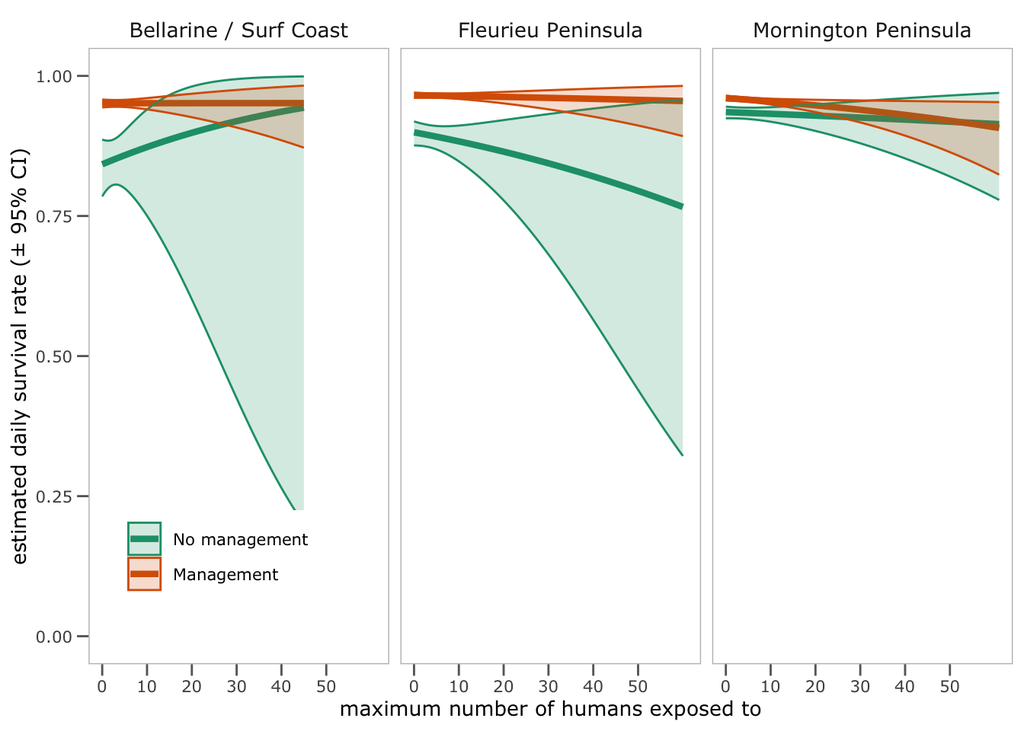

```r
S.hum_m <- nest_survival_run_FP[[9]]
min.hum_m = min(RMark_data_FP$nest_data.processed$data$hum_m)
max.hum_m = max(RMark_data_FP$nest_data.processed$data$hum_m)
hum_m.values = seq(from = min.hum_m, to = max.hum_m, length = 100)
pred.hum_m_status <-
  covariate.predictions(model = S.hum_m,
                        data = data.frame(hum_m = hum_m.values),
                        indices = c(as.numeric(row.names(filter(RMark_data_FP$nest_fate.ddl$S, status == "N")[1,])),
                                    as.numeric(row.names(filter(RMark_data_FP$nest_fate.ddl$S, status == "Y")[1,]))))
pred.hum_m_status_FP <-
  pred.hum_m_status$estimates %>%
  mutate(region = "FP",
         status = ifelse(par.index == 1, "N", "Y"))

S.hum_m <- nest_survival_run_MP[[9]]
min.hum_m = min(RMark_data_MP$nest_data.processed$data$hum_m)
max.hum_m = max(RMark_data_MP$nest_data.processed$data$hum_m)
hum_m.values = seq(from = min.hum_m, to = max.hum_m, length = 100)
pred.hum_m_status <-
  covariate.predictions(model = S.hum_m,
                        data = data.frame(hum_m = hum_m.values),
                        indices = c(as.numeric(row.names(filter(RMark_data_MP$nest_fate.ddl$S, status == "N")[1,])),
                                    as.numeric(row.names(filter(RMark_data_MP$nest_fate.ddl$S, status == "Y")[1,]))))
pred.hum_m_status_MP <-
  pred.hum_m_status$estimates %>%
  mutate(region = "MP",
         status = ifelse(par.index == 1, "N", "Y"))

S.hum_m <- nest_survival_run_BSC[[9]]
min.hum_m = min(RMark_data_BSC$nest_data.processed$data$hum_m)
max.hum_m = max(RMark_data_BSC$nest_data.processed$data$hum_m)
hum_m.values = seq(from = min.hum_m, to = max.hum_m, length = 100)
pred.hum_m_status <-
  covariate.predictions(model = S.hum_m,
                        data = data.frame(hum_m = hum_m.values),
                        indices = c(as.numeric(row.names(filter(RMark_data_BSC$nest_fate.ddl$S, status == "N")[1,])),
                                    as.numeric(row.names(filter(RMark_data_BSC$nest_fate.ddl$S, status == "Y")[1,]))))
pred.hum_m_status_BSC <-
  pred.hum_m_status$estimates %>%
  mutate(region = "BSC",
         status = ifelse(par.index == 1, "N", "Y"))

pred.hum_m <-
  bind_rows(pred.hum_m_status_FP,
            pred.hum_m_status_MP,
            pred.hum_m_status_BSC)

ggplot(pred.hum_m,
       aes(x = covdata, y = estimate, color = status, fill = status)) +
  geom_line(size = 1.5) +
  geom_ribbon(aes(ymin = lcl, ymax = ucl), alpha = 0.2) +
  scale_colour_brewer(palette = "Dark2",
                      labels = c("No management", "Management")) +
  scale_fill_brewer(palette = "Dark2",
                      labels = c("No management", "Management")) +
  scale_x_continuous(breaks = c(0, 10, 20, 30, 40, 50)) +
  luke_theme +
  theme(legend.position = c(0.25, 0.1),
        legend.title = element_blank(),
        legend.justification = c(1, 0),
        strip.background = element_blank()) +
  xlab("maximum number of humans exposed to") +
  ylab("estimated daily survival rate (± 95% CI)") +
  ylim(c(0, 1)) +
  facet_grid(. ~ region, labeller = as_labeller(region_names))
```

## Effect of corvids on nest survival (max counted)

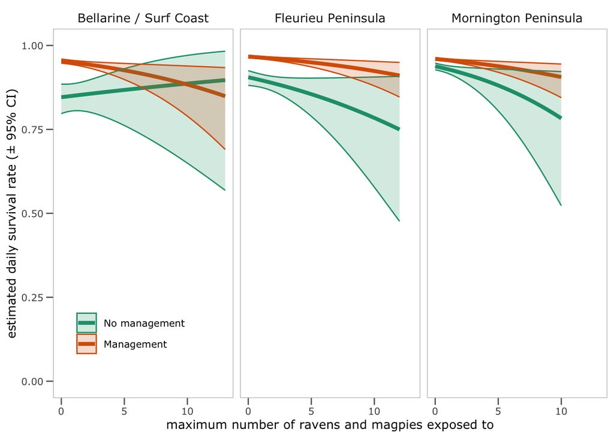

```r
S.pbd_m <- nest_survival_run_FP[[11]]
min.pbd_m = min(RMark_data_FP$nest_data.processed$data$pbd_m)
max.pbd_m = max(RMark_data_FP$nest_data.processed$data$pbd_m)
pbd_m.values = seq(from = min.pbd_m, to = max.pbd_m, length = 100)
pred.pbd_m_status <-
  covariate.predictions(model = S.pbd_m,
                        data = data.frame(pbd_m = pbd_m.values),
                        indices = c(as.numeric(row.names(filter(RMark_data_FP$nest_fate.ddl$S, status == "N")[1,])),
                                    as.numeric(row.names(filter(RMark_data_FP$nest_fate.ddl$S, status == "Y")[1,]))))
pred.pbd_m_status_FP <-
  pred.pbd_m_status$estimates %>%
  mutate(region = "FP",
         status = ifelse(par.index == 1, "N", "Y"))

S.pbd_m <- nest_survival_run_MP[[11]]
min.pbd_m = min(RMark_data_MP$nest_data.processed$data$pbd_m)
max.pbd_m = max(RMark_data_MP$nest_data.processed$data$pbd_m)
pbd_m.values = seq(from = min.pbd_m, to = max.pbd_m, length = 100)
pred.pbd_m_status <-
  covariate.predictions(model = S.pbd_m,
                        data = data.frame(pbd_m = pbd_m.values),
                        indices = c(as.numeric(row.names(filter(RMark_data_MP$nest_fate.ddl$S, status == "N")[1,])),
                                    as.numeric(row.names(filter(RMark_data_MP$nest_fate.ddl$S, status == "Y")[1,]))))
pred.pbd_m_status_MP <-
  pred.pbd_m_status$estimates %>%
  mutate(region = "MP",
         status = ifelse(par.index == 1, "N", "Y"))

S.pbd_m <- nest_survival_run_BSC[[11]]
min.pbd_m = min(RMark_data_BSC$nest_data.processed$data$pbd_m)
max.pbd_m = max(RMark_data_BSC$nest_data.processed$data$pbd_m)
pbd_m.values = seq(from = min.pbd_m, to = max.pbd_m, length = 100)
pred.pbd_m_status <-
  covariate.predictions(model = S.pbd_m,
                        data = data.frame(pbd_m = pbd_m.values),
                        indices = c(as.numeric(row.names(filter(RMark_data_BSC$nest_fate.ddl$S, status == "N")[1,])),
                                    as.numeric(row.names(filter(RMark_data_BSC$nest_fate.ddl$S, status == "Y")[1,]))))
pred.pbd_m_status_BSC <-
  pred.pbd_m_status$estimates %>%
  mutate(region = "BSC",
         status = ifelse(par.index == 1, "N", "Y"))

pred.pbd_m <-
  bind_rows(pred.pbd_m_status_FP,
            pred.pbd_m_status_MP,
            pred.pbd_m_status_BSC)

ggplot(pred.pbd_m,
       aes(x = covdata, y = estimate, color = status, fill = status)) +
  geom_line(size = 1.5) +
  geom_ribbon(aes(ymin = lcl, ymax = ucl), alpha = 0.2) +
  scale_colour_brewer(palette = "Dark2",
                      labels = c("No management", "Management")) +
  scale_fill_brewer(palette = "Dark2",
                      labels = c("No management", "Management")) +
  scale_x_continuous(breaks = c(0, 5, 10, 15, 20, 25)) +
  luke_theme +
  theme(legend.position = c(0.25, 0.1),
        legend.title = element_blank(),
        legend.justification = c(1, 0),
        strip.background = element_blank()) +
  xlab("maximum number of ravens and magpies exposed to") +
  ylab("estimated daily survival rate (± 95% CI)") +
  ylim(c(0, 1)) +
  facet_grid(. ~ region, labeller = as_labeller(region_names))
```

## Effect of gulls on nest survival (max counted)

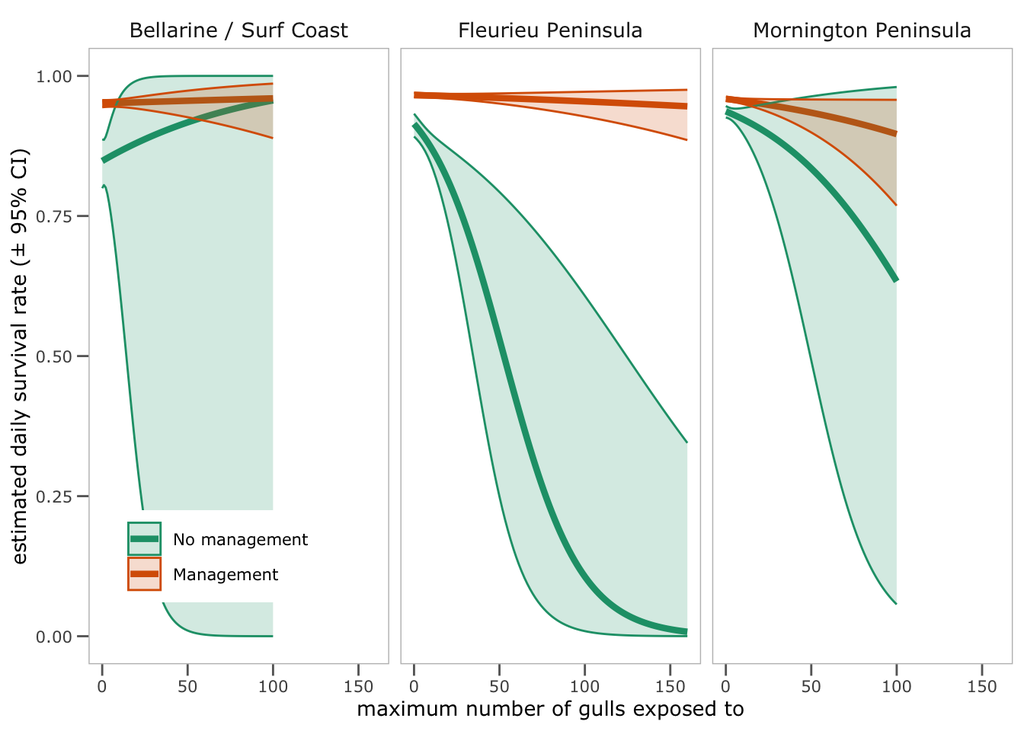

```r
S.gul_m <- nest_survival_run_FP[[7]]
min.gul_m = min(RMark_data_FP$nest_data.processed$data$gul_m)
max.gul_m = max(RMark_data_FP$nest_data.processed$data$gul_m)
gul_m.values = seq(from = min.gul_m, to = max.gul_m, length = 100)
pred.gul_m_status <-
  covariate.predictions(model = S.gul_m,
                        data = data.frame(gul_m = gul_m.values),
                        indices = c(as.numeric(row.names(filter(RMark_data_FP$nest_fate.ddl$S, status == "N")[1,])),
                                    as.numeric(row.names(filter(RMark_data_FP$nest_fate.ddl$S, status == "Y")[1,]))))
pred.gul_m_status_FP <-
  pred.gul_m_status$estimates %>%
  mutate(region = "FP",
         status = ifelse(par.index == 1, "N", "Y"))

S.gul_m <- nest_survival_run_MP[[7]]
min.gul_m = min(RMark_data_MP$nest_data.processed$data$gul_m)
max.gul_m = max(RMark_data_MP$nest_data.processed$data$gul_m)
gul_m.values = seq(from = min.gul_m, to = max.gul_m, length = 100)
pred.gul_m_status <-
  covariate.predictions(model = S.gul_m,
                        data = data.frame(gul_m = gul_m.values),
                        indices = c(as.numeric(row.names(filter(RMark_data_MP$nest_fate.ddl$S, status == "N")[1,])),
                                    as.numeric(row.names(filter(RMark_data_MP$nest_fate.ddl$S, status == "Y")[1,]))))
pred.gul_m_status_MP <-
  pred.gul_m_status$estimates %>%
  mutate(region = "MP",
         status = ifelse(par.index == 1, "N", "Y"))

S.gul_m <- nest_survival_run_BSC[[7]]
min.gul_m = min(RMark_data_BSC$nest_data.processed$data$gul_m)
max.gul_m = max(RMark_data_BSC$nest_data.processed$data$gul_m)
gul_m.values = seq(from = min.gul_m, to = max.gul_m, length = 100)
pred.gul_m_status <-
  covariate.predictions(model = S.gul_m,
                        data = data.frame(gul_m = gul_m.values),
                        indices = c(as.numeric(row.names(filter(RMark_data_BSC$nest_fate.ddl$S, status == "N")[1,])),
                                    as.numeric(row.names(filter(RMark_data_BSC$nest_fate.ddl$S, status == "Y")[1,]))))
pred.gul_m_status_BSC <-
  pred.gul_m_status$estimates %>%
  mutate(region = "BSC",
         status = ifelse(par.index == 1, "N", "Y"))

pred.gul_m <-
  bind_rows(pred.gul_m_status_FP,
            pred.gul_m_status_MP,
            pred.gul_m_status_BSC)

ggplot(pred.gul_m,
       aes(x = covdata, y = estimate, color = status, fill = status)) +
  geom_line(size = 1.5) +
  geom_ribbon(aes(ymin = lcl, ymax = ucl), alpha = 0.2) +
  scale_colour_brewer(palette = "Dark2",
                      labels = c("No management", "Management")) +
  scale_fill_brewer(palette = "Dark2",
                      labels = c("No management", "Management")) +
  # scale_x_continuous(breaks = c(0, 10, 20, 30, 40, 50, 60, 70)) +
  luke_theme +
  theme(legend.position = c(0.25, 0.1),
        legend.title = element_blank(),
        legend.justification = c(1, 0),
        strip.background = element_blank()) +
  xlab("maximum number of gulls exposed to") +
  ylab("estimated daily survival rate (± 95% CI)") +
  ylim(c(0, 1)) +
  facet_grid(. ~ region, labeller = as_labeller(region_names))
```

## Effect of Fox activity on nest survival (max print level) (NOT RUN IN MODELS)

```r
# S.fox_prints <-
#   mark(data = RMark_data_FP$nest_data.processed,
#        ddl = RMark_data_FP$nest_fate.ddl,
#        model = "Nest",
#        model.parameters = list("S" = list(formula =  ~ fox_p)),
#        brief = TRUE,
#        delete = TRUE)
# nest_survival_reals_FP_fox_p <-
#   S.fox_prints$results$real
# Groups <- data.frame(
#   str_split_fixed(rownames(nest_survival_reals_FP_fox_p), " ", n = 4))
# nest_survival_reals_FP_fox_p <- cbind(Groups, nest_survival_reals_FP_fox_p)
# nest_survival_reals_FP_fox_p$rows <-  rownames(nest_survival_reals_FP_fox_p)
# nest_survival_reals_FP_fox_p$fox_p <-
#   str_sub(nest_survival_reals_FP_fox_p$rows,
#           nchar(nest_survival_reals_FP_fox_p$rows) - 6,
#           nchar(nest_survival_reals_FP_fox_p$rows) - 6)
# nest_survival_reals_FP_fox_p$fox_p <-
#   as.factor(nest_survival_reals_FP_fox_p$fox_p)
# nest_survival_reals_FP_fox_p <-
#   nest_survival_reals_FP_fox_p %>%
#   dplyr::select(fox_p, estimate, se, lcl, ucl) %>%
#   mutate(region = "FP") %>%
#   slice(-1)
# row.names(nest_survival_reals_FP_fox_p) <- NULL
#
# S.fox_prints <-
#   mark(data = RMark_data_MP$nest_data.processed,
#        ddl = RMark_data_MP$nest_fate.ddl,
#        model = "Nest",
#        model.parameters = list("S" = list(formula =  ~ fox_p)),
#        brief = TRUE,
#        delete = TRUE)
# nest_survival_reals_MP_fox_p <-
#   S.fox_prints$results$real
# Groups <- data.frame(
#   str_split_fixed(rownames(nest_survival_reals_MP_fox_p), " ", n = 4))
# nest_survival_reals_MP_fox_p <- cbind(Groups, nest_survival_reals_MP_fox_p)
# nest_survival_reals_MP_fox_p$rows <-  rownames(nest_survival_reals_MP_fox_p)
# nest_survival_reals_MP_fox_p$fox_p <-
#   str_sub(nest_survival_reals_MP_fox_p$rows,
#           nchar(nest_survival_reals_MP_fox_p$rows) - 6,
#           nchar(nest_survival_reals_MP_fox_p$rows) - 6)
# nest_survival_reals_MP_fox_p$fox_p <-
#   as.factor(nest_survival_reals_MP_fox_p$fox_p)
# nest_survival_reals_MP_fox_p <-
#   nest_survival_reals_MP_fox_p %>%
#   dplyr::select(fox_p, estimate, se, lcl, ucl) %>%
#   mutate(region = "MP") %>%
#   slice(-1)
# row.names(nest_survival_reals_MP_fox_p) <- NULL
#
# S.fox_prints <-
#   mark(data = RMark_data_BSC$nest_data.processed,
#        ddl = RMark_data_BSC$nest_fate.ddl,
#        model = "Nest",
#        model.parameters = list("S" = list(formula =  ~ fox_p)),
#        brief = TRUE,
#        delete = TRUE)
# nest_survival_reals_BSC_fox_p <-
#   S.fox_prints$results$real
# Groups <- data.frame(
#   str_split_fixed(rownames(nest_survival_reals_BSC_fox_p), " ", n = 4))
# nest_survival_reals_BSC_fox_p <- cbind(Groups, nest_survival_reals_BSC_fox_p)
# nest_survival_reals_BSC_fox_p$rows <-  rownames(nest_survival_reals_BSC_fox_p)
# nest_survival_reals_BSC_fox_p$fox_p <-
#   str_sub(nest_survival_reals_BSC_fox_p$rows,
#           nchar(nest_survival_reals_BSC_fox_p$rows) - 6,
#           nchar(nest_survival_reals_BSC_fox_p$rows) - 6) %>% as.factor()
# nest_survival_reals_BSC_fox_p <-
#   nest_survival_reals_BSC_fox_p %>%
#   dplyr::select(fox_p, estimate, se, lcl, ucl) %>%
#   mutate(region = "BSC") %>%
#   slice(-1)
# row.names(nest_survival_reals_BSC_fox_p) <- NULL
#
# nest_survival_reals_levels <-
#   bind_rows(nest_survival_reals_FP_fox_p,
#             nest_survival_reals_MP_fox_p,
#             nest_survival_reals_BSC_fox_p)
#
# ggplot() +
#   geom_line(data = nest_survival_reals_levels,
#             aes(x = fox_p, y = estimate, color = region, group = region),
#             position = position_dodge(width = 0.5), alpha = 0.2, size = 2) +
#   geom_errorbar(data = nest_survival_reals_levels,
#                 aes(ymin = lcl, ymax = ucl,
#                     x = fox_p,
#                     y = estimate, group = region), position = position_dodge(width = 0.5),
#                 alpha = 0.5, color = "black", width = 0.3, lwd = 0.5) +
#   geom_point(data = nest_survival_reals_levels,
#              aes(x = fox_p, y = estimate, fill = region),
#              shape = 21, size = 4, position = position_dodge(width = 0.5)) +
#   luke_theme +
#   theme(legend.position = c(0.9, 0.1),
#         legend.justification = c(1, 0),
#         strip.background = element_blank()) +
#   xlab("fox prints") +
#   ylab("estimated daily survival rate (± 95% CI)") +
#   ylim(c(0.55, 1)) +
#   scale_colour_brewer(palette = "Dark2",
#                       name = "Region",
#                       labels = #c("Bellarine/Surf Coast",
#                         # "Fleurieu Peninsula",
#                       "Mornington Peninsula") +#) +
#   scale_fill_brewer(palette = "Dark2",
#                       name = "Region",
#                       labels = #c("Bellarine/Surf Coast",
#                         # "Fleurieu Peninsula",
#                       "Mornington Peninsula")
```

## Effect of vehicles on nest survival (max)

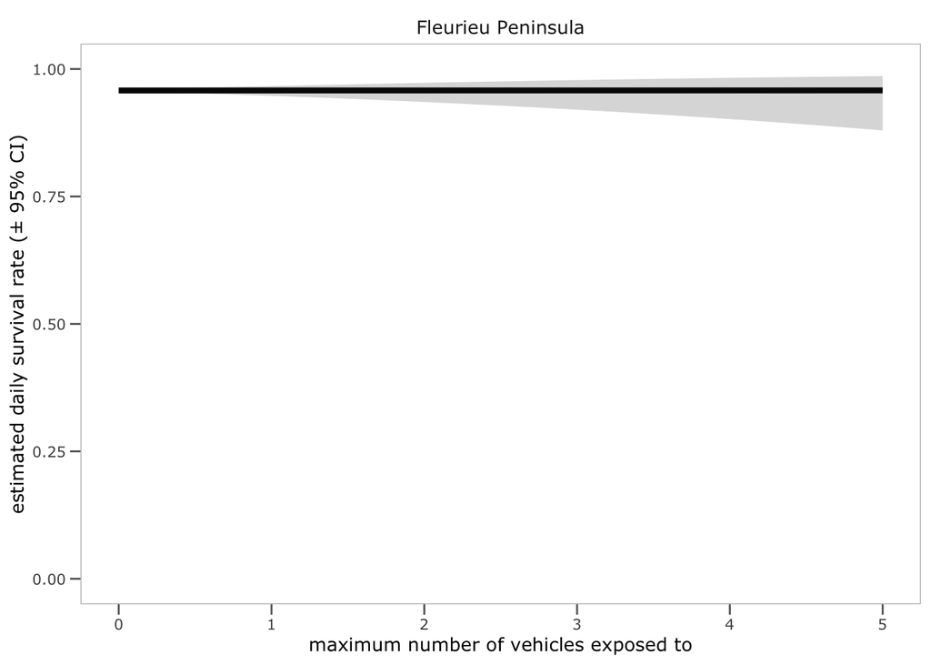

```r
S.veh_m <- nest_survival_run_FP[[12]]
min.veh_m = min(RMark_data_FP$nest_data.processed$data$veh_m)
max.veh_m = max(RMark_data_FP$nest_data.processed$data$veh_m)
veh_m.values = seq(from = min.veh_m, to = max.veh_m, length = 100)
pred.veh_m_status <-
  covariate.predictions(model = S.veh_m,
                        data = data.frame(veh_m = veh_m.values),
                        indices = c(as.numeric(row.names(filter(RMark_data_FP$nest_fate.ddl$S, status == "N")[1,]))))
pred.veh_m_status_FP <-
  pred.veh_m_status$estimates %>%
  mutate(region = "FP")

# S.veh_m <- nest_survival_run_MP[[13]]
# min.veh_m = min(RMark_data_MP$nest_data.processed$data$veh_m)
# max.veh_m = max(RMark_data_MP$nest_data.processed$data$veh_m)
# veh_m.values = seq(from = min.veh_m, to = max.veh_m, length = 100)
# pred.veh_m_status <-
#   covariate.predictions(model = S.veh_m,
#                         data = data.frame(veh_m = veh_m.values),
#                         indices = c(as.numeric(row.names(filter(RMark_data_MP$nest_fate.ddl$S, status == "N")[1,]))))
# pred.veh_m_status_MP <-
#   pred.veh_m_status$estimates %>%
#   mutate(region = "MP")
#
# S.veh_m <- nest_survival_run_BSC[[13]]
# min.veh_m = min(RMark_data_BSC$nest_data.processed$data$veh_m)
# max.veh_m = max(RMark_data_BSC$nest_data.processed$data$veh_m)
# veh_m.values = seq(from = min.veh_m, to = max.veh_m, length = 100)
# pred.veh_m_status <-
#   covariate.predictions(model = S.veh_m,
#                         data = data.frame(veh_m = veh_m.values),
#                         indices = c(as.numeric(row.names(filter(RMark_data_BSC$nest_fate.ddl$S, status == "N")[1,]))))
# pred.veh_m_status_BSC <-
#   pred.veh_m_status$estimates %>%
#   mutate(region = "BSC")
#
# pred.veh_m <-
#   bind_rows(pred.veh_m_status_FP, pred.veh_m_status_MP, pred.veh_m_status_BSC)

ggplot(pred.veh_m_status_FP,
       aes(x = covdata, y = estimate)) +
  geom_line(size = 1.5) +
  geom_ribbon(aes(ymin = lcl, ymax = ucl), alpha = 0.2) +
  scale_colour_brewer(palette = "Dark2",
                      labels = c("No management", "Management")) +
  scale_fill_brewer(palette = "Dark2",
                      labels = c("No management", "Management")) +
  scale_x_continuous(breaks = c(0, 1, 2, 3, 4, 5)) +
  luke_theme +
  theme(legend.position = c(0.25, 0.1),
        legend.title = element_blank(),
        legend.justification = c(1, 0),
        strip.background = element_blank()) +
  xlab("maximum number of vehicles exposed to") +
  ylab("estimated daily survival rate (± 95% CI)") +
  ylim(c(0, 1)) +
  facet_grid(. ~ region, labeller = as_labeller(region_names))
```

## Annual variation in nest survival

```r
S.year <-
  mark(data = RMark_data_FP$nest_data.processed,
       ddl = RMark_data_FP$nest_fate.ddl,
       model = "Nest",
       model.parameters = list("S" = list(formula =  ~ season)),
       brief = TRUE,
       delete = TRUE)
```

```
 Model: S(~season)  npar= 16  lnl =  2682.4887 AICc = 2714.54664631444
```

```r
nest_survival_reals_FP_year <-
  S.year$results$real
Groups <- data.frame(
  str_split_fixed(rownames(nest_survival_reals_FP_year), " ", n = 4))
nest_survival_reals_FP_year <- cbind(Groups, nest_survival_reals_FP_year)
nest_survival_reals_FP_year$season <-
  as.numeric(str_sub(nest_survival_reals_FP_year$X2, 2, 5))
nest_survival_reals_FP_year$season <- paste(nest_survival_reals_FP_year$season, nest_survival_reals_FP_year$season + 1, sep = " - ")
nest_survival_reals_FP_year <-
  nest_survival_reals_FP_year %>%
  dplyr::select(season, estimate, se, lcl, ucl) %>%
  mutate(region = "FP")
row.names(nest_survival_reals_FP_year) <- NULL

S.year <-
  mark(data = RMark_data_MP$nest_data.processed,
       ddl = RMark_data_MP$nest_fate.ddl,
       model = "Nest",
       model.parameters = list("S" = list(formula =  ~ season)),
       brief = TRUE,
       delete = TRUE)
```

```
 Model: S(~season)  npar= 18  lnl =  3202.1658 AICc = 3238.223
```

```r
nest_survival_reals_MP_year <-
  S.year$results$real
Groups <- data.frame(
  str_split_fixed(rownames(nest_survival_reals_MP_year), " ", n = 4))
nest_survival_reals_MP_year <- cbind(Groups, nest_survival_reals_MP_year)
nest_survival_reals_MP_year$season <-
  as.numeric(str_sub(nest_survival_reals_MP_year$X2, 2, 5))
nest_survival_reals_MP_year$season <- paste(nest_survival_reals_MP_year$season, nest_survival_reals_MP_year$season + 1, sep = " - ")
nest_survival_reals_MP_year <-
  nest_survival_reals_MP_year %>%
  dplyr::select(season, estimate, se, lcl, ucl) %>%
  mutate(region = "MP")
row.names(nest_survival_reals_MP_year) <- NULL

S.year <-
  mark(data = RMark_data_BSC$nest_data.processed,
       ddl = RMark_data_BSC$nest_fate.ddl,
       model = "Nest",
       model.parameters = list("S" = list(formula =  ~ season)),
       brief = TRUE,
       delete = TRUE)
```

```
 Model: S(~season)  npar= 18  lnl =  1483.0428 AICc = 1519.18649747899
```

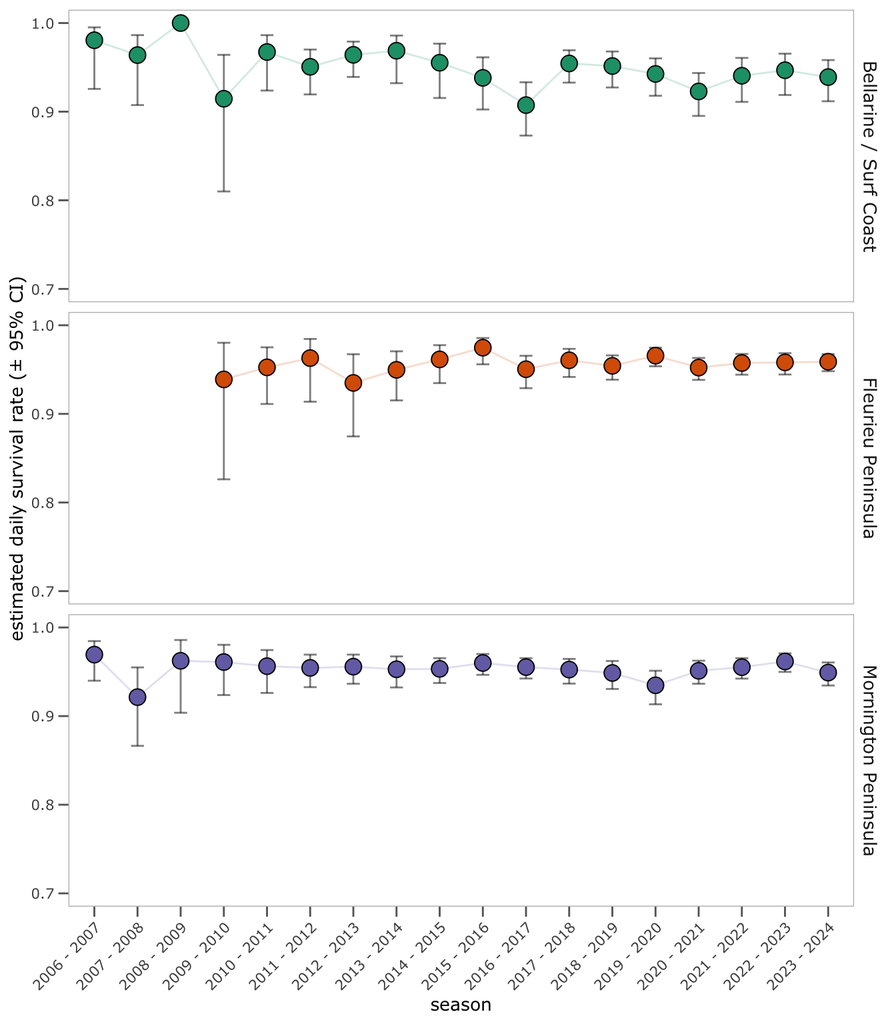

```r
nest_survival_reals_BSC_year <-
  S.year$results$real
Groups <- data.frame(
  str_split_fixed(rownames(nest_survival_reals_BSC_year), " ", n = 4))
nest_survival_reals_BSC_year <- cbind(Groups, nest_survival_reals_BSC_year)
nest_survival_reals_BSC_year$season <-
  as.numeric(str_sub(nest_survival_reals_BSC_year$X2, 2, 5))
nest_survival_reals_BSC_year$season <- paste(nest_survival_reals_BSC_year$season, nest_survival_reals_BSC_year$season + 1, sep = " - ")
nest_survival_reals_BSC_year <-
  nest_survival_reals_BSC_year %>%
  dplyr::select(season, estimate, se, lcl, ucl) %>%
  mutate(region = "BSC")
row.names(nest_survival_reals_BSC_year) <- NULL

nest_survival_reals_year <-
  bind_rows(nest_survival_reals_FP_year,
            nest_survival_reals_MP_year,
            nest_survival_reals_BSC_year)

ggplot() +
  geom_line(data = nest_survival_reals_year,
            aes(x = season, y = estimate, color = region, group = region),
            position = position_dodge(width = 0.5), alpha = 0.2) +
  geom_errorbar(data = nest_survival_reals_year,
                aes(ymin = lcl, ymax = ucl,
                    x = season,
                    y = estimate, group = region), position = position_dodge(width = 0.5),
                alpha = 0.5, color = "black", width = 0.3, lwd = 0.5) +
  geom_point(data = nest_survival_reals_year,
             aes(x = season, y = estimate, fill = region),
             shape = 21, size = 4, position = position_dodge(width = 0.5)) +
  scale_colour_brewer(palette = "Set1") +
  luke_theme +
  theme(legend.position = "none",
        legend.justification = c(1, 0),
        strip.background = element_blank(),
        axis.text.x = element_text(angle = 45, hjust = 1, vjust = 1)) +
  xlab("season") +
  ylab("estimated daily survival rate (± 95% CI)") +
  ylim(c(0.7, 1)) +
  scale_colour_brewer(palette = "Dark2") +
  scale_fill_brewer(palette = "Dark2") +
  facet_grid(region ~ ., labeller = as_labeller(region_names))
```

## Variation within years

```r
# Extract estimates of survival from Cubic model with management
# (non-linear season variation and management effect)
S.season <-
  mark(data = RMark_data_MP$nest_data.processed,
       ddl = RMark_data_MP$nest_fate.ddl,
       model = "Nest",
       model.parameters = list("S" = list(formula =  ~ Time + Quadratic + Cubic)),
       brief = TRUE,
       delete = TRUE)
```

```
 Model: S(~Time + Quadratic + Cubic)  npar= 4  lnl =  3200.3665 AICc = 3208.36984336342
```

```r
nest_survival_reals_MP_season <-
  S.season$results$real
Groups <- data.frame(
  str_split_fixed(rownames(nest_survival_reals_MP_season), " ", n = 4))
nest_survival_reals_MP_season <- cbind(Groups, nest_survival_reals_MP_season)
nest_survival_reals_MP_season$day_of_season <-
  unlist(str_extract_all(nest_survival_reals_MP_season$X4, "\\d+")) %>% unique() %>% as.numeric()
nest_survival_reals_MP_season$region = "MP"

S.season <-
  mark(data = RMark_data_BSC$nest_data.processed,
       ddl = RMark_data_BSC$nest_fate.ddl,
       model = "Nest",
       model.parameters = list("S" = list(formula =  ~ Time + Quadratic + Cubic)),
       brief = TRUE,
       delete = TRUE)
```

```
 Model: S(~Time + Quadratic + Cubic)  npar= 4  lnl =  1487.8666 AICc = 1495.875
```

```r
nest_survival_reals_BSC_season <-
  S.season$results$real
Groups <- data.frame(
  str_split_fixed(rownames(nest_survival_reals_BSC_season), " ", n = 4))
nest_survival_reals_BSC_season <- cbind(Groups, nest_survival_reals_BSC_season)
nest_survival_reals_BSC_season$day_of_season <-
  unlist(str_extract_all(nest_survival_reals_BSC_season$X4, "\\d+")) %>% unique() %>% as.numeric()
nest_survival_reals_BSC_season$region = "BSC"

S.season <-
  mark(data = RMark_data_FP$nest_data.processed,
       ddl = RMark_data_FP$nest_fate.ddl,
       model = "Nest",
       model.parameters = list("S" = list(formula =  ~ Time + Quadratic + Cubic)),
       brief = TRUE,
       delete = TRUE)
```

```
 Model: S(~Time + Quadratic + Cubic)  npar= 4  lnl =  2689.0765 AICc = 2697.0808
```

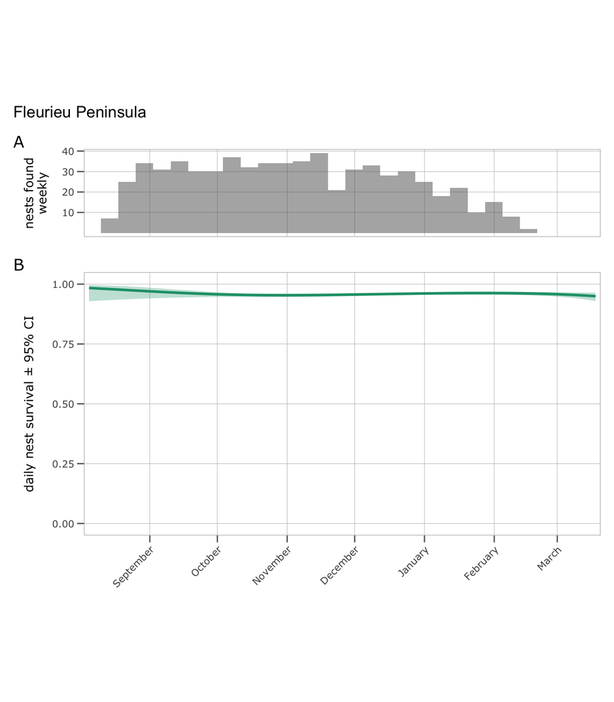

```r
nest_survival_reals_FP_season <-
  S.season$results$real
Groups <- data.frame(
  str_split_fixed(rownames(nest_survival_reals_FP_season), " ", n = 4))
nest_survival_reals_FP_season <- cbind(Groups, nest_survival_reals_FP_season)
nest_survival_reals_FP_season$day_of_season <-
  unlist(str_extract_all(nest_survival_reals_FP_season$X4, "\\d+")) %>% unique() %>% as.numeric()
nest_survival_reals_FP_season$region = "FP"

nest_survival_reals_season <-
  bind_rows(
    nest_survival_reals_MP_season,
            nest_survival_reals_BSC_season,
            nest_survival_reals_FP_season) %>%
  dplyr::select(region, day_of_season, estimate, lcl, ucl)
row.names(nest_survival_reals_season) <- NULL

# FP
dates_for_plot_FP <-
  data.frame(date = as.Date(min(as.numeric(RMark_data_FP$nest_data.processed$data$FirstFound)):
                              max(max(as.numeric(RMark_data_FP$nest_data.processed$data$LastChecked)),
                                  max(as.numeric(RMark_data_FP$nest_data.processed$data$LastPresent))),
                            origin = "2023-01-01") - 180,
             day_of_season = c(0:(max(max(as.numeric(RMark_data_FP$nest_data.processed$data$LastChecked)),
                                      max(as.numeric(RMark_data_FP$nest_data.processed$data$LastPresent))) -
                                    min(as.numeric(RMark_data_FP$nest_data.processed$data$FirstFound)))))

nest_survival_reals_dates_FP <-
  left_join(nest_survival_reals_FP_season, dates_for_plot_FP, by = "day_of_season")

nest_survival_season_plot_FP <-
  ggplot(data = nest_survival_reals_dates_FP) +
  geom_ribbon(aes(x = date, ymin = lcl, ymax = ucl),
              fill = brewer.pal(8, "Dark2")[c(1)],
              alpha = 0.3) +
  geom_line(aes(x = date, y = estimate),
            color = brewer.pal(8, "Dark2")[c(1)],
            size = 1) +
  scale_x_date(date_labels = "%B",
               expand = c(0.01, 0.01),
               date_breaks = "1 months") +
  ylab("daily nest survival ± 95% CI") +
  scale_y_continuous(limits = c(0, 1)) +
  luke_theme +
  theme(legend.position = "bottom",
        legend.title = element_blank(),
        panel.grid.major = element_line(colour = "grey70",
                                        size = 0.15),
        axis.title.x = element_blank(),
        axis.text.x = element_text(angle = 45,
                                   hjust = 1,
                                   vjust = 1))

nest_discovery_season_plot_FP <-
      ggplot(RMark_data_FP$nest_data.processed$data,
             aes(as.Date(FirstFound, origin = "2023-01-01") - 180,
                               fill = Fate)) +
      geom_histogram(bins = 30,
                     # fill = brewer.pal(8, "Set1")[c(2)],
                     alpha = 0.5) +
      scale_fill_manual(values = brewer.pal(8, "Set1")[c(2, 1)],
                        labels = c("Failed", "Hatched")) +
      ylab("nests found\nweekly") +
      scale_x_date(date_labels = "%B",
                   expand = c(0.01, 0.01),
                   date_breaks = "1 months", limits = c(min(nest_survival_reals_dates_FP$date, na.rm = TRUE),
                                                        max(nest_survival_reals_dates_FP$date, na.rm = TRUE))) +
      scale_y_continuous(breaks = c(10, 20, 30, 40)) +
      luke_theme +
      theme(legend.position = "none",
            panel.grid.major = element_line(colour = "grey70",
                                            size = 0.15),
            axis.title.x = element_blank(),
            axis.text.x = element_blank(),
            axis.ticks.x = element_blank())

# merge plots together
hooded_plover_nest_plot_FP <-
  nest_discovery_season_plot_FP /
  nest_survival_season_plot_FP +
  plot_layout(widths = c(5),
              heights = unit(c(1, 3), c('in', 'in'))) +
  plot_annotation(tag_levels = 'A', title = "Fleurieu Peninsula")

### MP ----
dates_for_plot_MP <-
  data.frame(date = as.Date(min(as.numeric(RMark_data_MP$nest_data.processed$data$FirstFound)):
                              max(max(as.numeric(RMark_data_MP$nest_data.processed$data$LastChecked)),
                                  max(as.numeric(RMark_data_MP$nest_data.processed$data$LastPresent))),
                            origin = "2023-01-01") - 180,
             day_of_season = c(0:(max(max(as.numeric(RMark_data_MP$nest_data.processed$data$LastChecked)),
                                      max(as.numeric(RMark_data_MP$nest_data.processed$data$LastPresent))) -
                                    min(as.numeric(RMark_data_MP$nest_data.processed$data$FirstFound)))))

nest_survival_reals_dates_MP <-
  left_join(nest_survival_reals_MP_season, dates_for_plot_MP, by = "day_of_season")

nest_survival_season_plot_MP <-
  ggplot(data = nest_survival_reals_dates_MP) +
  geom_ribbon(aes(x = date, ymin = lcl, ymax = ucl),
              fill = brewer.pal(8, "Dark2")[c(1)],
              alpha = 0.3) +
  geom_line(aes(x = date, y = estimate),
            color = brewer.pal(8, "Dark2")[c(1)],
            size = 1) +
  scale_x_date(date_labels = "%B",
               expand = c(0.01, 0.01),
               date_breaks = "1 months") +
  ylab("daily nest survival ± 95% CI") +
  scale_y_continuous(limits = c(0, 1)) +
  luke_theme +
  theme(legend.position = "bottom",
        legend.title = element_blank(),
        panel.grid.major = element_line(colour = "grey70",
                                        size = 0.15),
        axis.title.x = element_blank(),
        axis.text.x = element_text(angle = 45,
                                   hjust = 1,
                                   vjust = 1))

nest_discovery_season_plot_MP <-
      ggplot(RMark_data_MP$nest_data.processed$data,
             aes(as.Date(FirstFound, origin = "2023-01-01") - 180,
                               fill = Fate)) +
      geom_histogram(bins = 30,
                     # fill = brewer.pal(8, "Set1")[c(2)],
                     alpha = 0.5) +
      scale_fill_manual(values = brewer.pal(8, "Set1")[c(2, 1)],
                        labels = c("Failed", "Hatched")) +
      ylab("nests found\nweekly") +
      scale_x_date(date_labels = "%B",
                   expand = c(0.01, 0.01),
                   date_breaks = "1 months", limits = c(min(nest_survival_reals_dates_MP$date, na.rm = TRUE),
                                                        max(nest_survival_reals_dates_MP$date, na.rm = TRUE))) +
      scale_y_continuous(breaks = c(10, 20, 30, 40)) +
      luke_theme +
      theme(legend.position = "none",
            panel.grid.major = element_line(colour = "grey70",
                                            size = 0.15),
            axis.title.x = element_blank(),
            axis.text.x = element_blank(),
            axis.ticks.x = element_blank())

# merge plots together
hooded_plover_nest_plot_MP <-
  nest_discovery_season_plot_MP /
  nest_survival_season_plot_MP +
  plot_layout(widths = c(5),
              heights = unit(c(1, 3), c('in', 'in'))) +
  plot_annotation(tag_levels = 'A', title = "Mornington Peninsula")

### BSC ----
dates_for_plot_BSC <-
  data.frame(date = as.Date(min(as.numeric(RMark_data_BSC$nest_data.processed$data$FirstFound)):
                              max(max(as.numeric(RMark_data_BSC$nest_data.processed$data$LastChecked)),
                                  max(as.numeric(RMark_data_BSC$nest_data.processed$data$LastPresent))),
                            origin = "2023-01-01") - 180,
             day_of_season = c(0:(max(max(as.numeric(RMark_data_BSC$nest_data.processed$data$LastChecked)),
                                      max(as.numeric(RMark_data_BSC$nest_data.processed$data$LastPresent))) -
                                    min(as.numeric(RMark_data_BSC$nest_data.processed$data$FirstFound)))))

nest_survival_reals_dates_BSC <-
  left_join(nest_survival_reals_BSC_season, dates_for_plot_BSC, by = "day_of_season")

nest_survival_season_plot_BSC <-
  ggplot(data = nest_survival_reals_dates_BSC) +
  geom_ribbon(aes(x = date, ymin = lcl, ymax = ucl),
              fill = brewer.pal(8, "Dark2")[c(1)],
              alpha = 0.3) +
  geom_line(aes(x = date, y = estimate),
            color = brewer.pal(8, "Dark2")[c(1)],
            size = 1) +
  scale_x_date(date_labels = "%B",
               expand = c(0.01, 0.01),
               date_breaks = "1 months", limits = c(min(nest_survival_reals_dates_BSC$date, na.rm = TRUE),
                                                        max(nest_survival_reals_dates_BSC$date, na.rm = TRUE))) +
  ylab("daily nest survival ± 95% CI") +
  scale_y_continuous(limits = c(0, 1)) +
  luke_theme +
  theme(legend.position = "bottom",
        legend.title = element_blank(),
        panel.grid.major = element_line(colour = "grey70",
                                        size = 0.15),
        axis.title.x = element_blank(),
        axis.text.x = element_text(angle = 45,
                                   hjust = 1,
                                   vjust = 1))

nest_discovery_season_plot_BSC <-
      ggplot(RMark_data_BSC$nest_data.processed$data,
             aes(as.Date(FirstFound, origin = "2023-01-01") - 180,
                               fill = Fate)) +
      geom_histogram(bins = 30,
                     # fill = brewer.pal(8, "Set1")[c(2)],
                     alpha = 0.5) +
      scale_fill_manual(values = brewer.pal(8, "Set1")[c(2, 1)],
                        labels = c("Failed", "Hatched")) +
      ylab("nests found\nweekly") +
      scale_x_date(date_labels = "%B",
                   expand = c(0.01, 0.01),
                   date_breaks = "1 months", limits = c(min(nest_survival_reals_dates_BSC$date, na.rm = TRUE),
                                                        max(nest_survival_reals_dates_BSC$date, na.rm = TRUE))) +
      scale_y_continuous(breaks = c(10, 20, 30, 40)) +
      luke_theme +
      theme(legend.position = "none",
            panel.grid.major = element_line(colour = "grey70",
                                            size = 0.15),
            axis.title.x = element_blank(),
            axis.text.x = element_blank(),
            axis.ticks.x = element_blank())

# merge plots together
hooded_plover_nest_plot_BSC <-
  nest_discovery_season_plot_BSC /
  nest_survival_season_plot_BSC +
  plot_layout(widths = c(5),
              heights = unit(c(1, 3), c('in', 'in'))) +
  plot_annotation(tag_levels = 'A', title = "Bellarine / Surf Coast")

hooded_plover_nest_plot_FP
```

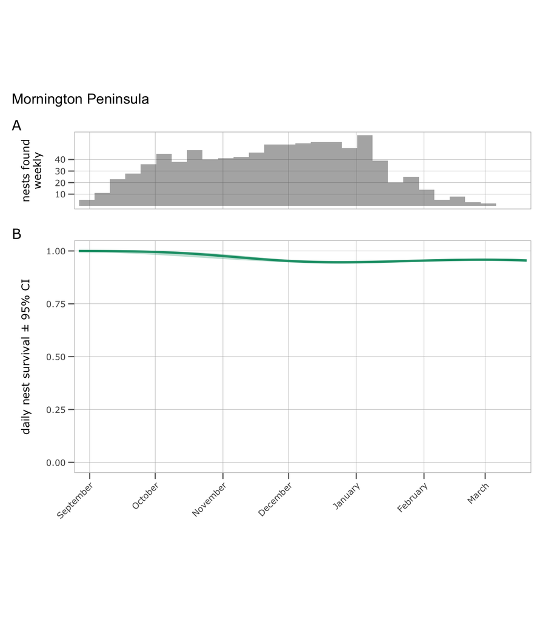

```r
hooded_plover_nest_plot_MP
```

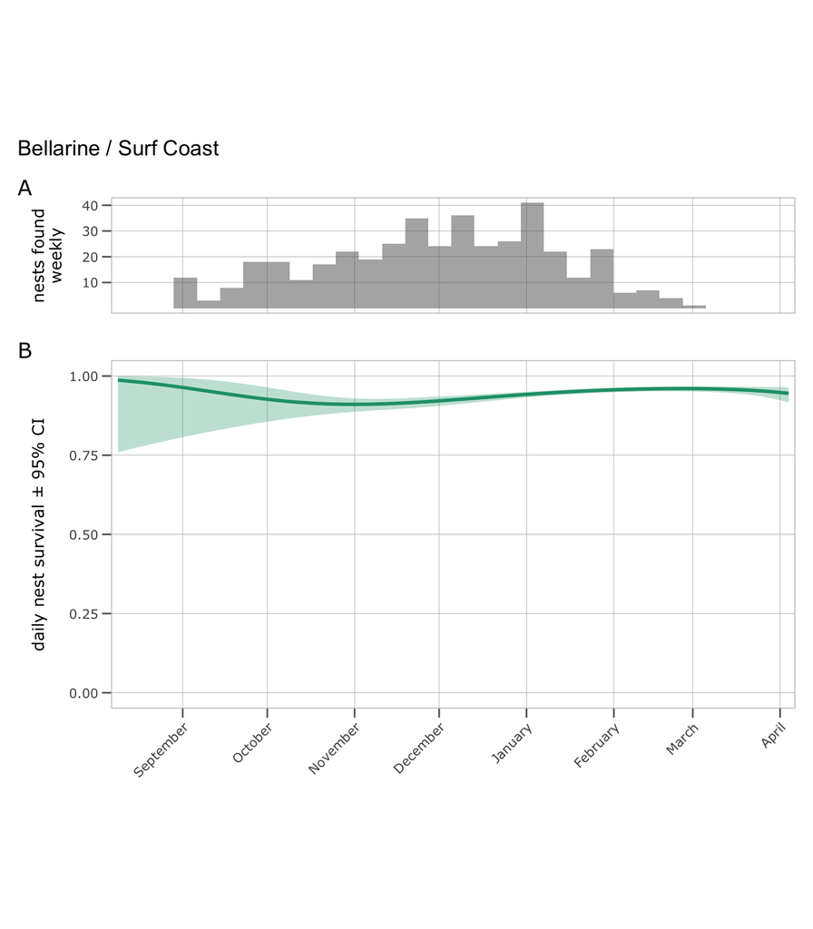

```r
hooded_plover_nest_plot_BSC
```

## Explore correlations between “Fun days” and the threats

We can see in our model selection of nest survival all three sites that our variable “fun days” (a measure of the number of weekends or holidays a nest is exposed to) was the best at explaining variation in daily nest survival. To interpret this effect, it essentially means that if a nest is initiated on, for example, a Friday right before a long period of consecutive holidays, this nest is expected to have extremely low survival compared to a nest initiated on, for example, a Monday at the early or late part of the season when there are no holidays.

Despite “fun days” having such a strong relationship to daily nest survival, our threat variables (e.g., maximum number of dogs off leash counted, maximum number of humans counted, etc.) all showed little relationship with daily nest survival, which we interpret as a methodological effect: the surveys conducted to quantify specific threats were too infrequent to capture a meaningful measure of the pressure that these threats have on nest survival. To link “Fun days” to the threats, we here do an exploratory relationship between fundays and the threats.

```r
library(lme4)
library(gtsummary)
library(ggeffects)
library(effects)

threat_data__scaled_FP <-
  threat_data__ %>%
  mutate(no_fun = ifelse(funday == 0, 1, 0),
                 fun = ifelse(funday == 1, 1, 0)) %>%
          filter(region == "FP") %>%
  mutate(humans_s = scale(humans_),
         dogs_s = scale(dogs_),
         pred_birds_s = scale(pred_birds_),
         gull_s = scale(gulls_),
         dogs_off_s = scale(dogs_off_),
         obs_date2_s = scale(obs_date2))

threat_data__scaled_MP <-
  threat_data__ %>%
  mutate(no_fun = ifelse(funday == 0, 1, 0),
                 fun = ifelse(funday == 1, 1, 0)) %>%
          filter(region == "MP") %>%
  mutate(humans_s = scale(humans_),
         dogs_s = scale(dogs_),
         pred_birds_s = scale(pred_birds_),
         gull_s = scale(gulls_),
         dogs_off_s = scale(dogs_off_),
         obs_date2_s = scale(obs_date2))

threat_data__scaled_BSC <-
  threat_data__ %>%
  mutate(no_fun = ifelse(funday == 0, 1, 0),
                 fun = ifelse(funday == 1, 1, 0)) %>%
          filter(region == "BSC") %>%
  mutate(humans_s = scale(humans_),
         dogs_s = scale(dogs_),
         pred_birds_s = scale(pred_birds_),
         gull_s = scale(gulls_),
         dogs_off_s = scale(dogs_off_),
         obs_date2_s = scale(obs_date2))
```

### Humans and fun days relationships at the three regions

strong relationship between the number of humans detected and the occurrence of a weekend or a holiday at all 3 regions

```r
humans_fun_day_FP_ <-
  glmer(humans_ ~
          poly(obs_date2, 3) +
          funday + (1 | season) + (1 | site),
        data = threat_data__scaled_FP,
        family = "poisson")

humans_fun_day_MP_ <-
  glmer(humans_ ~
          poly(obs_date2, 3) +
          funday + (1 | season) + (1 | site),
        data = threat_data__scaled_MP,
        family = "poisson")

humans_fun_day_BSC_ <-
  glmer(humans_ ~
          poly(obs_date2, 3) +
          funday + (1 | season) + (1 | site),
        data = threat_data__scaled_BSC,
        family = "poisson")
```

Fleurieu Peninsula

```r
tbl_regression(humans_fun_day_FP_, intercept = TRUE,
               label = list(obs_date2 ~ "Date", funday ~ "Weekends & Holidays"))
```

| **Characteristic** | **log(IRR)** | **95% CI** | **p-value** |
| --- | --- | --- | --- |
| (Intercept) | 0.86 | 0.53, 1.2 | <0.001 |
| Date |  |  |  |
| poly(obs_date2, 3)1 | 12 | 11, 13 | <0.001 |
| poly(obs_date2, 3)2 | -16 | -17, -15 | <0.001 |
| poly(obs_date2, 3)3 | -15 | -16, -14 | <0.001 |
| Weekends & Holidays | 0.56 | 0.55, 0.57 | <0.001 |

Abbreviations: CI = Confidence Interval, IRR = Incidence Rate Ratio

Mornington Peninsula

```r
tbl_regression(humans_fun_day_MP_, intercept = TRUE,
               label = list(obs_date2 ~ "Date", funday ~ "Weekends & Holidays"))
```

| **Characteristic** | **log(IRR)** | **95% CI** | **p-value** |
| --- | --- | --- | --- |
| (Intercept) | 0.28 | -0.08, 0.64 | 0.12 |
| Date |  |  |  |
| poly(obs_date2, 3)1 | 15 | 13, 16 | <0.001 |
| poly(obs_date2, 3)2 | -24 | -26, -23 | <0.001 |
| poly(obs_date2, 3)3 | -5.3 | -6.8, -3.8 | <0.001 |
| Weekends & Holidays | 0.72 | 0.70, 0.73 | <0.001 |

Abbreviations: CI = Confidence Interval, IRR = Incidence Rate Ratio

Bellarine / Surf Coast

```r
tbl_regression(humans_fun_day_BSC_, intercept = TRUE,
               label = list(obs_date2 ~ "Date", funday ~ "Weekends & Holidays"))
```

| **Characteristic** | **log(IRR)** | **95% CI** | **p-value** |
| --- | --- | --- | --- |
| (Intercept) | 0.74 | 0.43, 1.1 | <0.001 |
| Date |  |  |  |
| poly(obs_date2, 3)1 | 15 | 14, 16 | <0.001 |
| poly(obs_date2, 3)2 | -4.9 | -6.2, -3.6 | <0.001 |
| poly(obs_date2, 3)3 | -13 | -15, -12 | <0.001 |
| Weekends & Holidays | 0.77 | 0.75, 0.80 | <0.001 |

Abbreviations: CI = Confidence Interval, IRR = Incidence Rate Ratio

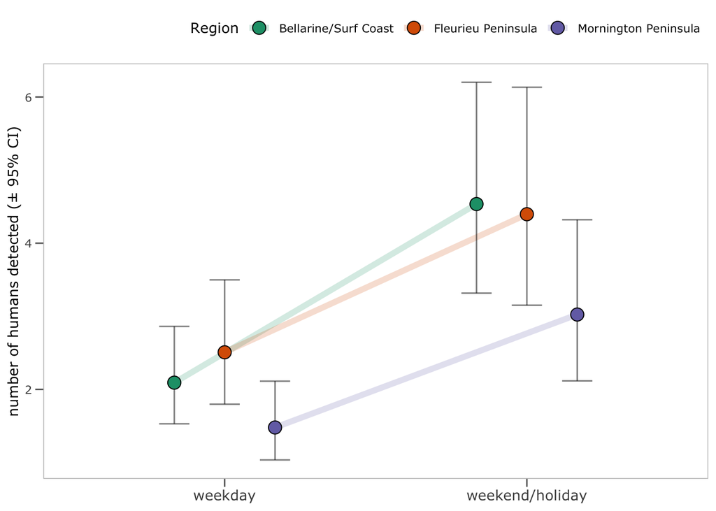

```r
humans_fun_day_FP__fits <-
  as.data.frame(effect(term = "funday", mod = humans_fun_day_FP_,
                       xlevels = list(funday = seq(min(threat_data__scaled_FP[, "funday"], na.rm = TRUE), max(threat_data__scaled_FP[, "funday"], na.rm = TRUE), 1)))) %>%
  mutate(region = "FP")

humans_fun_day_MP__fits <-
  as.data.frame(effect(term = "funday", mod = humans_fun_day_MP_,
                       xlevels = list(funday = seq(min(threat_data__scaled_MP[, "funday"], na.rm = TRUE), max(threat_data__scaled_MP[, "funday"], na.rm = TRUE), 1)))) %>%
  mutate(region = "MP")

humans_fun_day_BSC__fits <-
  as.data.frame(effect(term = "funday", mod = humans_fun_day_BSC_,
                       xlevels = list(funday = seq(min(threat_data__scaled_BSC[, "funday"], na.rm = TRUE), max(threat_data__scaled_BSC[, "funday"], na.rm = TRUE), 1)))) %>%
  mutate(region = "BSC")

humans_fun_day__fits <-
  bind_rows(humans_fun_day_FP__fits,
            humans_fun_day_MP__fits,
            humans_fun_day_BSC__fits) %>%
  mutate(funday = ifelse(funday == 0, "no", "yes"))

row.names(humans_fun_day__fits) <- NULL

ggplot() +
  geom_line(data = humans_fun_day__fits,
            aes(x = funday, y = fit, color = region, group = region),
            position = position_dodge(width = 0.5), alpha = 0.2, size = 2) +
  geom_errorbar(data = humans_fun_day__fits,
                aes(ymin = lower, ymax = upper,
                    x = funday,
                    y = fit, group = region), position = position_dodge(width = 0.5),
                alpha = 0.5, color = "black", width = 0.3, lwd = 0.5) +
  geom_point(data = humans_fun_day__fits,
             aes(x = funday, y = fit, fill = region),
             shape = 21, size = 4, position = position_dodge(width = 0.5)) +
  luke_theme +
  theme(legend.position = "top",
        legend.justification = c(1, 0),
        strip.background = element_blank(),
        axis.title.x = element_blank(),
        axis.text.x = element_text(size = 10)) +
  ylab("number of humans detected (± 95% CI)") +
  scale_colour_brewer(palette = "Dark2",
                      name = "Region",
                      labels = c("Bellarine/Surf Coast",
                                 "Fleurieu Peninsula",
                                 "Mornington Peninsula")) +
  scale_fill_brewer(palette = "Dark2",
                      name = "Region",
                      labels = c("Bellarine/Surf Coast",
                                 "Fleurieu Peninsula",
                                 "Mornington Peninsula")) +
  scale_x_discrete(labels = c("weekday", "weekend/holiday"))
```

### Dogs and fun days relationships at the three regions

strong relationship between the number of dogs detected and the occurrence of a weekend or a holiday at all 3 regions

```r
dogs_fun_day_FP_ <-
  glmer(dogs_ ~
          poly(obs_date2, 3) +
          funday + (1 | season) + (1 | site),
        data = threat_data__scaled_FP,
        family = "poisson")

dogs_fun_day_MP_ <-
  glmer(dogs_ ~
          poly(obs_date2, 3) +
          funday + (1 | season) + (1 | site),
        data = threat_data__scaled_MP,
        family = "poisson")

dogs_fun_day_BSC_ <-
  glmer(dogs_ ~
          poly(obs_date2, 3) +
          funday + (1 | season) + (1 | site),
        data = threat_data__scaled_BSC,
        family = "poisson")
```

Fleurieu Peninsula

```r
tbl_regression(dogs_fun_day_FP_, intercept = TRUE,
               label = list(obs_date2 ~ "Date", funday ~ "Weekends & Holidays"))
```

| **Characteristic** | **log(IRR)** | **95% CI** | **p-value** |
| --- | --- | --- | --- |
| (Intercept) | -0.68 | -1.2, -0.20 | 0.006 |
| Date |  |  |  |
| poly(obs_date2, 3)1 | 4.8 | 3.3, 6.2 | <0.001 |
| poly(obs_date2, 3)2 | -9.7 | -11, -8.1 | <0.001 |
| poly(obs_date2, 3)3 | -10 | -12, -8.9 | <0.001 |
| Weekends & Holidays | 0.29 | 0.27, 0.31 | <0.001 |

Abbreviations: CI = Confidence Interval, IRR = Incidence Rate Ratio

Mornington Peninsula

```r
tbl_regression(dogs_fun_day_MP_, intercept = TRUE,
               label = list(obs_date2 ~ "Date", funday ~ "Weekends & Holidays"))
```

| **Characteristic** | **log(IRR)** | **95% CI** | **p-value** |
| --- | --- | --- | --- |
| (Intercept) | -2.8 | -3.4, -2.3 | <0.001 |
| Date |  |  |  |
| poly(obs_date2, 3)1 | -7.4 | -13, -1.4 | 0.016 |
| poly(obs_date2, 3)2 | -5.1 | -11, 1.3 | 0.12 |
| poly(obs_date2, 3)3 | -3.8 | -9.7, 2.2 | 0.2 |
| Weekends & Holidays | 0.55 | 0.47, 0.63 | <0.001 |

Abbreviations: CI = Confidence Interval, IRR = Incidence Rate Ratio

Bellarine / Surf Coast

```r
tbl_regression(dogs_fun_day_BSC_, intercept = TRUE,
               label = list(obs_date2 ~ "Date", funday ~ "Weekends & Holidays"))
```

| **Characteristic** | **log(IRR)** | **95% CI** | **p-value** |
| --- | --- | --- | --- |
| (Intercept) | -0.17 | -0.50, 0.16 | 0.3 |
| Date |  |  |  |
| poly(obs_date2, 3)1 | 4.0 | 1.9, 6.0 | <0.001 |
| poly(obs_date2, 3)2 | 4.9 | 2.8, 7.1 | <0.001 |
| poly(obs_date2, 3)3 | -5.6 | -7.7, -3.5 | <0.001 |
| Weekends & Holidays | 0.56 | 0.51, 0.61 | <0.001 |

Abbreviations: CI = Confidence Interval, IRR = Incidence Rate Ratio

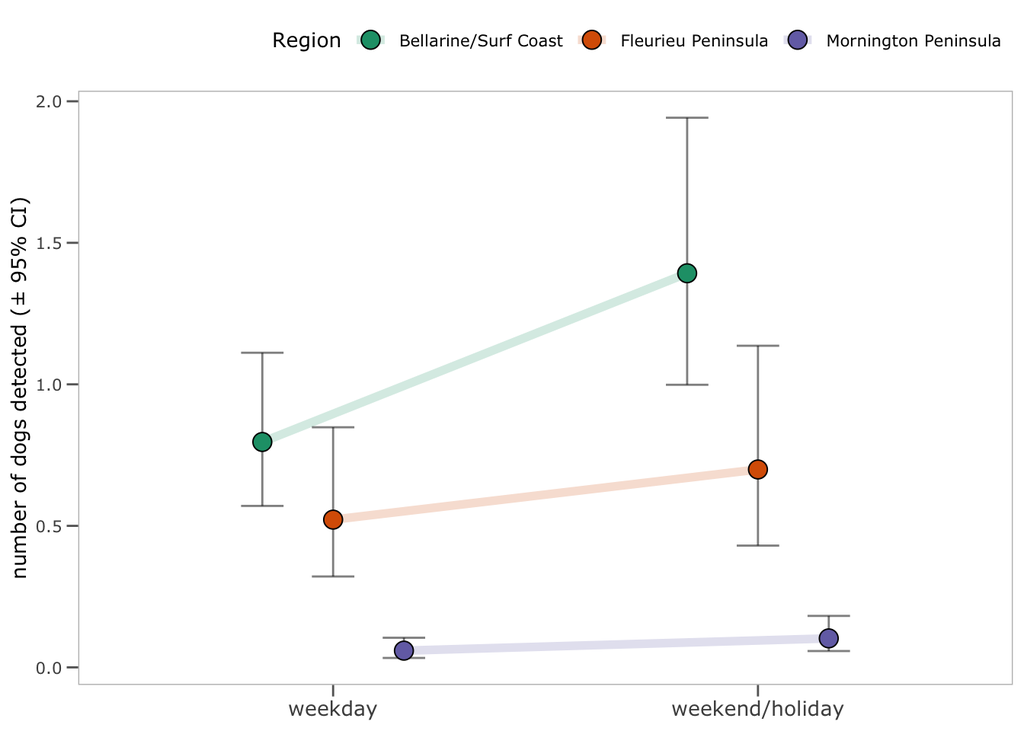

```r
dogs_fun_day_FP__fits <-
  as.data.frame(effect(term = "funday", mod = dogs_fun_day_FP_,
                       xlevels = list(funday = seq(min(threat_data__scaled_FP[, "funday"], na.rm = TRUE), max(threat_data__scaled_FP[, "funday"], na.rm = TRUE), 1)))) %>%
  mutate(region = "FP")

dogs_fun_day_MP__fits <-
  as.data.frame(effect(term = "funday", mod = dogs_fun_day_MP_,
                       xlevels = list(funday = seq(min(threat_data__scaled_MP[, "funday"], na.rm = TRUE), max(threat_data__scaled_MP[, "funday"], na.rm = TRUE), 1)))) %>%
  mutate(region = "MP")

dogs_fun_day_BSC__fits <-
  as.data.frame(effect(term = "funday", mod = dogs_fun_day_BSC_,
                       xlevels = list(funday = seq(min(threat_data__scaled_BSC[, "funday"], na.rm = TRUE), max(threat_data__scaled_BSC[, "funday"], na.rm = TRUE), 1)))) %>%
  mutate(region = "BSC")

dogs_fun_day__fits <-
  bind_rows(dogs_fun_day_FP__fits,
            dogs_fun_day_MP__fits,
            dogs_fun_day_BSC__fits) %>%
  mutate(funday = ifelse(funday == 0, "no", "yes"))

row.names(dogs_fun_day__fits) <- NULL

ggplot() +
  geom_line(data = dogs_fun_day__fits,
            aes(x = funday, y = fit, color = region, group = region),
            position = position_dodge(width = 0.5), alpha = 0.2, size = 2) +
  geom_errorbar(data = dogs_fun_day__fits,
                aes(ymin = lower, ymax = upper,
                    x = funday,
                    y = fit, group = region), position = position_dodge(width = 0.5),
                alpha = 0.5, color = "black", width = 0.3, lwd = 0.5) +
  geom_point(data = dogs_fun_day__fits,
             aes(x = funday, y = fit, fill = region),
             shape = 21, size = 4, position = position_dodge(width = 0.5)) +
  luke_theme +
  theme(legend.position = "top",
        legend.justification = c(1, 0),
        strip.background = element_blank(),
        axis.title.x = element_blank(),
        axis.text.x = element_text(size = 10)) +
  ylab("number of dogs detected (± 95% CI)") +
  scale_colour_brewer(palette = "Dark2",
                      name = "Region",
                      labels = c("Bellarine/Surf Coast", "Fleurieu Peninsula", "Mornington Peninsula")) +
  scale_fill_brewer(palette = "Dark2",
                    name = "Region",
                    labels = c("Bellarine/Surf Coast", "Fleurieu Peninsula", "Mornington Peninsula")) +
  scale_x_discrete(labels = c("weekday", "weekend/holiday"))
```

### Dogs off leashes and fun days relationships at the three regions

strong relationship between the number of dogs off leash detected and the occurrence of a weekend or a holiday at all 3 regions

```r
dogs_off_fun_day_FP_ <-
  glmer(dogs_off_ ~
          poly(obs_date2, 3) +
          funday + (1 | season) + (1 | site),
        data = threat_data__scaled_FP,
        family = "poisson")

dogs_off_fun_day_MP_ <-
  glmer(dogs_off_ ~
          poly(obs_date2, 3) +
          funday + (1 | season) + (1 | site),
        data = threat_data__scaled_MP,
        family = "poisson")

dogs_off_fun_day_BSC_ <-
  glmer(dogs_off_ ~
          poly(obs_date2, 3) +
          funday + (1 | season) + (1 | site),
        data = threat_data__scaled_BSC,
        family = "poisson")
```

Fleurieu Peninsula

```r
tbl_regression(dogs_off_fun_day_FP_, intercept = TRUE,
               label = list(obs_date2 ~ "Date", funday ~ "Weekends & Holidays"))
```

| **Characteristic** | **log(IRR)** | **95% CI** | **p-value** |
| --- | --- | --- | --- |
| (Intercept) | -1.1 | -1.5, -0.60 | <0.001 |
| Date |  |  |  |
| poly(obs_date2, 3)1 | 4.4 | 2.5, 6.2 | <0.001 |
| poly(obs_date2, 3)2 | 9.0 | 7.1, 11 | <0.001 |
| poly(obs_date2, 3)3 | -9.6 | -11, -7.8 | <0.001 |
| Weekends & Holidays | 0.22 | 0.19, 0.24 | <0.001 |

Abbreviations: CI = Confidence Interval, IRR = Incidence Rate Ratio

Mornington Peninsula

```r
tbl_regression(dogs_off_fun_day_MP_, intercept = TRUE,
               label = list(obs_date2 ~ "Date", funday ~ "Weekends & Holidays"))
```

| **Characteristic** | **log(IRR)** | **95% CI** | **p-value** |
| --- | --- | --- | --- |
| (Intercept) | -3.2 | -3.9, -2.6 | <0.001 |
| Date |  |  |  |
| poly(obs_date2, 3)1 | -7.4 | -14, -0.50 | 0.036 |
| poly(obs_date2, 3)2 | 3.2 | -3.4, 9.9 | 0.3 |
| poly(obs_date2, 3)3 | 2.8 | -3.9, 9.5 | 0.4 |
| Weekends & Holidays | 0.49 | 0.39, 0.58 | <0.001 |

Abbreviations: CI = Confidence Interval, IRR = Incidence Rate Ratio

Bellarine / Surf Coast

```r
tbl_regression(dogs_off_fun_day_BSC_, intercept = TRUE,
               label = list(obs_date2 ~ "Date", funday ~ "Weekends & Holidays"))
```

| **Characteristic** | **log(IRR)** | **95% CI** | **p-value** |
| --- | --- | --- | --- |
| (Intercept) | -0.52 | -0.85, -0.19 | 0.002 |
| Date |  |  |  |
| poly(obs_date2, 3)1 | -2.8 | -5.3, -0.26 | 0.031 |
| poly(obs_date2, 3)2 | 8.2 | 5.7, 11 | <0.001 |
| poly(obs_date2, 3)3 | -0.70 | -3.1, 1.7 | 0.6 |
| Weekends & Holidays | 0.44 | 0.38, 0.50 | <0.001 |

Abbreviations: CI = Confidence Interval, IRR = Incidence Rate Ratio

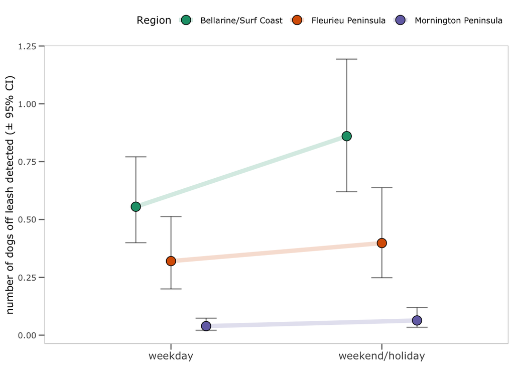

```r
dogs_off_fun_day_FP__fits <-
  as.data.frame(effect(term = "funday", mod = dogs_off_fun_day_FP_,
                       xlevels = list(funday = seq(min(threat_data__scaled_FP[, "funday"], na.rm = TRUE), max(threat_data__scaled_FP[, "funday"], na.rm = TRUE), 1)))) %>%
  mutate(region = "FP")

dogs_off_fun_day_MP__fits <-
  as.data.frame(effect(term = "funday", mod = dogs_off_fun_day_MP_,
                       xlevels = list(funday = seq(min(threat_data__scaled_MP[, "funday"], na.rm = TRUE), max(threat_data__scaled_MP[, "funday"], na.rm = TRUE), 1)))) %>%
  mutate(region = "MP")

dogs_off_fun_day_BSC__fits <-
  as.data.frame(effect(term = "funday", mod = dogs_off_fun_day_BSC_,
                       xlevels = list(funday = seq(min(threat_data__scaled_BSC[, "funday"], na.rm = TRUE), max(threat_data__scaled_BSC[, "funday"], na.rm = TRUE), 1)))) %>%
  mutate(region = "BSC")

dogs_off_fun_day__fits <-
  bind_rows(dogs_off_fun_day_FP__fits,
            dogs_off_fun_day_MP__fits,
            dogs_off_fun_day_BSC__fits) %>%
  mutate(funday = ifelse(funday == 0, "no", "yes"))

row.names(dogs_off_fun_day__fits) <- NULL

ggplot() +
  geom_line(data = dogs_off_fun_day__fits,
            aes(x = funday, y = fit, color = region, group = region),
            position = position_dodge(width = 0.5), alpha = 0.2, size = 2) +
  geom_errorbar(data = dogs_off_fun_day__fits,
                aes(ymin = lower, ymax = upper,
                    x = funday,
                    y = fit, group = region), position = position_dodge(width = 0.5),
                alpha = 0.5, color = "black", width = 0.3, lwd = 0.5) +
  geom_point(data = dogs_off_fun_day__fits,
             aes(x = funday, y = fit, fill = region),
             shape = 21, size = 4, position = position_dodge(width = 0.5)) +
  luke_theme +
  theme(legend.position = "top",
        legend.justification = c(1, 0),
        strip.background = element_blank(),
        axis.title.x = element_blank(),
        axis.text.x = element_text(size = 10)) +
  ylab("number of dogs off leash detected (± 95% CI)") +
  scale_colour_brewer(palette = "Dark2",
                      name = "Region",
                      labels = c("Bellarine/Surf Coast", "Fleurieu Peninsula", "Mornington Peninsula")) +
  scale_fill_brewer(palette = "Dark2",
                    name = "Region",
                    labels = c("Bellarine/Surf Coast", "Fleurieu Peninsula", "Mornington Peninsula")) +
  scale_x_discrete(labels = c("weekday", "weekend/holiday"))
```

### Ravens and Magpies and fun days relationships at the three regions

```r
pred_birds_fun_day_FP_ <-
  glmer(pred_birds_ ~
          poly(obs_date2, 3) +
          funday + (1 | season) + (1 | site),
        data = threat_data__scaled_FP,
        family = "poisson")

pred_birds_fun_day_MP_ <-
  glmer(pred_birds_ ~
          poly(obs_date2, 3) +
          funday + (1 | season) + (1 | site),
        data = threat_data__scaled_MP,
        family = "poisson")

pred_birds_fun_day_BSC_ <-
  glmer(pred_birds_ ~
          poly(obs_date2, 3) +
          funday + (1 | season) + (1 | site),
        data = threat_data__scaled_BSC,
        family = "poisson")
```

Fleurieu Peninsula

```r
tbl_regression(pred_birds_fun_day_FP_, intercept = TRUE,
               label = list(obs_date2 ~ "Date", funday ~ "Weekends & Holidays"))
```

| **Characteristic** | **log(IRR)** | **95% CI** | **p-value** |
| --- | --- | --- | --- |
| (Intercept) | -1.2 | -1.5, -0.89 | <0.001 |
| Date |  |  |  |
| poly(obs_date2, 3)1 | -4.3 | -7.9, -0.74 | 0.018 |
| poly(obs_date2, 3)2 | -28 | -32, -25 | <0.001 |
| poly(obs_date2, 3)3 | 6.9 | 2.8, 11 | <0.001 |
| Weekends & Holidays | -0.12 | -0.16, -0.08 | <0.001 |

Abbreviations: CI = Confidence Interval, IRR = Incidence Rate Ratio

Mornington Peninsula

```r
tbl_regression(pred_birds_fun_day_MP_, intercept = TRUE,
               label = list(obs_date2 ~ "Date", funday ~ "Weekends & Holidays"))
```

| **Characteristic** | **log(IRR)** | **95% CI** | **p-value** |
| --- | --- | --- | --- |
| (Intercept) | -1.9 | -2.2, -1.5 | <0.001 |
| Date |  |  |  |
| poly(obs_date2, 3)1 | 27 | 22, 32 | <0.001 |
| poly(obs_date2, 3)2 | -53 | -58, -47 | <0.001 |
| poly(obs_date2, 3)3 | 19 | 13, 24 | <0.001 |
| Weekends & Holidays | -0.25 | -0.30, -0.19 | <0.001 |

Abbreviations: CI = Confidence Interval, IRR = Incidence Rate Ratio

Bellarine / Surf Coast

```r
tbl_regression(pred_birds_fun_day_BSC_, intercept = TRUE,
               label = list(obs_date2 ~ "Date", funday ~ "Weekends & Holidays"))
```

| **Characteristic** | **log(IRR)** | **95% CI** | **p-value** |
| --- | --- | --- | --- |
| (Intercept) | -1.4 | -1.7, -1.1 | <0.001 |
| Date |  |  |  |
| poly(obs_date2, 3)1 | 0.14 | -4.7, 5.0 | >0.9 |
| poly(obs_date2, 3)2 | -40 | -46, -35 | <0.001 |
| poly(obs_date2, 3)3 | 7.2 | 1.4, 13 | 0.016 |
| Weekends & Holidays | -0.08 | -0.16, -0.01 | 0.024 |

Abbreviations: CI = Confidence Interval, IRR = Incidence Rate Ratio

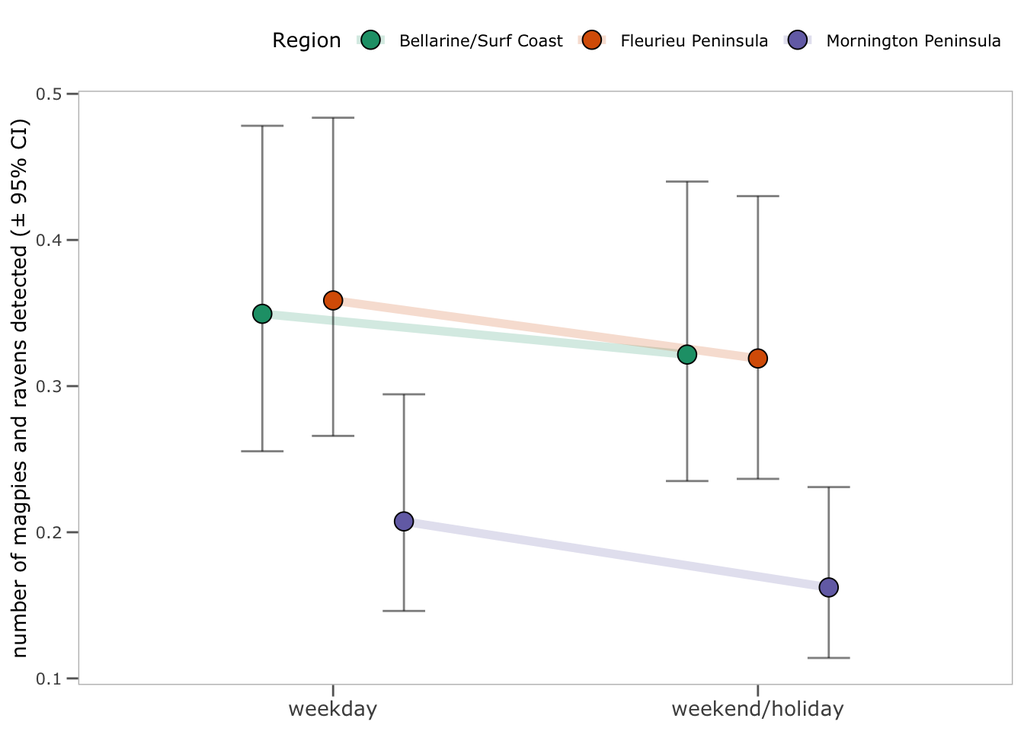

```r
pred_birds_fun_day_FP__fits <-
  as.data.frame(effect(term = "funday", mod = pred_birds_fun_day_FP_,
                       xlevels = list(funday = seq(min(threat_data__scaled_FP[, "funday"], na.rm = TRUE), max(threat_data__scaled_FP[, "funday"], na.rm = TRUE), 1)))) %>%
  mutate(region = "FP")

pred_birds_fun_day_MP__fits <-
  as.data.frame(effect(term = "funday", mod = pred_birds_fun_day_MP_,
                       xlevels = list(funday = seq(min(threat_data__scaled_MP[, "funday"], na.rm = TRUE), max(threat_data__scaled_MP[, "funday"], na.rm = TRUE), 1)))) %>%
  mutate(region = "MP")

pred_birds_fun_day_BSC__fits <-
  as.data.frame(effect(term = "funday", mod = pred_birds_fun_day_BSC_,
                       xlevels = list(funday = seq(min(threat_data__scaled_BSC[, "funday"], na.rm = TRUE), max(threat_data__scaled_BSC[, "funday"], na.rm = TRUE), 1)))) %>%
  mutate(region = "BSC")

pred_birds_fun_day__fits <-
  bind_rows(pred_birds_fun_day_FP__fits,
            pred_birds_fun_day_MP__fits,
            pred_birds_fun_day_BSC__fits) %>%
  mutate(funday = ifelse(funday == 0, "no", "yes"))

row.names(pred_birds_fun_day__fits) <- NULL

ggplot() +
  geom_line(data = pred_birds_fun_day__fits,
            aes(x = funday, y = fit, color = region, group = region),
            position = position_dodge(width = 0.5), alpha = 0.2, size = 2) +
  geom_errorbar(data = pred_birds_fun_day__fits,
                aes(ymin = lower, ymax = upper,
                    x = funday,
                    y = fit, group = region), position = position_dodge(width = 0.5),
                alpha = 0.5, color = "black", width = 0.3, lwd = 0.5) +
  geom_point(data = pred_birds_fun_day__fits,
             aes(x = funday, y = fit, fill = region),
             shape = 21, size = 4, position = position_dodge(width = 0.5)) +
  luke_theme +
  theme(legend.position = "top",
        legend.justification = c(1, 0),
        strip.background = element_blank(),
        axis.title.x = element_blank(),
        axis.text.x = element_text(size = 10)) +
  ylab("number of magpies and ravens detected (± 95% CI)") +
  scale_colour_brewer(palette = "Dark2",
                      name = "Region",
                      labels = c("Bellarine/Surf Coast", "Fleurieu Peninsula", "Mornington Peninsula")) +
  scale_fill_brewer(palette = "Dark2",
                    name = "Region",
                    labels = c("Bellarine/Surf Coast", "Fleurieu Peninsula", "Mornington Peninsula")) +
  scale_x_discrete(labels = c("weekday", "weekend/holiday"))
```

### Gulls and fun days relationships at the three regions

```r
gulls_fun_day_FP_ <-
  glmer(gulls_ ~
          poly(obs_date2, 3) +
          funday + (1 | season) + (1 | site),
        data = threat_data__scaled_FP,
        family = "poisson")

gulls_fun_day_MP_ <-
  glmer(gulls_ ~
          poly(obs_date2, 3) +
          funday + (1 | season) + (1 | site),
        data = threat_data__scaled_MP,
        family = "poisson")

gulls_fun_day_BSC_ <-
  glmer(gulls_ ~
          poly(obs_date2, 3) +
          funday + (1 | season) + (1 | site),
        data = threat_data__scaled_BSC,
        family = "poisson")
```

Fleurieu Peninsula

```r
tbl_regression(gulls_fun_day_FP_, intercept = TRUE,
               label = list(obs_date2 ~ "Date", funday ~ "Weekends & Holidays"))
```

| **Characteristic** | **log(IRR)** | **95% CI** | **p-value** |
| --- | --- | --- | --- |
| (Intercept) | -1.0 | -1.4, -0.70 | <0.001 |
| Date |  |  |  |
| poly(obs_date2, 3)1 | 4.6 | 1.5, 7.7 | 0.004 |
| poly(obs_date2, 3)2 | -32 | -36, -29 | <0.001 |
| poly(obs_date2, 3)3 | 3.0 | -0.19, 6.2 | 0.065 |
| Weekends & Holidays | -0.10 | -0.13, -0.06 | <0.001 |

Abbreviations: CI = Confidence Interval, IRR = Incidence Rate Ratio

Mornington Peninsula

```r
tbl_regression(gulls_fun_day_MP_, intercept = TRUE,
               label = list(obs_date2 ~ "Date", funday ~ "Weekends & Holidays"))
```

| **Characteristic** | **log(IRR)** | **95% CI** | **p-value** |
| --- | --- | --- | --- |
| (Intercept) | -1.7 | -2.1, -1.3 | <0.001 |
| Date |  |  |  |
| poly(obs_date2, 3)1 | 33 | 28, 39 | <0.001 |
| poly(obs_date2, 3)2 | -62 | -67, -57 | <0.001 |
| poly(obs_date2, 3)3 | 19 | 14, 25 | <0.001 |
| Weekends & Holidays | -0.23 | -0.28, -0.18 | <0.001 |

Abbreviations: CI = Confidence Interval, IRR = Incidence Rate Ratio

Bellarine / Surf Coast

```r
tbl_regression(gulls_fun_day_BSC_, intercept = TRUE,
               label = list(obs_date2 ~ "Date", funday ~ "Weekends & Holidays"))
```

| **Characteristic** | **log(IRR)** | **95% CI** | **p-value** |
| --- | --- | --- | --- |
| (Intercept) | -1.1 | -1.5, -0.73 | <0.001 |
| Date |  |  |  |
| poly(obs_date2, 3)1 | 3.4 | -0.67, 7.5 | 0.10 |
| poly(obs_date2, 3)2 | -47 | -52, -42 | <0.001 |
| poly(obs_date2, 3)3 | -4.5 | -9.7, 0.63 | 0.085 |
| Weekends & Holidays | -0.10 | -0.16, -0.05 | <0.001 |

Abbreviations: CI = Confidence Interval, IRR = Incidence Rate Ratio

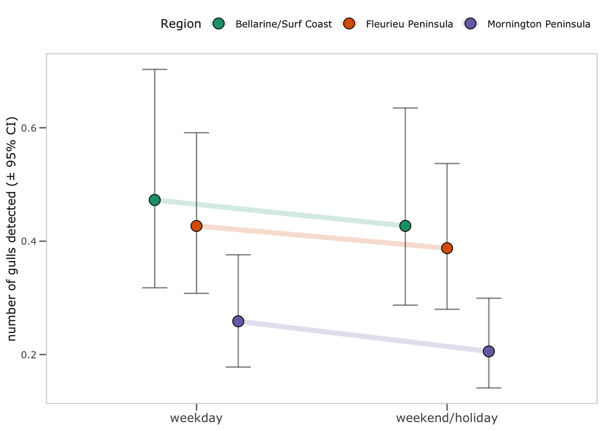

```r
gulls_fun_day_FP__fits <-
  as.data.frame(effect(term = "funday", mod = gulls_fun_day_FP_,
                       xlevels = list(funday = seq(min(threat_data__scaled_FP[, "funday"], na.rm = TRUE), max(threat_data__scaled_FP[, "funday"], na.rm = TRUE), 1)))) %>%
  mutate(region = "FP")

gulls_fun_day_MP__fits <-
  as.data.frame(effect(term = "funday", mod = gulls_fun_day_MP_,
                       xlevels = list(funday = seq(min(threat_data__scaled_MP[, "funday"], na.rm = TRUE), max(threat_data__scaled_MP[, "funday"], na.rm = TRUE), 1)))) %>%
  mutate(region = "MP")

gulls_fun_day_BSC__fits <-
  as.data.frame(effect(term = "funday", mod = gulls_fun_day_BSC_,
                       xlevels = list(funday = seq(min(threat_data__scaled_BSC[, "funday"], na.rm = TRUE), max(threat_data__scaled_BSC[, "funday"], na.rm = TRUE), 1)))) %>%
  mutate(region = "BSC")

gulls_fun_day__fits <-
  bind_rows(gulls_fun_day_FP__fits,
            gulls_fun_day_MP__fits,
            gulls_fun_day_BSC__fits) %>%
  mutate(funday = ifelse(funday == 0, "no", "yes"))

row.names(gulls_fun_day__fits) <- NULL

ggplot() +
  geom_line(data = gulls_fun_day__fits,
            aes(x = funday, y = fit, color = region, group = region),
            position = position_dodge(width = 0.5), alpha = 0.2, size = 2) +
  geom_errorbar(data = gulls_fun_day__fits,
                aes(ymin = lower, ymax = upper,
                    x = funday,
                    y = fit, group = region), position = position_dodge(width = 0.5),
                alpha = 0.5, color = "black", width = 0.3, lwd = 0.5) +
  geom_point(data = gulls_fun_day__fits,
             aes(x = funday, y = fit, fill = region),
             shape = 21, size = 4, position = position_dodge(width = 0.5)) +
  luke_theme +
  theme(legend.position = "top",
        legend.justification = c(1, 0),
        strip.background = element_blank(),
        axis.title.x = element_blank(),
        axis.text.x = element_text(size = 10)) +
  ylab("number of gulls detected (± 95% CI)") +
  scale_colour_brewer(palette = "Dark2",
                      name = "Region",
                      labels = c("Bellarine/Surf Coast", "Fleurieu Peninsula", "Mornington Peninsula")) +
  scale_fill_brewer(palette = "Dark2",
                    name = "Region",
                    labels = c("Bellarine/Surf Coast", "Fleurieu Peninsula", "Mornington Peninsula")) +
  scale_x_discrete(labels = c("weekday", "weekend/holiday"))
```